# Elsevier 2022 SDG mapping

# General to all SDGs

## Introduction

The United Nations Sustainable Development Goals (SDGs) challenge the global community to build a world where no one is left behind.

Since 2018, Elsevier has generated SDG search queries to help researchers and institutions track and demonstrate progress toward the SDG targets. In the past 3 years, these queries, along with the university’s own data and evidence supporting progress and contributions to the particular SDG outside of research-based metrics, are used for the THE Impact Rankings.

## Method

For 2022, this SDG uses the exact same search query and ML algorithm as the Elsevier 2021 SDG mapping. [Full details of the 2021 methodology are available on Digital Commons Data.](https://elsevier.digitalcommonsdata.com/datasets/9sxdykm8s4/4)

# [SDG 13 - Take urgent action to combat climate change and its impacts](https://sdgs.un.org/goals/goal13)

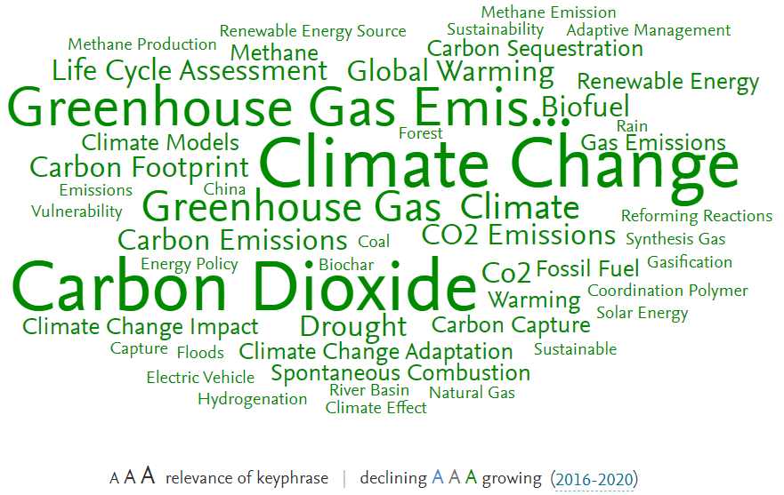

Explore this wordcloud plus the most active contributors on the [SciVal SDG site](https://scival.com/sdg)

## Query

Below is the full search query used for this SDG. We’ve broken it down by each query component. Use the + and – to concatenate the different bracket levels.

(

(

(

(

(TITLE-ABS("green house gas") OR TITLE-ABS("greenhouse gas") OR TITLE-ABS("greenhousegas") OR TITLE-ABS("green gas") OR TITLE-ABS("green house gases") OR TITLE-ABS("greenhouse gases") OR TITLE-ABS("greenhousegases") OR TITLE-ABS("green gases")) AND TITLE-ABS("mitigation")

)

OR

(

(AUTHKEY("green house gas") OR AUTHKEY("greenhouse gas") OR AUTHKEY("greenhousegas") OR AUTHKEY("green gas") OR AUTHKEY("green house gases") OR AUTHKEY("greenhouse gases") OR AUTHKEY("greenhousegases") OR AUTHKEY("green gases")) AND AUTHKEY("mitigation")

)

OR

(

TITLE-ABS("reforestation") AND (TITLE-ABS("mitigation") OR TITLE-ABS("climate change"))

)

OR

(

AUTHKEY("reforestation") AND (AUTHKEY("mitigation") OR AUTHKEY("climate change"))

)

OR

(

TITLE-ABS("carbon mitigation") OR TITLE-ABS("mitigating carbon")

)

OR

(

AUTHKEY("carbon mitigation") OR AUTHKEY("mitigating carbon")

)

OR

(

(TITLE-ABS("green house gas") OR TITLE-ABS("greenhouse gas") OR TITLE-ABS("greenhousegas") OR TITLE-ABS("green gas") OR TITLE-ABS("green house gases") OR TITLE-ABS("greenhouse gases") OR TITLE-ABS("greenhousegases") OR TITLE-ABS("green gases")) AND (TITLE-ABS("emissions") OR TITLE-ABS("emission")) AND TITLE-ABS("mitigation")

)

OR

(

(AUTHKEY("green house gas") OR AUTHKEY("greenhouse gas") OR AUTHKEY("greenhousegas") OR AUTHKEY("green gas") OR AUTHKEY("green house gases") OR AUTHKEY("greenhouse gases") OR AUTHKEY("greenhousegases") OR AUTHKEY("green gases")) AND (AUTHKEY("emissions") OR AUTHKEY("emission")) AND AUTHKEY("mitigation")

)

OR

(

(TITLE-ABS("fossil fuels") OR TITLE-ABS("fossil fuel")) AND (TITLE-ABS("emission") OR TITLE-ABS("emissions"))

)

OR

(

(AUTHKEY("fossil fuels") OR AUTHKEY("fossil fuel")) AND (AUTHKEY("emission") OR AUTHKEY("emissions"))

)

OR

(

TITLE-ABS("methane") AND (TITLE-ABS("emission") OR TITLE-ABS("emissions")) AND TITLE-ABS("pollution")

)

OR

(

AUTHKEY("methane") AND (AUTHKEY("emission") OR AUTHKEY("emissions")) AND AUTHKEY("pollution")

)

OR

(

(TITLE-ABS("green house gases") OR TITLE-ABS("greenhouse gases") OR TITLE-ABS("greenhousegases") OR TITLE-ABS("green gases")) AND TITLE-ABS("climate change")

)

OR

(

(AUTHKEY("green house gases") OR AUTHKEY("greenhouse gases") OR AUTHKEY("greenhousegases") OR AUTHKEY("green gases")) AND AUTHKEY("climate change")

)

OR

(

TITLE-ABS("decrease of green house gas") OR TITLE-ABS("decrease of greenhouse gas") OR TITLE-ABS("decrease of greenhousegas") OR TITLE-ABS("decrease of green gas") OR TITLE-ABS("decrease of green house gases") OR TITLE-ABS("decrease of greenhouse gases") OR TITLE-ABS("decrease of greenhousegases") OR TITLE-ABS("decrease of green gases") OR TITLE-ABS("decrease of GHG") OR TITLE-ABS("decrease of GHGs")

)

OR

(

AUTHKEY("decrease of green house gas") OR AUTHKEY("decrease of greenhouse gas") OR AUTHKEY("decrease of greenhousegas") OR AUTHKEY("decrease of green gas") OR AUTHKEY("decrease of green house gases") OR AUTHKEY("decrease of greenhouse gases") OR AUTHKEY("decrease of greenhousegases") OR AUTHKEY("decrease of green gases") OR AUTHKEY("decrease of GHG") OR AUTHKEY("decrease of GHGs")

)

OR

(

(TITLE-ABS("carbon dioxide") OR TITLE-ABS("CO2") OR TITLE-ABS("CO 2")) AND TITLE-ABS("global warming")

)

OR

(

(AUTHKEY("carbon dioxide") OR AUTHKEY("CO2") OR AUTHKEY("CO 2")) AND AUTHKEY("global warming")

)

OR

(

(TITLE-ABS("carbon dioxide") OR TITLE-ABS("CO2") OR TITLE-ABS("CO 2") OR TITLE-ABS("fossil fuels") OR TITLE-ABS("fossil fuel") OR TITLE-ABS("methane")) AND TITLE-ABS("mitigation")

)

OR

(

(AUTHKEY("carbon dioxide") OR AUTHKEY("CO2") OR AUTHKEY("CO 2") OR AUTHKEY("fossil fuels") OR AUTHKEY("fossil fuel") OR AUTHKEY("methane")) AND AUTHKEY("mitigation")

)

OR

(

TITLE-ABS("green house gas reduction") OR TITLE-ABS("greenhouse gas reduction") OR TITLE-ABS("greenhousegas reduction") OR TITLE-ABS("green gas reduction") OR TITLE-ABS("green house gases reduction") OR TITLE-ABS("greenhouse gases reduction") OR TITLE-ABS("greenhousegases reduction") OR TITLE-ABS("green gases reduction")

)

OR

(

AUTHKEY("green house gas reduction") OR AUTHKEY("greenhouse gas reduction") OR AUTHKEY("greenhousegas reduction") OR AUTHKEY("green gas reduction") OR AUTHKEY("green house gases reduction") OR AUTHKEY("greenhouse gases reduction") OR AUTHKEY("greenhousegases reduction") OR AUTHKEY("green gases reduction")

)

OR

(

(TITLE-ABS("green house gas") OR TITLE-ABS("greenhouse gas") OR TITLE-ABS("greenhousegas") OR TITLE-ABS("green gas") OR TITLE-ABS("green house gases") OR TITLE-ABS("greenhouse gases") OR TITLE-ABS("greenhousegases") OR TITLE-ABS("green gases")) AND (TITLE-ABS("emission") OR TITLE-ABS("emissions"))

)

OR

(

(AUTHKEY("green house gas") OR AUTHKEY("greenhouse gas") OR AUTHKEY("greenhousegas") OR AUTHKEY("green gas") OR AUTHKEY("green house gases") OR AUTHKEY("greenhouse gases") OR AUTHKEY("greenhousegases") OR AUTHKEY("green gases")) AND (AUTHKEY("emission") OR AUTHKEY("emissions"))

)

OR

(

TITLE-ABS("methane") AND (TITLE-ABS("emission") OR TITLE-ABS("emissions")) AND (TITLE-ABS("agriculture") OR TITLE-ABS("agro") OR TITLE-ABS("agricultural"))

)

OR

(

AUTHKEY("methane") AND (AUTHKEY("emission") OR AUTHKEY("emissions")) AND (AUTHKEY("agriculture") OR AUTHKEY("agro") OR AUTHKEY("agricultural"))

)

OR

(

TITLE-ABS("methane") AND (TITLE-ABS("emission") OR TITLE-ABS("emissions")) AND (TITLE-ABS("livestock") OR TITLE-ABS("livestocks"))

)

OR

(

AUTHKEY("methane") AND (AUTHKEY("emission") OR AUTHKEY("emissions")) AND (AUTHKEY("livestock") OR AUTHKEY("livestocks"))

)

OR

(

((TITLE-ABS("chlorofluorocarbons") OR TITLE-ABS("chloro-fluoro-carbons") OR TITLE-ABS("chlorofluoro-carbons") OR TITLE-ABS("chloro-fluorocarbons") OR TITLE-ABS("chlorofluorocarbon") OR TITLE-ABS("chloro-fluoro-carbon") OR TITLE-ABS("chlorofluoro-carbon") OR TITLE-ABS("chloro-fluorocarbon")) AND (TITLE-ABS("climate change") OR TITLE-ABS("global warming") OR TITLE-ABS("environmental impact") OR TITLE-ABS("impact on environment") OR TITLE-ABS("environmental impacts") OR TITLE-ABS("impacts on environment"))) OR ((TITLE-ABS("chlorofluorocarbons") OR TITLE-ABS("chlorofluorocarbons") OR TITLE-ABS("chlorofluorocarbons") OR TITLE-ABS("chlorofluorocarbons") OR TITLE-ABS("chlorofluorocarbon") OR TITLE-ABS("chlorofluorocarbon") OR TITLE-ABS("chlorofluorocarbon") OR TITLE-ABS("chlorofluorocarbon")) AND (TITLE-ABS("climate change") OR TITLE-ABS("global warming") OR TITLE-ABS("environmental impact") OR TITLE-ABS("impact on environment") OR TITLE-ABS("environmental impacts") OR TITLE-ABS("impacts on environment")))

)

OR

(

((AUTHKEY("chlorofluorocarbons") OR AUTHKEY("chloro-fluoro-carbons") OR AUTHKEY("chlorofluoro-carbons") OR AUTHKEY("chloro-fluorocarbons") OR AUTHKEY("chlorofluorocarbon") OR AUTHKEY("chloro-fluoro-carbon") OR AUTHKEY("chlorofluoro-carbon") OR AUTHKEY("chloro-fluorocarbon")) AND (AUTHKEY("climate change") OR AUTHKEY("global warming") OR AUTHKEY("environmental impact") OR AUTHKEY("impact on environment") OR AUTHKEY("environmental impacts") OR AUTHKEY("impacts on environment"))) OR ((AUTHKEY("chlorofluorocarbons") OR AUTHKEY("chlorofluorocarbons") OR AUTHKEY("chlorofluorocarbons") OR AUTHKEY("chlorofluorocarbons") OR AUTHKEY("chlorofluorocarbon") OR AUTHKEY("chlorofluorocarbon") OR AUTHKEY("chlorofluorocarbon") OR AUTHKEY("chlorofluorocarbon")) AND (AUTHKEY("climate change") OR AUTHKEY("global warming") OR AUTHKEY("environmental impact") OR AUTHKEY("impact on environment") OR AUTHKEY("environmental impacts") OR AUTHKEY("impacts on environment")))

)

OR

(

(TITLE-ABS("carbon dioxide") OR TITLE-ABS("CO2") OR TITLE-ABS("CO 2")) AND (TITLE-ABS("emission") OR TITLE-ABS("emissions"))

)

OR

(

(AUTHKEY("carbon dioxide") OR AUTHKEY("CO2") OR AUTHKEY("CO 2")) AND (AUTHKEY("emission") OR AUTHKEY("emissions"))

)

OR

(

(TITLE-ABS("green house gas") OR TITLE-ABS("greenhouse gas") OR TITLE-ABS("greenhousegas") OR TITLE-ABS("green gas") OR TITLE-ABS("green house gases") OR TITLE-ABS("greenhouse gases") OR TITLE-ABS("greenhousegases") OR TITLE-ABS("green gases")) AND TITLE-ABS("global warming")

)

OR

(

(AUTHKEY("green house gas") OR AUTHKEY("greenhouse gas") OR AUTHKEY("greenhousegas") OR AUTHKEY("green gas") OR AUTHKEY("green house gases") OR AUTHKEY("greenhouse gases") OR AUTHKEY("greenhousegases") OR AUTHKEY("green gases")) AND AUTHKEY("global warming")

)

OR

(

TITLE-ABS("reduction of green house gas") OR TITLE-ABS("reduction of greenhouse gas") OR TITLE-ABS("reduction of greenhousegas") OR TITLE-ABS("reduction of green gas") OR TITLE-ABS("reduction of green house gases") OR TITLE-ABS("reduction of greenhouse gases") OR TITLE-ABS("reduction of greenhousegases") OR TITLE-ABS("reduction of green gases") OR TITLE-ABS("reduction of GHG") OR TITLE-ABS("reduction of GHGs")

)

OR

(

AUTHKEY("reduction of green house gas") OR AUTHKEY("reduction of greenhouse gas") OR AUTHKEY("reduction of greenhousegas") OR AUTHKEY("reduction of green gas") OR AUTHKEY("reduction of green house gases") OR AUTHKEY("reduction of greenhouse gases") OR AUTHKEY("reduction of greenhousegases") OR AUTHKEY("reduction of green gases") OR AUTHKEY("reduction of GHG") OR AUTHKEY("reduction of GHGs")

)

OR

(

TITLE-ABS("methane") AND (TITLE-ABS("emission") OR TITLE-ABS("emissions")) AND TITLE-ABS("rice")

)

OR

(

AUTHKEY("methane") AND (AUTHKEY("emission") OR AUTHKEY("emissions")) AND AUTHKEY("rice")

)

OR

(

TITLE-ABS("Urban forestry") AND (TITLE-ABS("climate") OR TITLE-ABS("pollution") OR TITLE-ABS("global warming") OR TITLE-ABS("environmental impact"))

)

OR

(

AUTHKEY("Urban forestry") AND (AUTHKEY("climate") OR AUTHKEY("pollution") OR AUTHKEY("global warming") OR AUTHKEY("environmental impact"))

)

OR

(

(TITLE-ABS("carbon dioxide") OR TITLE-ABS("CO2") OR TITLE-ABS("CO 2")) AND (TITLE-ABS("environmental impact") OR TITLE-ABS("impact on environment") OR TITLE-ABS("environmental impacts") OR TITLE-ABS("impacts on environment"))

)

OR

(

(AUTHKEY("carbon dioxide") OR AUTHKEY("CO2") OR AUTHKEY("CO 2")) AND (AUTHKEY("environmental impact") OR AUTHKEY("impact on environment") OR AUTHKEY("environmental impacts") OR AUTHKEY("impacts on environment"))

)

OR

(

TITLE-ABS("reduce green house gas") OR TITLE-ABS("reduce greenhouse gas") OR TITLE-ABS("reduce greenhousegas") OR TITLE-ABS("reduce green gas") OR TITLE-ABS("reduce green house gases") OR TITLE-ABS("reduce greenhouse gases") OR TITLE-ABS("reduce greenhousegases") OR TITLE-ABS("reduce green gases") OR TITLE-ABS("reduce GHG") OR TITLE-ABS("reduce GHGs")

)

OR

(

AUTHKEY("reduce green house gas") OR AUTHKEY("reduce greenhouse gas") OR AUTHKEY("reduce greenhousegas") OR AUTHKEY("reduce green gas") OR AUTHKEY("reduce green house gases") OR AUTHKEY("reduce greenhouse gases") OR AUTHKEY("reduce greenhousegases") OR AUTHKEY("reduce green gases") OR AUTHKEY("reduce GHG") OR AUTHKEY("reduce GHGs")

)

OR

(

(TITLE-ABS("green house gas") OR TITLE-ABS("greenhouse gas") OR TITLE-ABS("greenhousegas") OR TITLE-ABS("green gas") OR TITLE-ABS("green house gases") OR TITLE-ABS("greenhouse gases") OR TITLE-ABS("greenhousegases") OR TITLE-ABS("green gases") OR TITLE-ABS("carbon dioxide") OR TITLE-ABS("CO2") OR TITLE-ABS("CO 2")) AND (TITLE-ABS("environmental impact") OR TITLE-ABS("impact on environment") OR TITLE-ABS("environmental impacts") OR TITLE-ABS("impacts on environment"))

)

OR

(

(AUTHKEY("green house gas") OR AUTHKEY("greenhouse gas") OR AUTHKEY("greenhousegas") OR AUTHKEY("green gas") OR AUTHKEY("green house gases") OR AUTHKEY("greenhouse gases") OR AUTHKEY("greenhousegases") OR AUTHKEY("green gases") OR AUTHKEY("carbon dioxide") OR AUTHKEY("CO2") OR AUTHKEY("CO 2")) AND (AUTHKEY("environmental impact") OR AUTHKEY("impact on environment") OR AUTHKEY("environmental impacts") OR AUTHKEY("impacts on environment"))

)

OR

(

TITLE-ABS("decreasing green house gas") OR TITLE-ABS("decreasing greenhouse gas") OR TITLE-ABS("decreasing greenhousegas") OR TITLE-ABS("decreasing green gas") OR TITLE-ABS("decreasing green house gases") OR TITLE-ABS("decreasing greenhouse gases") OR TITLE-ABS("decreasing greenhousegases") OR TITLE-ABS("decreasing green gases") OR TITLE-ABS("decreasing GHG") OR TITLE-ABS("decreasing GHGs") OR TITLE-ABS("decrease green house gas") OR TITLE-ABS("decrease greenhouse gas") OR TITLE-ABS("decrease greenhousegas") OR TITLE-ABS("decrease green gas") OR TITLE-ABS("decrease green house gases") OR TITLE-ABS("decrease greenhouse gases") OR TITLE-ABS("decrease greenhousegases") OR TITLE-ABS("decrease green gases") OR TITLE-ABS("decrease GHG") OR TITLE-ABS("decrease GHGs") OR TITLE-ABS("decreasing of green house gas") OR TITLE-ABS("decreasing of greenhouse gas") OR TITLE-ABS("decreasing of greenhousegas") OR TITLE-ABS("decreasing of green gas") OR TITLE-ABS("decreasing of green house gases") OR TITLE-ABS("decreasing of greenhouse gases") OR TITLE-ABS("decreasing of greenhousegases") OR TITLE-ABS("decreasing of green gases") OR TITLE-ABS("decreasing of GHG") OR TITLE-ABS("decreasing of GHGs")

)

OR

(

AUTHKEY("decreasing green house gas") OR AUTHKEY("decreasing greenhouse gas") OR AUTHKEY("decreasing greenhousegas") OR AUTHKEY("decreasing green gas") OR AUTHKEY("decreasing green house gases") OR AUTHKEY("decreasing greenhouse gases") OR AUTHKEY("decreasing greenhousegases") OR AUTHKEY("decreasing green gases") OR AUTHKEY("decreasing GHG") OR AUTHKEY("decreasing GHGs") OR AUTHKEY("decrease green house gas") OR AUTHKEY("decrease greenhouse gas") OR AUTHKEY("decrease greenhousegas") OR AUTHKEY("decrease green gas") OR AUTHKEY("decrease green house gases") OR AUTHKEY("decrease greenhouse gases") OR AUTHKEY("decrease greenhousegases") OR AUTHKEY("decrease green gases") OR AUTHKEY("decrease GHG") OR AUTHKEY("decrease GHGs") OR AUTHKEY("decreasing of green house gas") OR AUTHKEY("decreasing of greenhouse gas") OR AUTHKEY("decreasing of greenhousegas") OR AUTHKEY("decreasing of green gas") OR AUTHKEY("decreasing of green house gases") OR AUTHKEY("decreasing of greenhouse gases") OR AUTHKEY("decreasing of greenhousegases") OR AUTHKEY("decreasing of green gases") OR AUTHKEY("decreasing of GHG") OR AUTHKEY("decreasing of GHGs")

)

OR

(

(TITLE-ABS("zero-emissions") OR TITLE-ABS("zero-emission")) OR (TITLE-ABS("zeroemissions") OR TITLE-ABS("zeroemission"))

)

OR

(

(AUTHKEY("zero-emissions") OR AUTHKEY("zero-emission")) OR (AUTHKEY("zeroemissions") OR AUTHKEY("zeroemission"))

)

OR

(

(TITLE-ABS("GHG") OR TITLE-ABS("GHGs")) AND (TITLE-ABS("climate change") OR TITLE-ABS("global warming") OR TITLE-ABS("environmental impact") OR TITLE-ABS("impact on environment") OR TITLE-ABS("environmental impacts") OR TITLE-ABS("impacts on environment"))

)

OR

(

(AUTHKEY("GHG") OR AUTHKEY("GHGs")) AND (AUTHKEY("climate change") OR AUTHKEY("global warming") OR AUTHKEY("environmental impact") OR AUTHKEY("impact on environment") OR AUTHKEY("environmental impacts") OR AUTHKEY("impacts on environment"))

)

OR

(

(TITLE-ABS("fossil fuels") OR TITLE-ABS("fossil fuel")) AND (TITLE-ABS("climate change") OR TITLE-ABS("global warming") OR TITLE-ABS("environmental impact") OR TITLE-ABS("impact on environment") OR TITLE-ABS("environmental impacts") OR TITLE-ABS("impacts on environment"))

)

OR

(

(AUTHKEY("fossil fuels") OR AUTHKEY("fossil fuel")) AND (AUTHKEY("climate change") OR AUTHKEY("global warming") OR AUTHKEY("environmental impact") OR AUTHKEY("impact on environment") OR AUTHKEY("environmental impacts") OR AUTHKEY("impacts on environment"))

)

OR

(

TITLE-ABS("reducing green house gas") OR TITLE-ABS("reducing greenhouse gas") OR TITLE-ABS("reducing greenhousegas") OR TITLE-ABS("reducing green gas") OR TITLE-ABS("reducing green house gases") OR TITLE-ABS("reducing greenhouse gases") OR TITLE-ABS("reducing greenhousegases") OR TITLE-ABS("reducing green gases") OR TITLE-ABS("reducing GHG") OR TITLE-ABS("reducing GHGs")

)

OR

(

AUTHKEY("reducing green house gas") OR AUTHKEY("reducing greenhouse gas") OR AUTHKEY("reducing greenhousegas") OR AUTHKEY("reducing green gas") OR AUTHKEY("reducing green house gases") OR AUTHKEY("reducing greenhouse gases") OR AUTHKEY("reducing greenhousegases") OR AUTHKEY("reducing green gases") OR AUTHKEY("reducing GHG") OR AUTHKEY("reducing GHGs")

)

OR

(

TITLE-ABS("Reducing methane emissions ") OR TITLE-ABS("Reducing methane emission") OR TITLE-ABS("Reduce methane emissions ") OR TITLE-ABS("Reduce methane emission") OR TITLE-ABS("Reduces methane emissions ") OR TITLE-ABS("Reduces methane emission") OR TITLE-ABS("Reducing CH4 emissions ") OR TITLE-ABS("Reducing CH4 emission") OR TITLE-ABS("Reduce CH4 emissions ") OR TITLE-ABS("Reduce CH4 emission") OR TITLE-ABS("Reduces CH4 emissions ") OR TITLE-ABS("Reduces CH4 emission")

)

OR

(

AUTHKEY("Reducing methane emissions ") OR AUTHKEY("Reducing methane emission") OR AUTHKEY("Reduce methane emissions ") OR AUTHKEY("Reduce methane emission") OR AUTHKEY("Reduces methane emissions ") OR AUTHKEY("Reduces methane emission") OR AUTHKEY("Reducing CH4 emissions ") OR AUTHKEY("Reducing CH4 emission") OR AUTHKEY("Reduce CH4 emissions ") OR AUTHKEY("Reduce CH4 emission") OR AUTHKEY("Reduces CH4 emissions ") OR AUTHKEY("Reduces CH4 emission")

)

OR

(

(TITLE-ABS("carbon dioxide") OR TITLE-ABS("CO2") OR TITLE-ABS("CO 2") OR TITLE-ABS("fossil fuels") OR TITLE-ABS("fossil fuel") OR TITLE-ABS("methane")) AND (TITLE-ABS("emissions") OR TITLE-ABS("emission")) AND TITLE-ABS("mitigation")

)

OR

(

(AUTHKEY("carbon dioxide") OR AUTHKEY("CO2") OR AUTHKEY("CO 2") OR AUTHKEY("fossil fuels") OR AUTHKEY("fossil fuel") OR AUTHKEY("methane")) AND (AUTHKEY("emissions") OR AUTHKEY("emission")) AND AUTHKEY("mitigation")

)

OR

(

(TITLE-ABS("carbon dioxide") OR TITLE-ABS("CO2") OR TITLE-ABS("CO 2")) AND TITLE-ABS("climate change")

)

OR

(

(AUTHKEY("carbon dioxide") OR AUTHKEY("CO2") OR AUTHKEY("CO 2")) AND AUTHKEY("climate change")

)

OR

(

TITLE-ABS("industry carbon dioxide emission") OR TITLE-ABS("industry CO2 emission") OR TITLE-ABS("industry CO 2 emission") OR TITLE-ABS("industry GHG emission") OR TITLE-ABS("industry green gas emission") OR TITLE-ABS("industry green house gas emission") OR TITLE-ABS("industry greenhouse gas emission") OR TITLE-ABS("industry greenhousegas emission") OR TITLE-ABS("industry carbon dioxide emissions") OR TITLE-ABS("industry CO2 emissions") OR TITLE-ABS("industry CO 2 emissions") OR TITLE-ABS("industry GHG emissions") OR TITLE-ABS("industry green gas emissions") OR TITLE-ABS("industry green house gas emissions") OR TITLE-ABS("industry greenhouse gas emissions") OR TITLE-ABS("industry greenhousegas emissions") OR TITLE-ABS("industrial carbon dioxide emission") OR TITLE-ABS("industrial CO2 emission") OR TITLE-ABS("industrial CO 2 emission") OR TITLE-ABS("industrial GHG emission") OR TITLE-ABS("industrial green gas emission") OR TITLE-ABS("industrial green house gas emission") OR TITLE-ABS("industrial greenhouse gas emission") OR TITLE-ABS("industrial greenhousegas emission") OR TITLE-ABS("industrial carbon dioxide emissions") OR TITLE-ABS("industrial CO2 emissions") OR TITLE-ABS("industrial CO 2 emissions") OR TITLE-ABS("industrial GHG emissions") OR TITLE-ABS("industrial green gas emissions") OR TITLE-ABS("industrial green house gas emissions") OR TITLE-ABS("industrial greenhouse gas emissions") OR TITLE-ABS("industrial greenhousegas emissions")

)

OR

(

AUTHKEY("industry carbon dioxide emission") OR AUTHKEY("industry CO2 emission") OR AUTHKEY("industry CO 2 emission") OR AUTHKEY("industry GHG emission") OR AUTHKEY("industry green gas emission") OR AUTHKEY("industry green house gas emission") OR AUTHKEY("industry greenhouse gas emission") OR AUTHKEY("industry greenhousegas emission") OR AUTHKEY("industry carbon dioxide emissions") OR AUTHKEY("industry CO2 emissions") OR AUTHKEY("industry CO 2 emissions") OR AUTHKEY("industry GHG emissions") OR AUTHKEY("industry green gas emissions") OR AUTHKEY("industry green house gas emissions") OR AUTHKEY("industry greenhouse gas emissions") OR AUTHKEY("industry greenhousegas emissions") OR AUTHKEY("industrial carbon dioxide emission") OR AUTHKEY("industrial CO2 emission") OR AUTHKEY("industrial CO 2 emission") OR AUTHKEY("industrial GHG emission") OR AUTHKEY("industrial green gas emission") OR AUTHKEY("industrial green house gas emission") OR AUTHKEY("industrial greenhouse gas emission") OR AUTHKEY("industrial greenhousegas emission") OR AUTHKEY("industrial carbon dioxide emissions") OR AUTHKEY("industrial CO2 emissions") OR AUTHKEY("industrial CO 2 emissions") OR AUTHKEY("industrial GHG emissions") OR AUTHKEY("industrial green gas emissions") OR AUTHKEY("industrial green house gas emissions") OR AUTHKEY("industrial greenhouse gas emissions") OR AUTHKEY("industrial greenhousegas emissions")

)

OR

(

(TITLE-ABS("GHG") OR TITLE-ABS("GHGs")) AND TITLE-ABS("mitigation")

)

OR

(

(AUTHKEY("GHG") OR AUTHKEY("GHGs")) AND AUTHKEY("mitigation")

)

OR

(

(TITLE-ABS("GHG") OR TITLE-ABS("GHGs")) AND (TITLE-ABS("emissions") OR TITLE-ABS("emission")) AND TITLE-ABS("mitigation")

)

OR

(

(AUTHKEY("GHG") OR AUTHKEY("GHGs")) AND (AUTHKEY("emissions") OR AUTHKEY("emission")) AND AUTHKEY("mitigation")

)

OR

(

TITLE-ABS("reduces green house gas") OR TITLE-ABS("reduces greenhouse gas") OR TITLE-ABS("reduces greenhousegas") OR TITLE-ABS("reduces green gas") OR TITLE-ABS("reduces green house gases") OR TITLE-ABS("reduces greenhouse gases") OR TITLE-ABS("reduces greenhousegases") OR TITLE-ABS("reduces green gases") OR TITLE-ABS("reduces GHG") OR TITLE-ABS("reduces GHGs")

)

OR

(

AUTHKEY("reduces green house gas") OR AUTHKEY("reduces greenhouse gas") OR AUTHKEY("reduces greenhousegas") OR AUTHKEY("reduces green gas") OR AUTHKEY("reduces green house gases") OR AUTHKEY("reduces greenhouse gases") OR AUTHKEY("reduces greenhousegases") OR AUTHKEY("reduces green gases") OR AUTHKEY("reduces GHG") OR AUTHKEY("reduces GHGs")

)

OR

(

(TITLE-ABS("green house gas") OR TITLE-ABS("greenhouse gas") OR TITLE-ABS("greenhousegas") OR TITLE-ABS("green gas")) AND TITLE-ABS("climate change")

)

OR

(

(AUTHKEY("green house gas") OR AUTHKEY("greenhouse gas") OR AUTHKEY("greenhousegas") OR AUTHKEY("green gas")) AND AUTHKEY("climate change")

)

OR

(

(TITLE-ABS("GHG") OR TITLE-ABS("GHGs")) AND (TITLE-ABS("emission") OR TITLE-ABS("emissions"))

)

OR

(

(AUTHKEY("GHG") OR AUTHKEY("GHGs")) AND (AUTHKEY("emission") OR AUTHKEY("emissions"))

)

OR

(

TITLE-ABS("methane") AND (TITLE-ABS("climate change") OR TITLE-ABS("global warming") OR TITLE-ABS("environmental impact") OR TITLE-ABS("impact on environment") OR TITLE-ABS("environmental impacts") OR TITLE-ABS("impacts on environment"))

)

OR

(

AUTHKEY("methane") AND (AUTHKEY("climate change") OR AUTHKEY("global warming") OR AUTHKEY("environmental impact") OR AUTHKEY("impact on environment") OR AUTHKEY("environmental impacts") OR AUTHKEY("impacts on environment"))

)

OR

(

TITLE-ABS("agriculture carbon dioxide emission") OR TITLE-ABS("agriculture CO2 emission") OR TITLE-ABS("agriculture CO 2 emission") OR TITLE-ABS("agriculture GHG emission") OR TITLE-ABS("agriculture green gas emission") OR TITLE-ABS("agriculture green house gas emission") OR TITLE-ABS("agriculture greenhouse gas emission") OR TITLE-ABS("agriculture greenhousegas emission") OR TITLE-ABS("agriculture carbon dioxide emissions") OR TITLE-ABS("agriculture CO2 emissions") OR TITLE-ABS("agriculture CO 2 emissions") OR TITLE-ABS("agriculture GHG emissions") OR TITLE-ABS("agriculture green gas emissions") OR TITLE-ABS("agriculture green house gas emissions") OR TITLE-ABS("agriculture greenhouse gas emissions") OR TITLE-ABS("agriculture greenhousegas emissions") OR TITLE-ABS("agricultural carbon dioxide emission") OR TITLE-ABS("agricultural CO2 emission") OR TITLE-ABS("agricultural CO 2 emission") OR TITLE-ABS("agricultural GHG emission") OR TITLE-ABS("agricultural green gas emission") OR TITLE-ABS("agricultural green house gas emission") OR TITLE-ABS("agricultural greenhouse gas emission") OR TITLE-ABS("agricultural greenhousegas emission") OR TITLE-ABS("agricultural carbon dioxide emissions") OR TITLE-ABS("agricultural CO2 emissions") OR TITLE-ABS("agricultural CO 2 emissions") OR TITLE-ABS("agricultural GHG emissions") OR TITLE-ABS("agricultural green gas emissions") OR TITLE-ABS("agricultural green house gas emissions") OR TITLE-ABS("agricultural greenhouse gas emissions") OR TITLE-ABS("agricultural greenhousegas emissions")

)

OR

(

AUTHKEY("agriculture carbon dioxide emission") OR AUTHKEY("agriculture CO2 emission") OR AUTHKEY("agriculture CO 2 emission") OR AUTHKEY("agriculture GHG emission") OR AUTHKEY("agriculture green gas emission") OR AUTHKEY("agriculture green house gas emission") OR AUTHKEY("agriculture greenhouse gas emission") OR AUTHKEY("agriculture greenhousegas emission") OR AUTHKEY("agriculture carbon dioxide emissions") OR AUTHKEY("agriculture CO2 emissions") OR AUTHKEY("agriculture CO 2 emissions") OR AUTHKEY("agriculture GHG emissions") OR AUTHKEY("agriculture green gas emissions") OR AUTHKEY("agriculture green house gas emissions") OR AUTHKEY("agriculture greenhouse gas emissions") OR AUTHKEY("agriculture greenhousegas emissions") OR AUTHKEY("agricultural carbon dioxide emission") OR AUTHKEY("agricultural CO2 emission") OR AUTHKEY("agricultural CO 2 emission") OR AUTHKEY("agricultural GHG emission") OR AUTHKEY("agricultural green gas emission") OR AUTHKEY("agricultural green house gas emission") OR AUTHKEY("agricultural greenhouse gas emission") OR AUTHKEY("agricultural greenhousegas emission") OR AUTHKEY("agricultural carbon dioxide emissions") OR AUTHKEY("agricultural CO2 emissions") OR AUTHKEY("agricultural CO 2 emissions") OR AUTHKEY("agricultural GHG emissions") OR AUTHKEY("agricultural green gas emissions") OR AUTHKEY("agricultural green house gas emissions") OR AUTHKEY("agricultural greenhouse gas emissions") OR AUTHKEY("agricultural greenhousegas emissions")

)

)

AND NOT

(

(

TITLE-ABS("Triassic climate") OR AUTHKEY("Triassic climate") OR ((TITLE-ABS("paleoclimate") OR TITLE-ABS("paleoclimates") OR TITLE-ABS("paleoclimatic") OR TITLE-ABS("paleoclimatology")) AND NOT ((TITLE-ABS("anthropogene") OR TITLE-ABS("anthropogenic")))) OR ((AUTHKEY("paleoclimate") OR AUTHKEY("paleoclimates") OR AUTHKEY("paleoclimatic") OR AUTHKEY("paleoclimatology")) AND NOT ((AUTHKEY("anthropogene") OR AUTHKEY("anthropogenic")))) OR TITLE-ABS("Prehistoric Climate") OR AUTHKEY("Prehistoric Climate")

)

)

)

)

OR

(

(

(

(

TITLE-ABS("climate change") AND (TITLE-ABS("flood") OR TITLE-ABS("floods"))

)

OR

(

AUTHKEY("climate change") AND (AUTHKEY("flood") OR AUTHKEY("floods"))

)

OR

(

(TITLE-ABS("climate change") OR TITLE-ABS("global warming")) AND (TITLE-ABS("environmental impacts") OR TITLE-ABS("environmental impact") OR TITLE-ABS("environmental protection"))

)

OR

(

(AUTHKEY("climate change") OR AUTHKEY("global warming")) AND (AUTHKEY("environmental impacts") OR AUTHKEY("environmental impact") OR AUTHKEY("environmental protection"))

)

OR

(

TITLE-ABS("climate change") AND TITLE-ABS("water risks")

)

OR

(

AUTHKEY("climate change") AND AUTHKEY("water risks")

)

OR TITLE-ABS

(

"climate related disasters"

)

OR AUTHKEY

(

"climate related disasters"

)

OR

(

TITLE-ABS("global warming") AND TITLE-ABS("adaptation")

)

OR

(

AUTHKEY("global warming") AND AUTHKEY("adaptation")

)

OR

(

(TITLE-ABS("sea level rise") OR TITLE-ABS("sea level change")) AND TITLE-ABS("mitigation")

)

OR

(

(AUTHKEY("sea level rise") OR AUTHKEY("sea level change")) AND AUTHKEY("mitigation")

)

OR

(

TITLE-ABS("rice* breed*") AND (TITLE-ABS("climate") OR TITLE-ABS("drought") OR TITLE-ABS("flood"))

)

OR

(

AUTHKEY("rice* breed*") AND (AUTHKEY("climate") OR AUTHKEY("drought") OR AUTHKEY("flood"))

)

OR

(

TITLE-ABS("climate change") AND TITLE-ABS("environmental degradation")

)

OR

(

AUTHKEY("climate change") AND AUTHKEY("environmental degradation")

)

OR

(

TITLE-ABS("climate change") AND (TITLE-ABS("hazard management") OR TITLE-ABS("hazard planning") OR TITLE-ABS("hazard preparation") OR TITLE-ABS("hazard reduction") OR TITLE-ABS("hazard strategy") OR TITLE-ABS("hazard strategies"))

)

OR

(

AUTHKEY("climate change") AND (AUTHKEY("hazard management") OR AUTHKEY("hazard planning") OR AUTHKEY("hazard preparation") OR AUTHKEY("hazard reduction") OR AUTHKEY("hazard strategy") OR AUTHKEY("hazard strategies"))

)

OR TITLE-ABS

(

"sal* resist* wheat*"

)

OR AUTHKEY

(

"sal* resist* wheat*"

)

OR TITLE-ABS

(

"heat* resist* chickpea*"

)

OR AUTHKEY

(

"heat* resist* chickpea*"

)

OR

(

TITLE-ABS("climate change") AND TITLE-ABS("water management")

)

OR

(

AUTHKEY("climate change") AND AUTHKEY("water management")

)

OR

(

TITLE-ABS("climate change") AND (TITLE-ABS("hazard management") OR TITLE-ABS("hazard planning") OR TITLE-ABS("hazard preparation") OR TITLE-ABS("hazard reduction") OR TITLE-ABS("hazard strategy") OR TITLE-ABS("hazard strategies"))

)

OR

(

AUTHKEY("climate change") AND (AUTHKEY("hazard management") OR AUTHKEY("hazard planning") OR AUTHKEY("hazard preparation") OR AUTHKEY("hazard reduction") OR AUTHKEY("hazard strategy") OR AUTHKEY("hazard strategies"))

)

OR TITLE-ABS

(

"crop* wild* relative*"

)

OR AUTHKEY

(

"crop* wild* relative*"

)

OR

(

TITLE-ABS("global warming") AND (TITLE-ABS("drought") OR TITLE-ABS("droughts"))

)

OR

(

AUTHKEY("global warming") AND (AUTHKEY("drought") OR AUTHKEY("droughts"))

)

OR TITLE-ABS

(

" Effect of climate change"

)

OR AUTHKEY

(

" Effect of climate change"

)

OR

(

TITLE-ABS("climate change") AND TITLE-ABS("vulnerability")

)

OR

(

AUTHKEY("climate change") AND AUTHKEY("vulnerability")

)

OR TITLE-ABS

(

"flood* tol* rice*"

)

OR AUTHKEY

(

"flood* tol* rice*"

)

OR

(

TITLE-ABS("climate smart agriculture") OR TITLE-ABS("climate smart agricultures")

)

OR

(

AUTHKEY("climate smart agriculture") OR AUTHKEY("climate smart agricultures")

)

OR TITLE-ABS

(

"sal* tol* maize*"

)

OR AUTHKEY

(

"sal* tol* maize*"

)

OR TITLE-ABS

(

"climate related disaster"

)

OR AUTHKEY

(

"climate related disaster"

)

OR TITLE-ABS

(

"drough* resist* maize*"

)

OR AUTHKEY

(

"drough* resist* maize*"

)

OR TITLE-ABS

(

"climate Resilience"

)

OR AUTHKEY

(

"climate Resilience"

)

OR

(

TITLE-ABS("salt resistant crop") OR TITLE-ABS("salt resistant crops") OR TITLE-ABS("crop salt resistance") OR TITLE-ABS("salt resistance of crops") OR TITLE-ABS("salt resistance of crop")

)

OR

(

AUTHKEY("salt resistant crop") OR AUTHKEY("salt resistant crops") OR AUTHKEY("crop salt resistance") OR AUTHKEY("salt resistance of crops") OR AUTHKEY("salt resistance of crop")

)

OR TITLE-ABS

(

"Global Climate change"

)

OR AUTHKEY

(

"Global Climate change"

)

OR

(

TITLE-ABS(" Effects of global warming") OR TITLE-ABS(" Effect of global warming")

)

OR

(

AUTHKEY(" Effects of global warming") OR AUTHKEY(" Effect of global warming")

)

OR

(

TITLE-ABS("climate change") AND TITLE-ABS("sustainable food")

)

OR

(

AUTHKEY("climate change") AND AUTHKEY("sustainable food")

)

OR

(

TITLE-ABS("wheat* breed*") AND (TITLE-ABS("climate") OR TITLE-ABS("drought") OR TITLE-ABS("flood"))

)

OR

(

AUTHKEY("wheat* breed*") AND (AUTHKEY("climate") OR AUTHKEY("drought") OR AUTHKEY("flood"))

)

OR TITLE-ABS

(

"sal* tol* chickpea*"

)

OR AUTHKEY

(

"sal* tol* chickpea*"

)

OR TITLE-ABS

(

"climate change adaptation"

)

OR AUTHKEY

(

"climate change adaptation"

)

OR TITLE-ABS

(

"sal* tol* wheat*"

)

OR AUTHKEY

(

"sal* tol* wheat*"

)

OR

(

TITLE-ABS("climate change") AND TITLE-ABS("agriculture")

)

OR

(

AUTHKEY("climate change") AND AUTHKEY("agriculture")

)

OR

(

TITLE-ABS("climate resilient agriculture") OR TITLE-ABS("climate resilient agricultures")

)

OR

(

AUTHKEY("climate resilient agriculture") OR AUTHKEY("climate resilient agricultures")

)

OR TITLE-ABS

(

"sal* resist* rice*"

)

OR AUTHKEY

(

"sal* resist* rice*"

)

OR

(

TITLE-ABS("climate change impacts") OR TITLE-ABS("climate change impact")

)

OR

(

AUTHKEY("climate change impacts") OR AUTHKEY("climate change impact")

)

OR TITLE-ABS

(

"clim* read* rice*"

)

OR AUTHKEY

(

"clim* read* rice*"

)

OR

(

TITLE-ABS("soybean* improv*") AND (TITLE-ABS("climate") OR TITLE-ABS("drought") OR TITLE-ABS("flood"))

)

OR

(

AUTHKEY("soybean* improv*") AND (AUTHKEY("climate") OR AUTHKEY("drought") OR AUTHKEY("flood"))

)

OR

(

TITLE-ABS("crop improvement") AND (TITLE-ABS("climate") OR TITLE-ABS("drought") OR TITLE-ABS("flood"))

)

OR

(

AUTHKEY("crop improvement") AND (AUTHKEY("climate") OR AUTHKEY("drought") OR AUTHKEY("flood"))

)

OR TITLE-ABS

(

"drough* tol* maize*"

)

OR AUTHKEY

(

"drough* tol* maize*"

)

OR TITLE-ABS

(

"drough* tol* corn*"

)

OR AUTHKEY

(

"drough* tol* corn*"

)

OR TITLE-ABS

(

"climate change hazard"

)

OR AUTHKEY

(

"climate change hazard"

)

OR TITLE-ABS

(

"climate related hazards"

)

OR AUTHKEY

(

"climate related hazards"

)

OR

(

TITLE-ABS("flood resistant crop") OR TITLE-ABS("flood resistant crops") OR TITLE-ABS("crop flood resistance") OR TITLE-ABS("flood resistance of crops") OR TITLE-ABS("flood resistance of crop")

)

OR

(

AUTHKEY("flood resistant crop") OR AUTHKEY("flood resistant crops") OR AUTHKEY("crop flood resistance") OR AUTHKEY("flood resistance of crops") OR AUTHKEY("flood resistance of crop")

)

OR TITLE-ABS

(

"climate change related hazards"

)

OR AUTHKEY

(

"climate change related hazards"

)

OR

(

TITLE-ABS("Disaster adaptation") AND TITLE-ABS("climate")

)

OR

(

AUTHKEY("Disaster adaptation") AND AUTHKEY("climate")

)

OR TITLE-ABS

(

"heat* resist* rice*"

)

OR AUTHKEY

(

"heat* resist* rice*"

)

OR TITLE-ABS

(

"rye* breed*"

)

OR AUTHKEY

(

"rye* breed*"

)

OR

(

TITLE-ABS("climate change") AND TITLE-ABS("risk reduction")

)

OR

(

AUTHKEY("climate change") AND AUTHKEY("risk reduction")

)

OR

(

TITLE-ABS("Climate") AND TITLE-ABS("disaster risk reduction")

)

OR

(

AUTHKEY("Climate") AND AUTHKEY("disaster risk reduction")

)

OR TITLE-ABS

(

"flood* tol* soybean*"

)

OR AUTHKEY

(

"flood* tol* soybean*"

)

OR TITLE-ABS

(

"clim* read* maize*"

)

OR AUTHKEY

(

"clim* read* maize*"

)

OR TITLE-ABS

(

"clim* resil* rice*"

)

OR AUTHKEY

(

"clim* resil* rice*"

)

OR

(

TITLE-ABS("stress resistant crop") OR TITLE-ABS("stress resistant crops") OR TITLE-ABS("crop stress resistance") OR TITLE-ABS("stress resistance of crops") OR TITLE-ABS("stress resistance of crop")

)

OR

(

AUTHKEY("stress resistant crop") OR AUTHKEY("stress resistant crops") OR AUTHKEY("crop stress resistance") OR AUTHKEY("stress resistance of crops") OR AUTHKEY("stress resistance of crop")

)

OR TITLE-ABS

(

"sal* tol* peanut*"

)

OR AUTHKEY

(

"sal* tol* peanut*"

)

OR TITLE-ABS

(

"sal* resist* maize*"

)

OR AUTHKEY

(

"sal* resist* maize*"

)

OR TITLE-ABS

(

"Climate smart"

)

OR AUTHKEY

(

"Climate smart"

)

OR

(

TITLE-ABS("global warming") AND (TITLE-ABS("disaster management") OR TITLE-ABS("disaster planning") OR TITLE-ABS("disaster preparation") OR TITLE-ABS("disaster reduction") OR TITLE-ABS("disaster strategy") OR TITLE-ABS("disaster strategies"))

)

OR

(

AUTHKEY("global warming") AND (AUTHKEY("disaster management") OR AUTHKEY("disaster planning") OR AUTHKEY("disaster preparation") OR AUTHKEY("disaster reduction") OR AUTHKEY("disaster strategy") OR AUTHKEY("disaster strategies"))

)

OR

(

TITLE-ABS("climate change") AND TITLE-ABS("water resources")

)

OR

(

AUTHKEY("climate change") AND AUTHKEY("water resources")

)

OR TITLE-ABS

(

"climate engineering"

)

OR AUTHKEY

(

"climate engineering"

)

OR

(

TITLE-ABS("stress tolerant crop") OR TITLE-ABS("stress tolerant crops") OR TITLE-ABS("crop stress tolerance") OR TITLE-ABS("stress tolerance of crops") OR TITLE-ABS("stress tolerance of crop")

)

OR

(

AUTHKEY("stress tolerant crop") OR AUTHKEY("stress tolerant crops") OR AUTHKEY("crop stress tolerance") OR AUTHKEY("stress tolerance of crops") OR AUTHKEY("stress tolerance of crop")

)

OR TITLE-ABS

(

"climate change related risks"

)

OR AUTHKEY

(

"climate change related risks"

)

OR

(

TITLE-ABS("climate change") AND TITLE-ABS(" food availability")

)

OR

(

AUTHKEY("climate change") AND AUTHKEY(" food availability")

)

OR

(

(TITLE-ABS("sea level rise") OR TITLE-ABS("sea level change")) AND TITLE-ABS("vulnerability")

)

OR

(

(AUTHKEY("sea level rise") OR AUTHKEY("sea level change")) AND AUTHKEY("vulnerability")

)

OR

(

TITLE-ABS("rice* improv*") AND (TITLE-ABS("climate") OR TITLE-ABS("drought") OR TITLE-ABS("flood"))

)

OR

(

AUTHKEY("rice* improv*") AND (AUTHKEY("climate") OR AUTHKEY("drought") OR AUTHKEY("flood"))

)

OR TITLE-ABS

(

"combat climate change"

)

OR AUTHKEY

(

"combat climate change"

)

OR

(

TITLE-ABS("legum* improv*") AND (TITLE-ABS("climate") OR TITLE-ABS("drought") OR TITLE-ABS("flood"))

)

OR

(

AUTHKEY("legum* improv*") AND (AUTHKEY("climate") OR AUTHKEY("drought") OR AUTHKEY("flood"))

)

OR

(

TITLE-ABS("chickpea* improv*") AND (TITLE-ABS("climate") OR TITLE-ABS("drought") OR TITLE-ABS("flood"))

)

OR

(

AUTHKEY("chickpea* improv*") AND (AUTHKEY("climate") OR AUTHKEY("drought") OR AUTHKEY("flood"))

)

OR

(

TITLE-ABS("climate change") AND (TITLE-ABS("drought management") OR TITLE-ABS("drought planning") OR TITLE-ABS("drought preparation") OR TITLE-ABS("drought reduction") OR TITLE-ABS("drought strategy") OR TITLE-ABS("drought strategies"))

)

OR

(

AUTHKEY("climate change") AND (AUTHKEY("drought management") OR AUTHKEY("drought planning") OR AUTHKEY("drought preparation") OR AUTHKEY("drought reduction") OR AUTHKEY("drought strategy") OR AUTHKEY("drought strategies"))

)

OR

(

TITLE-ABS("climate change") AND TITLE-ABS("agricultural")

)

OR

(

AUTHKEY("climate change") AND AUTHKEY("agricultural")

)

OR

(

TITLE-ABS("climate change") AND (TITLE-ABS("risk management") OR TITLE-ABS("risk planning") OR TITLE-ABS("risk preparation") OR TITLE-ABS("risk reduction") OR TITLE-ABS("risk strategy") OR TITLE-ABS("risk strategies"))

)

OR

(

AUTHKEY("climate change") AND (AUTHKEY("risk management") OR AUTHKEY("risk planning") OR AUTHKEY("risk preparation") OR AUTHKEY("risk reduction") OR AUTHKEY("risk strategy") OR AUTHKEY("risk strategies"))

)

OR TITLE-ABS

(

"heat* tol* rice*"

)

OR AUTHKEY

(

"heat* tol* rice*"

)

OR TITLE-ABS

(

"drough* resist* soybean*"

)

OR AUTHKEY

(

"drough* resist* soybean*"

)

OR

(

TITLE-ABS("climate change") AND TITLE-ABS("adaptation")

)

OR

(

AUTHKEY("climate change") AND AUTHKEY("adaptation")

)

OR

(

TITLE-ABS("peanut* breed*") AND (TITLE-ABS("climate") OR TITLE-ABS("drought") OR TITLE-ABS("flood"))

)

OR

(

AUTHKEY("peanut* breed*") AND (AUTHKEY("climate") OR AUTHKEY("drought") OR AUTHKEY("flood"))

)

OR TITLE-ABS

(

"flood* tol* maize*"

)

OR AUTHKEY

(

"flood* tol* maize*"

)

OR TITLE-ABS

(

"climate change risk"

)

OR AUTHKEY

(

"climate change risk"

)

OR

(

TITLE-ABS("flood tolerant crop") OR TITLE-ABS("flood tolerant crops") OR TITLE-ABS("crop flood tolerance") OR TITLE-ABS("flood tolerance of crops") OR TITLE-ABS("flood tolerance of crop")

)

OR

(

AUTHKEY("flood tolerant crop") OR AUTHKEY("flood tolerant crops") OR AUTHKEY("crop flood tolerance") OR AUTHKEY("flood tolerance of crops") OR AUTHKEY("flood tolerance of crop")

)

OR

(

TITLE-ABS("heat tolerant crop") OR TITLE-ABS("heat tolerant crops") OR TITLE-ABS("crop heat tolerance") OR TITLE-ABS("heat tolerance of crops") OR TITLE-ABS("heat tolerance of crop")

)

OR

(

AUTHKEY("heat tolerant crop") OR AUTHKEY("heat tolerant crops") OR AUTHKEY("crop heat tolerance") OR AUTHKEY("heat tolerance of crops") OR AUTHKEY("heat tolerance of crop")

)

OR TITLE-ABS

(

"climate change related risk"

)

OR AUTHKEY

(

"climate change related risk"

)

OR

(

TITLE-ABS("Climate change") AND TITLE-ABS("intensive farming")

)

OR

(

AUTHKEY("Climate change") AND AUTHKEY("intensive farming")

)

OR

(

TITLE-ABS("wheat* improv*") AND (TITLE-ABS("climate") OR TITLE-ABS("drought") OR TITLE-ABS("flood"))

)

OR

(

AUTHKEY("wheat* improv*") AND (AUTHKEY("climate") OR AUTHKEY("drought") OR AUTHKEY("flood"))

)

OR

(

TITLE-ABS("global warming") AND TITLE-ABS("water management")

)

OR

(

AUTHKEY("global warming") AND AUTHKEY("water management")

)

OR TITLE-ABS

(

"sal* tol* rye*"

)

OR AUTHKEY

(

"sal* tol* rye*"

)

OR TITLE-ABS

(

"heat* tol* chickpea*"

)

OR AUTHKEY

(

"heat* tol* chickpea*"

)

OR

(

TITLE-ABS("soybean* breed*") AND (TITLE-ABS("climate") OR TITLE-ABS("drought") OR TITLE-ABS("flood"))

)

OR

(

AUTHKEY("soybean* breed*") AND (AUTHKEY("climate") OR AUTHKEY("drought") OR AUTHKEY("flood"))

)

OR

(

TITLE-ABS("crop breeding") AND (TITLE-ABS("climate") OR TITLE-ABS("drought") OR TITLE-ABS("flood"))

)

OR

(

AUTHKEY("crop breeding") AND (AUTHKEY("climate") OR AUTHKEY("drought") OR AUTHKEY("flood"))

)

OR

(

TITLE-ABS("climate change") AND (TITLE-ABS("drought") OR TITLE-ABS("droughts"))

)

OR

(

AUTHKEY("climate change") AND (AUTHKEY("drought") OR AUTHKEY("droughts"))

)

OR

(

TITLE-ABS("peanut* improv*") AND (TITLE-ABS("climate") OR TITLE-ABS("drought") OR TITLE-ABS("flood"))

)

OR

(

AUTHKEY("peanut* improv*") AND (AUTHKEY("climate") OR AUTHKEY("drought") OR AUTHKEY("flood"))

)

OR

(

TITLE-ABS("climate resilient farm") OR TITLE-ABS("climate resilient farms") OR TITLE-ABS("climate resilient farming")

)

OR

(

AUTHKEY("climate resilient farm") OR AUTHKEY("climate resilient farms") OR AUTHKEY("climate resilient farming")

)

OR

(

TITLE-ABS("corn* breed*") AND (TITLE-ABS("climate") OR TITLE-ABS("drought") OR TITLE-ABS("flood"))

)

OR

(

AUTHKEY("corn* breed*") AND (AUTHKEY("climate") OR AUTHKEY("drought") OR AUTHKEY("flood"))

)

OR TITLE-ABS

(

"climate change hazards"

)

OR AUTHKEY

(

"climate change hazards"

)

OR

(

(TITLE-ABS("climate change") OR TITLE-ABS("global warming")) AND (TITLE-ABS("disaster") OR TITLE-ABS("early warning"))

)

OR

(

(AUTHKEY("climate change") OR AUTHKEY("global warming")) AND (AUTHKEY("disaster") OR AUTHKEY("early warning"))

)

OR TITLE-ABS

(

"climate related risk"

)

OR AUTHKEY

(

"climate related risk"

)

OR

(

TITLE-ABS("heat resistant crop") OR TITLE-ABS("heat resistant crops") OR TITLE-ABS("crop heat resistance") OR TITLE-ABS("heat resistance resistance crops") OR TITLE-ABS("heat resistance of crop")

)

OR

(

AUTHKEY("heat resistant crop") OR AUTHKEY("heat resistant crops") OR AUTHKEY("crop heat resistance") OR AUTHKEY("heat resistance resistance crops") OR AUTHKEY("heat resistance of crop")

)

OR

(

(TITLE-ABS("sea level rise") OR TITLE-ABS("sea level change")) AND TITLE-ABS("adaptation")

)

OR

(

(AUTHKEY("sea level rise") OR AUTHKEY("sea level change")) AND AUTHKEY("adaptation")

)

OR TITLE-ABS

(

"climate change related disaster"

)

OR AUTHKEY

(

"climate change related disaster"

)

OR TITLE-ABS

(

"climate change measures"

)

OR AUTHKEY

(

"climate change measures"

)

OR

(

TITLE-ABS("climate change") AND TITLE-ABS("technology")

)

OR

(

AUTHKEY("climate change") AND AUTHKEY("technology")

)

OR

(

TITLE-ABS("legum* breed*") AND (TITLE-ABS("climate") OR TITLE-ABS("drought") OR TITLE-ABS("flood"))

)

OR

(

AUTHKEY("legum* breed*") AND (AUTHKEY("climate") OR AUTHKEY("drought") OR AUTHKEY("flood"))

)

OR

(

TITLE-ABS("global warming") AND (TITLE-ABS("flood") OR TITLE-ABS("floods"))

)

OR

(

AUTHKEY("global warming") AND (AUTHKEY("flood") OR AUTHKEY("floods"))

)

OR TITLE-ABS

(

"rye* improv*"

)

OR AUTHKEY

(

"rye* improv*"

)

OR TITLE-ABS

(

"heat* resist* wheat*"

)

OR AUTHKEY

(

"heat* resist* wheat*"

)

OR

(

TITLE-ABS("climate action") AND (TITLE-ABS("innovation") OR TITLE-ABS("technology") OR TITLE-ABS("innovations") OR TITLE-ABS("technologies"))

)

OR

(

AUTHKEY("climate action") AND (AUTHKEY("innovation") OR AUTHKEY("technology") OR AUTHKEY("innovations") OR AUTHKEY("technologies"))

)

OR

(

TITLE-ABS("global warming") AND (TITLE-ABS("hazard management") OR TITLE-ABS("hazard planning") OR TITLE-ABS("hazard preparation") OR TITLE-ABS("hazard reduction") OR TITLE-ABS("hazard strategy") OR TITLE-ABS("hazard strategies"))

)

OR

(

AUTHKEY("global warming") AND (AUTHKEY("hazard management") OR AUTHKEY("hazard planning") OR AUTHKEY("hazard preparation") OR AUTHKEY("hazard reduction") OR AUTHKEY("hazard strategy") OR AUTHKEY("hazard strategies"))

)

OR TITLE-ABS

(

"drough* resist* chickpea*"

)

OR AUTHKEY

(

"drough* resist* chickpea*"

)

OR

(

TITLE-ABS("climate change") AND (TITLE-ABS("disaster management") OR TITLE-ABS("disaster planning") OR TITLE-ABS("disaster preparation") OR TITLE-ABS("disaster reduction") OR TITLE-ABS("disaster strategy") OR TITLE-ABS("disaster strategies"))

)

OR

(

AUTHKEY("climate change") AND (AUTHKEY("disaster management") OR AUTHKEY("disaster planning") OR AUTHKEY("disaster preparation") OR AUTHKEY("disaster reduction") OR AUTHKEY("disaster strategy") OR AUTHKEY("disaster strategies"))

)

OR TITLE-ABS

(

"drough* tol* soybean*"

)

OR AUTHKEY

(

"drough* tol* soybean*"

)

OR TITLE-ABS

(

"clim* resil* maize*"

)

OR AUTHKEY

(

"clim* resil* maize*"

)

OR

(

TITLE-ABS("climate change") AND TITLE-ABS("innovation")

)

OR

(

AUTHKEY("climate change") AND AUTHKEY("innovation")

)

OR TITLE-ABS

(

"sal* tol* rice*"

)

OR AUTHKEY

(

"sal* tol* rice*"

)

OR

(

TITLE-ABS("climate smart farm") OR TITLE-ABS("climate smart farms") OR TITLE-ABS("smart resilient farming")

)

OR

(

AUTHKEY("climate smart farm") OR AUTHKEY("climate smart farms") OR AUTHKEY("smart resilient farming")

)

OR TITLE-ABS

(

"adapt to climate change"

)

OR AUTHKEY

(

"adapt to climate change"

)

OR

(

TITLE-ABS("climate change") AND TITLE-ABS("ecosystem degradation")

)

OR

(

AUTHKEY("climate change") AND AUTHKEY("ecosystem degradation")

)

OR TITLE-ABS

(

"drough* tol* peanut*"

)

OR AUTHKEY

(

"drough* tol* peanut*"

)

OR

(

TITLE-ABS("maize* breed*") AND (TITLE-ABS("climate") OR TITLE-ABS("drought") OR TITLE-ABS("flood"))

)

OR

(

AUTHKEY("maize* breed*") AND (AUTHKEY("climate") OR AUTHKEY("drought") OR AUTHKEY("flood"))

)

OR

(

TITLE-ABS("Climate") AND TITLE-ABS("disaster risk assessment")

)

OR

(

AUTHKEY("Climate") AND AUTHKEY("disaster risk assessment")

)

OR

(

TITLE-ABS("climate change") AND TITLE-ABS("resilience")

)

OR

(

AUTHKEY("climate change") AND AUTHKEY("resilience")

)

OR

(

TITLE-ABS("global warming effects") OR TITLE-ABS("global warming effect")

)

OR

(

AUTHKEY("global warming effects") OR AUTHKEY("global warming effect")

)

OR

(

TITLE-ABS("global warming") AND (TITLE-ABS("risk management") OR TITLE-ABS("risk planning") OR TITLE-ABS("risk preparation") OR TITLE-ABS("risk reduction") OR TITLE-ABS("risk strategy") OR TITLE-ABS("risk strategies"))

)

OR

(

AUTHKEY("global warming") AND (AUTHKEY("risk management") OR AUTHKEY("risk planning") OR AUTHKEY("risk preparation") OR AUTHKEY("risk reduction") OR AUTHKEY("risk strategy") OR AUTHKEY("risk strategies"))

)

OR TITLE-ABS

(

"climate related risks"

)

OR AUTHKEY

(

"climate related risks"

)

OR

(

TITLE-ABS("Climate") AND TITLE-ABS("global change")

)

OR

(

AUTHKEY("Climate") AND AUTHKEY("global change")

)

OR

(

(TITLE-ABS("climate change") OR TITLE-ABS("global warming")) AND (TITLE-ABS("acidification") OR TITLE-ABS("sea level") OR TITLE-ABS("sea rise"))

)

OR

(

(AUTHKEY("climate change") OR AUTHKEY("global warming")) AND (AUTHKEY("acidification") OR AUTHKEY("sea level") OR AUTHKEY("sea rise"))

)

OR TITLE-ABS

(

"climate change related disasters"

)

OR AUTHKEY

(

"climate change related disasters"

)

OR

(

TITLE-ABS("climate change") AND TITLE-ABS("technologies")

)

OR

(

AUTHKEY("climate change") AND AUTHKEY("technologies")

)

OR TITLE-ABS

(

"drough* resist* wheat*"

)

OR AUTHKEY

(

"drough* resist* wheat*"

)

OR

(

TITLE-ABS("chickpea* breed*") AND (TITLE-ABS("climate") OR TITLE-ABS("drought") OR TITLE-ABS("flood"))

)

OR

(

AUTHKEY("chickpea* breed*") AND (AUTHKEY("climate") OR AUTHKEY("drought") OR AUTHKEY("flood"))

)

OR TITLE-ABS

(

"clim* resil* chickpea*"

)

OR AUTHKEY

(

"clim* resil* chickpea*"

)

OR TITLE-ABS

(

"clim* resil* wheat*"

)

OR AUTHKEY

(

"clim* resil* wheat*"

)

OR

(

TITLE-ABS("climate change") AND (TITLE-ABS("flood management") OR TITLE-ABS("flood planning") OR TITLE-ABS("flood preparation") OR TITLE-ABS("flood reduction") OR TITLE-ABS("flood strategy") OR TITLE-ABS("flood strategies"))

)

OR

(

AUTHKEY("climate change") AND (AUTHKEY("flood management") OR AUTHKEY("flood planning") OR AUTHKEY("flood preparation") OR AUTHKEY("flood reduction") OR AUTHKEY("flood strategy") OR AUTHKEY("flood strategies"))

)

OR

(

TITLE-ABS("climate change") AND TITLE-ABS("innovations")

)

OR

(

AUTHKEY("climate change") AND AUTHKEY("innovations")

)

OR

(

TITLE-ABS("climate resilient crop") OR TITLE-ABS("climate resilient crops")

)

OR

(

AUTHKEY("climate resilient crop") OR AUTHKEY("climate resilient crops")

)

OR TITLE-ABS

(

"drough* tol* rice*"

)

OR AUTHKEY

(

"drough* tol* rice*"

)

OR TITLE-ABS

(

"sal* resist* soybean*"

)

OR AUTHKEY

(

"sal* resist* soybean*"

)

OR

(

TITLE-ABS("climate change") AND TITLE-ABS("mitigation")

)

OR

(

AUTHKEY("climate change") AND AUTHKEY("mitigation")

)

OR TITLE-ABS

(

"heat* tol* maize*"

)

OR AUTHKEY

(

"heat* tol* maize*"

)

OR TITLE-ABS

(

"drough* resist* peanut*"

)

OR AUTHKEY

(

"drough* resist* peanut*"

)

OR

(

TITLE-ABS("global warming") AND TITLE-ABS("intensive farming")

)

OR

(

AUTHKEY("global warming") AND AUTHKEY("intensive farming")

)

OR TITLE-ABS

(

"climate change risks"

)

OR AUTHKEY

(

"climate change risks"

)

OR

(

TITLE-ABS("salt tolerant crop") OR TITLE-ABS("salt tolerant crops") OR TITLE-ABS("crop salt tolerance") OR TITLE-ABS("salt tolerance of crops") OR TITLE-ABS("salt tolerance of crop")

)

OR

(

AUTHKEY("salt tolerant crop") OR AUTHKEY("salt tolerant crops") OR AUTHKEY("crop salt tolerance") OR AUTHKEY("salt tolerance of crops") OR AUTHKEY("salt tolerance of crop")

)

OR

(

TITLE-ABS("maize* improv*") AND (TITLE-ABS("climate") OR TITLE-ABS("drought") OR TITLE-ABS("flood"))

)

OR

(

AUTHKEY("maize* improv*") AND (AUTHKEY("climate") OR AUTHKEY("drought") OR AUTHKEY("flood"))

)

OR TITLE-ABS

(

"drough* tol* wheat*"

)

OR AUTHKEY

(

"drough* tol* wheat*"

)

OR

(

TITLE-ABS("climate change") AND TITLE-ABS("food security")

)

OR

(

AUTHKEY("climate change") AND AUTHKEY("food security")

)

OR TITLE-ABS

(

"fight climate change"

)

OR AUTHKEY

(

"fight climate change"

)

OR TITLE-ABS

(

"climate change related hazard"

)

OR AUTHKEY

(

"climate change related hazard"

)

OR TITLE-ABS

(

"Climate warming"

)

OR AUTHKEY

(

"Climate warming"

)

OR TITLE-ABS

(

"sal* tol* soybean*"

)

OR AUTHKEY

(

"sal* tol* soybean*"

)

OR TITLE-ABS

(

"drough* resist* rice*"

)

OR AUTHKEY

(

"drough* resist* rice*"

)

OR TITLE-ABS

(

"drough* tol* rye*"

)

OR AUTHKEY

(

"drough* tol* rye*"

)

OR

(

TITLE-ABS("global warming impacts") OR TITLE-ABS("global warming impact")

)

OR

(

AUTHKEY("global warming impacts") OR AUTHKEY("global warming impact")

)

OR TITLE-ABS

(

"climate change impact adaptation"

)

OR AUTHKEY

(

"climate change impact adaptation"

)

OR

(

TITLE-ABS("climate change") AND (TITLE-ABS("disaster management") OR TITLE-ABS("disaster planning") OR TITLE-ABS("disaster preparation") OR TITLE-ABS("disaster reduction") OR TITLE-ABS("disaster strategy") OR TITLE-ABS("disaster strategies"))

)

OR

(

AUTHKEY("climate change") AND (AUTHKEY("disaster management") OR AUTHKEY("disaster planning") OR AUTHKEY("disaster preparation") OR AUTHKEY("disaster reduction") OR AUTHKEY("disaster strategy") OR AUTHKEY("disaster strategies"))

)

OR

(

TITLE-ABS("climate change") AND TITLE-ABS("early warning")

)

OR

(

AUTHKEY("climate change") AND AUTHKEY("early warning")

)

OR TITLE-ABS

(

"drough* tol* chickpea*"

)

OR AUTHKEY

(

"drough* tol* chickpea*"

)

OR TITLE-ABS

(

" Effects of climate change"

)

OR AUTHKEY

(

" Effects of climate change"

)

OR

(

TITLE-ABS("Disaster preparedness") AND TITLE-ABS("climate")

)

OR

(

AUTHKEY("Disaster preparedness") AND AUTHKEY("climate")

)

OR

(

TITLE-ABS("heat resistant crop") OR TITLE-ABS("heat resistant crops") OR TITLE-ABS("crop heat resistance") OR TITLE-ABS("heat resistance of crops") OR TITLE-ABS("heat resistance of crop")

)

OR

(

AUTHKEY("heat resistant crop") OR AUTHKEY("heat resistant crops") OR AUTHKEY("crop heat resistance") OR AUTHKEY("heat resistance of crops") OR AUTHKEY("heat resistance of crop")

)

OR

(

TITLE-ABS("Climate") AND TITLE-ABS("disaster risk management")

)

OR

(

AUTHKEY("Climate") AND AUTHKEY("disaster risk management")

)

OR TITLE-ABS

(

"heat* resist* maize*"

)

OR AUTHKEY

(

"heat* resist* maize*"

)

OR

(

TITLE-ABS("corn* improv*") AND (TITLE-ABS("climate") OR TITLE-ABS("drought") OR TITLE-ABS("flood"))

)

OR

(

AUTHKEY("corn* improv*") AND (AUTHKEY("climate") OR AUTHKEY("drought") OR AUTHKEY("flood"))

)

OR TITLE-ABS

(

"climate related hazard"

)

OR AUTHKEY

(

"climate related hazard"

)

OR

(

TITLE-ABS("climate smart crop") OR TITLE-ABS("climate smart crops")

)

OR

(

AUTHKEY("climate smart crop") OR AUTHKEY("climate smart crops")

)

)

AND NOT

(

(

TITLE-ABS("Triassic climate") OR AUTHKEY("Triassic climate") OR ((TITLE-ABS("paleoclimate") OR TITLE-ABS("paleoclimates") OR TITLE-ABS("paleoclimatic") OR TITLE-ABS("paleoclimatology")) AND NOT ((TITLE-ABS("anthropogene") OR TITLE-ABS("anthropogenic")))) OR ((AUTHKEY("paleoclimate") OR AUTHKEY("paleoclimates") OR AUTHKEY("paleoclimatic") OR AUTHKEY("paleoclimatology")) AND NOT ((AUTHKEY("anthropogene") OR AUTHKEY("anthropogenic")))) OR TITLE-ABS("Prehistoric Climate") OR AUTHKEY("Prehistoric Climate")

)

)

)

)

OR

(

(

(

TITLE-ABS

(

"capture of CO2"

)

OR AUTHKEY

(

"capture of CO2"

)

OR TITLE-ABS

(

"injection of CO 2"

)

OR AUTHKEY

(

"injection of CO 2"

)

OR

(

TITLE-ABS("carbon storage solution") OR TITLE-ABS("carbon dioxide storage solution") OR TITLE-ABS("CO2 storage solution") OR TITLE-ABS("CO 2 storage solution") OR TITLE-ABS("CO2storage solution") OR TITLE-ABS("solution for carbon storage") OR TITLE-ABS("solution for CO2 storage") OR TITLE-ABS("solution for CO 2 storage") OR TITLE-ABS("solution for storing carbon dioxide") OR TITLE-ABS("solution for storing CO2") OR TITLE-ABS("solution for storing CO 2") OR TITLE-ABS("solution to store carbon") OR TITLE-ABS("solution to store CO2") OR TITLE-ABS("solution to store CO 2")

)

OR

(

AUTHKEY("carbon storage solution") OR AUTHKEY("carbon dioxide storage solution") OR AUTHKEY("CO2 storage solution") OR AUTHKEY("CO 2 storage solution") OR AUTHKEY("CO2storage solution") OR AUTHKEY("solution for carbon storage") OR AUTHKEY("solution for CO2 storage") OR AUTHKEY("solution for CO 2 storage") OR AUTHKEY("solution for storing carbon dioxide") OR AUTHKEY("solution for storing CO2") OR AUTHKEY("solution for storing CO 2") OR AUTHKEY("solution to store carbon") OR AUTHKEY("solution to store CO2") OR AUTHKEY("solution to store CO 2")

)

OR

(

(TITLE-ABS("offshore CCS") OR TITLE-ABS("off-shore CCS")) OR (TITLE-ABS("offshore CCS") OR TITLE-ABS("offshore CCS"))

)

OR

(

(AUTHKEY("offshore CCS") OR AUTHKEY("off-shore CCS")) OR (AUTHKEY("offshore CCS") OR AUTHKEY("offshore CCS"))

)

OR

(

TITLE-ABS("carbon transport infrastructure") OR TITLE-ABS("carbon dioxide transport infrastructure") OR TITLE-ABS("CO2 transport infrastructure") OR TITLE-ABS("CO 2 transport infrastructure") OR TITLE-ABS("CO2 distribution infrastructure")

)

OR

(

AUTHKEY("carbon transport infrastructure") OR AUTHKEY("carbon dioxide transport infrastructure") OR AUTHKEY("CO2 transport infrastructure") OR AUTHKEY("CO 2 transport infrastructure") OR AUTHKEY("CO2 distribution infrastructure")

)

OR

(

(TITLE-ABS("carbon dioxide") OR TITLE-ABS("CO2") OR TITLE-ABS("CO 2")) AND (TITLE-ABS("storage") OR TITLE-ABS("storing") OR TITLE-ABS("stored") OR TITLE-ABS("capture") OR TITLE-ABS("captured") OR TITLE-ABS("capturing") OR TITLE-ABS("sequester") OR TITLE-ABS("sequestered") OR TITLE-ABS("sequestering") OR TITLE-ABS("sequestration")) AND TITLE-ABS("gas recovery")

)

OR

(

(AUTHKEY("carbon dioxide") OR AUTHKEY("CO2") OR AUTHKEY("CO 2")) AND (AUTHKEY("storage") OR AUTHKEY("storing") OR AUTHKEY("stored") OR AUTHKEY("capture") OR AUTHKEY("captured") OR AUTHKEY("capturing") OR AUTHKEY("sequester") OR AUTHKEY("sequestered") OR AUTHKEY("sequestering") OR AUTHKEY("sequestration")) AND AUTHKEY("gas recovery")

)

OR TITLE-ABS

(

"CO2 storage"

)

OR AUTHKEY

(

"CO2 storage"

)

OR

(

TITLE-ABS("photocatalytic reduction of CO2") OR TITLE-ABS("photocatalytic reduction of CO 2") OR TITLE-ABS("photocatalytic conversion of CO2") OR TITLE-ABS("photocatalytic conversion of CO 2") OR TITLE-ABS("photocatalytic conversion of carbon dioxyde") OR TITLE-ABS("photocatalytic reduction of carbon dioxyde") OR TITLE-ABS("CO2 photocatalytic conversion") OR TITLE-ABS("CO 2 photocatalytic conversion") OR TITLE-ABS("CO 2 photocatalytic conversion") OR TITLE-ABS("CO 2 photocatalytic reduction") OR TITLE-ABS("CO 2 photocatalytic reduction")

)

OR

(

AUTHKEY("photocatalytic reduction of CO2") OR AUTHKEY("photocatalytic reduction of CO 2") OR AUTHKEY("photocatalytic conversion of CO2") OR AUTHKEY("photocatalytic conversion of CO 2") OR AUTHKEY("photocatalytic conversion of carbon dioxyde") OR AUTHKEY("photocatalytic reduction of carbon dioxyde") OR AUTHKEY("CO2 photocatalytic conversion") OR AUTHKEY("CO 2 photocatalytic conversion") OR AUTHKEY("CO 2 photocatalytic conversion") OR AUTHKEY("CO 2 photocatalytic reduction") OR AUTHKEY("CO 2 photocatalytic reduction")

)

OR TITLE-ABS

(

"stored carbon dioxide"

)

OR AUTHKEY

(

"stored carbon dioxide"

)

OR

(

(TITLE-ABS("reduce carbon dioxide") OR TITLE-ABS("reduce CO2") OR TITLE-ABS("reduce CO 2") OR TITLE-ABS("reduction of carbon dioxide") OR TITLE-ABS("reduction of CO2") OR TITLE-ABS("reduction of CO 2")) AND NOT ((TITLE-ABS("carbon dioxide emission") OR TITLE-ABS("CO2 emission") OR TITLE-ABS("CO 2 emission") OR TITLE-ABS("carbon dioxide emissions") OR TITLE-ABS("CO2 emissions") OR TITLE-ABS("CO 2 emissions")))

)

OR

(

(AUTHKEY("reduce carbon dioxide") OR AUTHKEY("reduce CO2") OR AUTHKEY("reduce CO 2") OR AUTHKEY("reduction of carbon dioxide") OR AUTHKEY("reduction of CO2") OR AUTHKEY("reduction of CO 2")) AND NOT ((AUTHKEY("carbon dioxide emission") OR AUTHKEY("CO2 emission") OR AUTHKEY("CO 2 emission") OR AUTHKEY("carbon dioxide emissions") OR AUTHKEY("CO2 emissions") OR AUTHKEY("CO 2 emissions")))

)

OR

(

TITLE-ABS("CCUS technology") OR TITLE-ABS("CCUS technologies")

)

OR

(

AUTHKEY("CCUS technology") OR AUTHKEY("CCUS technologies")

)

OR TITLE-ABS

(

"captured CO2"

)

OR AUTHKEY

(

"captured CO2"

)

OR

(

((TITLE-ABS("carbon dioxide") OR TITLE-ABS("CO2") OR TITLE-ABS("CO 2")) AND (TITLE-ABS("oxy-fuel process") OR TITLE-ABS("oxy-fuel process") OR TITLE-ABS("oxy-fuel processes") OR TITLE-ABS("oxyfuel processes"))) OR ((TITLE-ABS("carbon dioxide") OR TITLE-ABS("CO2") OR TITLE-ABS("CO 2")) AND (TITLE-ABS("oxyfuel process") OR TITLE-ABS("oxyfuel process") OR TITLE-ABS("oxyfuel processes") OR TITLE-ABS("oxyfuel processes")))

)

OR

(

((AUTHKEY("carbon dioxide") OR AUTHKEY("CO2") OR AUTHKEY("CO 2")) AND (AUTHKEY("oxy-fuel process") OR AUTHKEY("oxy-fuel process") OR AUTHKEY("oxy-fuel processes") OR AUTHKEY("oxyfuel processes"))) OR ((AUTHKEY("carbon dioxide") OR AUTHKEY("CO2") OR AUTHKEY("CO 2")) AND (AUTHKEY("oxyfuel process") OR AUTHKEY("oxyfuel process") OR AUTHKEY("oxyfuel processes") OR AUTHKEY("oxyfuel processes")))

)

OR TITLE-ABS

(

"inject CO 2"

)

OR AUTHKEY

(

"inject CO 2"

)

OR TITLE-ABS

(

"carbon dioxide recycling"

)

OR AUTHKEY

(

"carbon dioxide recycling"

)

OR TITLE-ABS

(

"CO2 eor"

)

OR AUTHKEY

(

"CO2 eor"

)

OR

(

TITLE-ABS("carbon sequestration program") OR TITLE-ABS("carbon dioxide sequestration program") OR TITLE-ABS("CO2 sequestration program") OR TITLE-ABS("CO 2 sequestration program") OR TITLE-ABS("CO2sequestration program") OR TITLE-ABS("carbon sequestration programs") OR TITLE-ABS("carbon dioxide sequestration programs") OR TITLE-ABS("CO2 sequestration programs") OR TITLE-ABS("CO 2 sequestration programs") OR TITLE-ABS("CO2sequestration programs")

)

OR

(

AUTHKEY("carbon sequestration program") OR AUTHKEY("carbon dioxide sequestration program") OR AUTHKEY("CO2 sequestration program") OR AUTHKEY("CO 2 sequestration program") OR AUTHKEY("CO2sequestration program") OR AUTHKEY("carbon sequestration programs") OR AUTHKEY("carbon dioxide sequestration programs") OR AUTHKEY("CO2 sequestration programs") OR AUTHKEY("CO 2 sequestration programs") OR AUTHKEY("CO2sequestration programs")

)

OR

(

(((TITLE-ABS("carbon dioxide") OR TITLE-ABS("CO2") OR TITLE-ABS("CO 2")) AND TITLE-ABS("sequestration projects")) OR ((TITLE-ABS("carbon dioxide") OR TITLE-ABS("CO2") OR TITLE-ABS("CO 2")) AND TITLE-ABS("sequestration pilot projects")) OR (TITLE-ABS("carbon dioxide") OR TITLE-ABS("CO2") OR TITLE-ABS("CO 2"))) AND TITLE-ABS("sequestration site")

)

OR

(

(((AUTHKEY("carbon dioxide") OR AUTHKEY("CO2") OR AUTHKEY("CO 2")) AND AUTHKEY("sequestration projects")) OR ((AUTHKEY("carbon dioxide") OR AUTHKEY("CO2") OR AUTHKEY("CO 2")) AND AUTHKEY("sequestration pilot projects")) OR (AUTHKEY("carbon dioxide") OR AUTHKEY("CO2") OR AUTHKEY("CO 2"))) AND AUTHKEY("sequestration site")

)

OR

(

TITLE-ABS("carbon dioxide sequestration") AND TITLE-ABS("storage* site*")

)

OR

(

AUTHKEY("carbon dioxide sequestration") AND AUTHKEY("storage* site*")

)

OR

(

(TITLE-ABS("post-combustion") AND TITLE-ABS("capture")) OR (TITLE-ABS("postcombustion") AND TITLE-ABS("capture"))

)

OR

(

(AUTHKEY("post-combustion") AND AUTHKEY("capture")) OR (AUTHKEY("postcombustion") AND AUTHKEY("capture"))

)

OR TITLE-ABS

(

"injecting carbon dioxide"

)

OR AUTHKEY

(

"injecting carbon dioxide"

)

OR TITLE-ABS

(

"CO 2 replacement"

)

OR AUTHKEY

(

"CO 2 replacement"

)

OR TITLE-ABS

(

"CO2 enhanced oil recovery"

)

OR AUTHKEY

(

"CO2 enhanced oil recovery"

)

OR TITLE-ABS

(

"separate CO 2"

)

OR AUTHKEY

(

"separate CO 2"

)

OR

(

TITLE-ABS("CCS plant") OR TITLE-ABS("CCS plants")

)

OR

(

AUTHKEY("CCS plant") OR AUTHKEY("CCS plants")

)

OR

(

TITLE-ABS("geological carbon storage") OR TITLE-ABS("geological carbon dioxide storage") OR TITLE-ABS("geological CO2 storage") OR TITLE-ABS("geological CO 2 storage") OR TITLE-ABS("geological CO2storage")

)

OR

(

AUTHKEY("geological carbon storage") OR AUTHKEY("geological carbon dioxide storage") OR AUTHKEY("geological CO2 storage") OR AUTHKEY("geological CO 2 storage") OR AUTHKEY("geological CO2storage")

)

OR

(

TITLE-ABS("recycle CO2") OR TITLE-ABS("recycle CO 2") OR TITLE-ABS("recycling of carbon dioxide") OR TITLE-ABS("recycling of CO2") OR TITLE-ABS("recycling of CO 2")

)

OR

(

AUTHKEY("recycle CO2") OR AUTHKEY("recycle CO 2") OR AUTHKEY("recycling of carbon dioxide") OR AUTHKEY("recycling of CO2") OR AUTHKEY("recycling of CO 2")

)

OR TITLE-ABS

(

"capturing CO2"

)

OR AUTHKEY

(

"capturing CO2"

)

OR TITLE-ABS

(

"capture CO2"

)

OR AUTHKEY

(

"capture CO2"

)

OR

(

TITLE-ABS("bioenergy with ccs") OR TITLE-ABS("bio energy with ccs")

)

OR

(

AUTHKEY("bioenergy with ccs") OR AUTHKEY("bio energy with ccs")

)

OR TITLE-ABS

(

"storing carbon dioxide"

)

OR AUTHKEY

(

"storing carbon dioxide"

)

OR TITLE-ABS

(

"CO2 separation"

)

OR AUTHKEY

(

"CO2 separation"

)

OR

(

TITLE-ABS("carbon fixation technologies") OR TITLE-ABS("CO2 fixation technologies") OR TITLE-ABS("technologies for carbon fixation") OR TITLE-ABS("technologies for carbon dioxide fixation") OR TITLE-ABS("technologies for CO2 fixation") OR TITLE-ABS("technologies for CO 2 fixation") OR TITLE-ABS("technologies for CO2fixation")

)

OR

(

AUTHKEY("carbon fixation technologies") OR AUTHKEY("CO2 fixation technologies") OR AUTHKEY("technologies for carbon fixation") OR AUTHKEY("technologies for carbon dioxide fixation") OR AUTHKEY("technologies for CO2 fixation") OR AUTHKEY("technologies for CO 2 fixation") OR AUTHKEY("technologies for CO2fixation")

)

OR TITLE-ABS

(

"CO2 injection"

)

OR AUTHKEY

(

"CO2 injection"

)

OR TITLE-ABS

(

"separation of CO 2"

)

OR AUTHKEY

(

"separation of CO 2"

)

OR

(

TITLE-ABS("carbon sequestration solutions") OR TITLE-ABS("carbon dioxide sequestration solutions") OR TITLE-ABS("solutions for carbon sequestration") OR TITLE-ABS("solutions for carbon dioxide sequestration") OR TITLE-ABS("solutions for CO2 sequestration") OR TITLE-ABS("solutions for CO 2 sequestration") OR TITLE-ABS("solutions for CO2sequestration") OR TITLE-ABS("solutions for sequest carbon") OR TITLE-ABS("solutions for sequest CO2") OR TITLE-ABS("solutions for sequest CO 2") OR TITLE-ABS("solutions to sequest carbon") OR TITLE-ABS("solutions to sequest CO2") OR TITLE-ABS("solutions to sequest CO 2")

)

OR

(

AUTHKEY("carbon sequestration solutions") OR AUTHKEY("carbon dioxide sequestration solutions") OR AUTHKEY("solutions for carbon sequestration") OR AUTHKEY("solutions for carbon dioxide sequestration") OR AUTHKEY("solutions for CO2 sequestration") OR AUTHKEY("solutions for CO 2 sequestration") OR AUTHKEY("solutions for CO2sequestration") OR AUTHKEY("solutions for sequest carbon") OR AUTHKEY("solutions for sequest CO2") OR AUTHKEY("solutions for sequest CO 2") OR AUTHKEY("solutions to sequest carbon") OR AUTHKEY("solutions to sequest CO2") OR AUTHKEY("solutions to sequest CO 2")

)

OR TITLE-ABS

(

"separated CO 2"

)

OR AUTHKEY

(

"separated CO 2"

)

OR

(

TITLE-ABS("carbon dioxide scrubber") OR TITLE-ABS("CO2 scrubber") OR TITLE-ABS("CO 2 scrubber") OR TITLE-ABS("CO2scrubber") OR TITLE-ABS("carbon dioxide scrubbers") OR TITLE-ABS("CO2 scrubbers") OR TITLE-ABS("CO 2 scrubbers") OR TITLE-ABS("CO2scrubbers")

)

OR

(

AUTHKEY("carbon dioxide scrubber") OR AUTHKEY("CO2 scrubber") OR AUTHKEY("CO 2 scrubber") OR AUTHKEY("CO2scrubber") OR AUTHKEY("carbon dioxide scrubbers") OR AUTHKEY("CO2 scrubbers") OR AUTHKEY("CO 2 scrubbers") OR AUTHKEY("CO2scrubbers")

)

OR

(

TITLE-ABS("carbon storage technologies") OR TITLE-ABS("carbon dioxide storage technologies") OR TITLE-ABS("CO2 storage technologies") OR TITLE-ABS("CO 2 storage technologies") OR TITLE-ABS("CO2storage technologies") OR TITLE-ABS("technologies for carbon storage") OR TITLE-ABS("technologies for CO2 storage") OR TITLE-ABS("technologies for CO 2 storage") OR TITLE-ABS("technologies for storing carbon dioxide") OR TITLE-ABS("technologies for storing CO2") OR TITLE-ABS("technologies for storing CO 2") OR TITLE-ABS("technologies to store carbon") OR TITLE-ABS("technologies to store CO2") OR TITLE-ABS("technologies to store CO 2")

)

OR

(

AUTHKEY("carbon storage technologies") OR AUTHKEY("carbon dioxide storage technologies") OR AUTHKEY("CO2 storage technologies") OR AUTHKEY("CO 2 storage technologies") OR AUTHKEY("CO2storage technologies") OR AUTHKEY("technologies for carbon storage") OR AUTHKEY("technologies for CO2 storage") OR AUTHKEY("technologies for CO 2 storage") OR AUTHKEY("technologies for storing carbon dioxide") OR AUTHKEY("technologies for storing CO2") OR AUTHKEY("technologies for storing CO 2") OR AUTHKEY("technologies to store carbon") OR AUTHKEY("technologies to store CO2") OR AUTHKEY("technologies to store CO 2")

)

OR TITLE-ABS

(

"separation of carbon dioxide"

)

OR AUTHKEY

(

"separation of carbon dioxide"

)

OR TITLE-ABS

(

"CO 2 enhanced oil recovery"

)

OR AUTHKEY

(

"CO 2 enhanced oil recovery"

)

OR

(

TITLE-ABS("CCS deployment") OR TITLE-ABS("CCS deployments")

)

OR

(

AUTHKEY("CCS deployment") OR AUTHKEY("CCS deployments")

)

OR

(

(TITLE-ABS("carbon dioxide") OR TITLE-ABS("CO2") OR TITLE-ABS("CO 2")) AND TITLE-ABS("biochar")

)

OR

(

(AUTHKEY("carbon dioxide") OR AUTHKEY("CO2") OR AUTHKEY("CO 2")) AND AUTHKEY("biochar")

)

OR

(

TITLE-ABS("carbon removal") OR TITLE-ABS("carbon dioxide removal") OR TITLE-ABS("CO2 removal") OR TITLE-ABS("CO 2 removal") OR TITLE-ABS("CO2removal")

)

OR

(

AUTHKEY("carbon removal") OR AUTHKEY("carbon dioxide removal") OR AUTHKEY("CO2 removal") OR AUTHKEY("CO 2 removal") OR AUTHKEY("CO2removal")

)

OR

(

(TITLE-ABS("carbon fixation") OR TITLE-ABS("carbon dioxide fixation") OR TITLE-ABS("CO2 fixation") OR TITLE-ABS("CO 2 fixation") OR TITLE-ABS("CO2fixation")) AND (TITLE-ABS("storage site") OR TITLE-ABS("storage sites"))

)

OR

(

(AUTHKEY("carbon fixation") OR AUTHKEY("carbon dioxide fixation") OR AUTHKEY("CO2 fixation") OR AUTHKEY("CO 2 fixation") OR AUTHKEY("CO2fixation")) AND (AUTHKEY("storage site") OR AUTHKEY("storage sites"))

)

OR TITLE-ABS

(

"capture CO 2"

)

OR AUTHKEY

(

"capture CO 2"

)

OR TITLE-ABS

(

"capturing CO 2"

)

OR AUTHKEY

(

"capturing CO 2"

)

OR

(

TITLE-ABS("beccs technology") OR TITLE-ABS("beccs technologies")

)

OR

(

AUTHKEY("beccs technology") OR AUTHKEY("beccs technologies")

)

OR TITLE-ABS

(

"CO2capture"

)

OR AUTHKEY

(

"CO2capture"

)

OR

(

TITLE-ABS("carbon sequestration technology") OR TITLE-ABS("carbon dioxide sequestration technology") OR TITLE-ABS("CO2 sequestration technology") OR TITLE-ABS("CO 2 sequestration technology") OR TITLE-ABS("CO2sequestration technology") OR TITLE-ABS("technology for carbon sequestration") OR TITLE-ABS("technology for CO2 sequestration") OR TITLE-ABS("technology for CO 2 sequestration") OR TITLE-ABS("technology for sequestrating carbon") OR TITLE-ABS("technology for sequestrating CO2") OR TITLE-ABS("technology for sequestrating CO 2") OR TITLE-ABS("technology to sequestrate carbon") OR TITLE-ABS("technology to sequestrate CO2") OR TITLE-ABS("technology to sequestrate CO 2")

)

OR

(

AUTHKEY("carbon sequestration technology") OR AUTHKEY("carbon dioxide sequestration technology") OR AUTHKEY("CO2 sequestration technology") OR AUTHKEY("CO 2 sequestration technology") OR AUTHKEY("CO2sequestration technology") OR AUTHKEY("technology for carbon sequestration") OR AUTHKEY("technology for CO2 sequestration") OR AUTHKEY("technology for CO 2 sequestration") OR AUTHKEY("technology for sequestrating carbon") OR AUTHKEY("technology for sequestrating CO2") OR AUTHKEY("technology for sequestrating CO 2") OR AUTHKEY("technology to sequestrate carbon") OR AUTHKEY("technology to sequestrate CO2") OR AUTHKEY("technology to sequestrate CO 2")

)

OR TITLE-ABS

(

"CO2 recycling"

)

OR AUTHKEY

(

"CO2 recycling"

)

OR TITLE-ABS

(

"storage of carbon dioxide"

)

OR AUTHKEY

(

"storage of carbon dioxide"

)

OR

(

TITLE-ABS("carbon conversion") OR TITLE-ABS("carbon dioxide conversion") OR TITLE-ABS("CO2 conversion") OR TITLE-ABS("CO 2 conversion") OR TITLE-ABS("CO2conversion") OR TITLE-ABS("converting carbon dioxide") OR TITLE-ABS("converting CO2") OR TITLE-ABS("converting CO 2") OR TITLE-ABS("converted carbon dioxide") OR TITLE-ABS("converted CO2") OR TITLE-ABS("converted CO 2") OR TITLE-ABS("convert carbon dioxide") OR TITLE-ABS("convert CO2") OR TITLE-ABS("convert CO 2") OR TITLE-ABS("conversion of carbon dioxide") OR TITLE-ABS("conversion of CO2") OR TITLE-ABS("conversion of CO 2")

)

OR

(

AUTHKEY("carbon conversion") OR AUTHKEY("carbon dioxide conversion") OR AUTHKEY("CO2 conversion") OR AUTHKEY("CO 2 conversion") OR AUTHKEY("CO2conversion") OR AUTHKEY("converting carbon dioxide") OR AUTHKEY("converting CO2") OR AUTHKEY("converting CO 2") OR AUTHKEY("converted carbon dioxide") OR AUTHKEY("converted CO2") OR AUTHKEY("converted CO 2") OR AUTHKEY("convert carbon dioxide") OR AUTHKEY("convert CO2") OR AUTHKEY("convert CO 2") OR AUTHKEY("conversion of carbon dioxide") OR AUTHKEY("conversion of CO2") OR AUTHKEY("conversion of CO 2")

)

OR

(

TITLE-ABS("carbon fixation solution") OR TITLE-ABS("carbon dioxide fixation solution") OR TITLE-ABS("CO2 fixation solution") OR TITLE-ABS("CO 2 fixation solution")

)

OR

(

AUTHKEY("carbon fixation solution") OR AUTHKEY("carbon dioxide fixation solution") OR AUTHKEY("CO2 fixation solution") OR AUTHKEY("CO 2 fixation solution")

)

OR

(

TITLE-ABS("carbon sequestration") AND TITLE-ABS("storage* site*")

)

OR

(

AUTHKEY("carbon sequestration") AND AUTHKEY("storage* site*")

)

OR TITLE-ABS

(

"separating carbon dioxide"

)

OR AUTHKEY

(

"separating carbon dioxide"

)

OR

(

TITLE-ABS("carbon dioxide scrubbing") OR TITLE-ABS("CO2 scrubbing") OR TITLE-ABS("CO 2 scrubbing") OR TITLE-ABS("CO2scrubbing")

)

OR

(

AUTHKEY("carbon dioxide scrubbing") OR AUTHKEY("CO2 scrubbing") OR AUTHKEY("CO 2 scrubbing") OR AUTHKEY("CO2scrubbing")

)

OR TITLE-ABS

(

"inject carbon dioxide"

)

OR AUTHKEY

(

"inject carbon dioxide"

)

OR TITLE-ABS

(

"separate carbon dioxide"

)

OR AUTHKEY

(

"separate carbon dioxide"

)

OR

(

TITLE-ABS("CCS technology") OR TITLE-ABS("CCS technologies")

)

OR

(

AUTHKEY("CCS technology") OR AUTHKEY("CCS technologies")

)

OR

(

(TITLE-ABS("carbon dioxide") OR TITLE-ABS("CO2") OR TITLE-ABS("CO 2")) AND (TITLE-ABS("storage") OR TITLE-ABS("storing") OR TITLE-ABS("stored") OR TITLE-ABS("capture") OR TITLE-ABS("captured") OR TITLE-ABS("capturing") OR TITLE-ABS("sequester") OR TITLE-ABS("sequestered") OR TITLE-ABS("sequestering") OR TITLE-ABS("sequestration")) AND TITLE-ABS("oil recovery")

)

OR

(

(AUTHKEY("carbon dioxide") OR AUTHKEY("CO2") OR AUTHKEY("CO 2")) AND (AUTHKEY("storage") OR AUTHKEY("storing") OR AUTHKEY("stored") OR AUTHKEY("capture") OR AUTHKEY("captured") OR AUTHKEY("capturing") OR AUTHKEY("sequester") OR AUTHKEY("sequestered") OR AUTHKEY("sequestering") OR AUTHKEY("sequestration")) AND AUTHKEY("oil recovery")

)

OR TITLE-ABS

(

"carbon dioxide replacement"

)

OR AUTHKEY

(

"carbon dioxide replacement"

)

OR TITLE-ABS

(

"captured CO 2"

)

OR AUTHKEY

(

"captured CO 2"

)

OR TITLE-ABS

(

"deployment of CCS"

)

OR AUTHKEY

(

"deployment of CCS"

)

OR

(

TITLE-ABS("carbon hydrogenation") OR TITLE-ABS("carbon dioxide hydrogenation") OR TITLE-ABS("CO2 hydrogenation") OR TITLE-ABS("CO 2 hydrogenation") OR TITLE-ABS("CO2hydrogenation") OR TITLE-ABS("hydrogenating carbon dioxide") OR TITLE-ABS("hydrogenating CO2") OR TITLE-ABS("hydrogenating CO 2") OR TITLE-ABS("hydrogenating carbon dioxide") OR TITLE-ABS("hydrogenating CO2") OR TITLE-ABS("hydrogenating CO 2") OR TITLE-ABS("hydrogenate carbon dioxide") OR TITLE-ABS("hydrogenate CO2") OR TITLE-ABS("hydrogenate CO 2") OR TITLE-ABS("hydrogenation of carbon dioxide") OR TITLE-ABS("hydrogenation of CO2") OR TITLE-ABS("hydrogenation of CO 2")

)

OR

(

AUTHKEY("carbon hydrogenation") OR AUTHKEY("carbon dioxide hydrogenation") OR AUTHKEY("CO2 hydrogenation") OR AUTHKEY("CO 2 hydrogenation") OR AUTHKEY("CO2hydrogenation") OR AUTHKEY("hydrogenating carbon dioxide") OR AUTHKEY("hydrogenating CO2") OR AUTHKEY("hydrogenating CO 2") OR AUTHKEY("hydrogenating carbon dioxide") OR AUTHKEY("hydrogenating CO2") OR AUTHKEY("hydrogenating CO 2") OR AUTHKEY("hydrogenate carbon dioxide") OR AUTHKEY("hydrogenate CO2") OR AUTHKEY("hydrogenate CO 2") OR AUTHKEY("hydrogenation of carbon dioxide") OR AUTHKEY("hydrogenation of CO2") OR AUTHKEY("hydrogenation of CO 2")

)

OR

(

(TITLE-ABS("carbon dioxide") OR TITLE-ABS("CO2") OR TITLE-ABS("CO 2")) AND (TITLE-ABS("foam trap") OR TITLE-ABS("foam traps"))

)

OR

(

(AUTHKEY("carbon dioxide") OR AUTHKEY("CO2") OR AUTHKEY("CO 2")) AND (AUTHKEY("foam trap") OR AUTHKEY("foam traps"))

)

OR

(

TITLE-ABS("recycling carbon dioxide") OR TITLE-ABS("recycling CO2") OR TITLE-ABS("recycling CO 2") OR TITLE-ABS("recycled carbon dioxide") OR TITLE-ABS("recycled CO2") OR TITLE-ABS("recycled CO 2") OR TITLE-ABS("recycle carbon dioxide")

)

OR

(

AUTHKEY("recycling carbon dioxide") OR AUTHKEY("recycling CO2") OR AUTHKEY("recycling CO 2") OR AUTHKEY("recycled carbon dioxide") OR AUTHKEY("recycled CO2") OR AUTHKEY("recycled CO 2") OR AUTHKEY("recycle carbon dioxide")

)

OR TITLE-ABS

(

"CO 2 storage"

)

OR AUTHKEY

(

"CO 2 storage"

)

OR

(

(TITLE-ABS("carbon dioxide") OR TITLE-ABS("CO2") OR TITLE-ABS("CO 2")) AND (TITLE-ABS("chemical looping") OR TITLE-ABS("looping combustion")) AND (TITLE-ABS("sequestration") OR TITLE-ABS("capture"))

)

OR

(

(AUTHKEY("carbon dioxide") OR AUTHKEY("CO2") OR AUTHKEY("CO 2")) AND (AUTHKEY("chemical looping") OR AUTHKEY("looping combustion")) AND (AUTHKEY("sequestration") OR AUTHKEY("capture"))

)

OR

(

TITLE-ABS("removed CO2") OR TITLE-ABS("removed CO 2") OR TITLE-ABS("remove carbon dioxide") OR TITLE-ABS("remove CO2") OR TITLE-ABS("remove CO 2") OR TITLE-ABS("removal of carbon dioxide") OR TITLE-ABS("removal of CO2") OR TITLE-ABS("removal of CO 2")

)

OR

(

AUTHKEY("removed CO2") OR AUTHKEY("removed CO 2") OR AUTHKEY("remove carbon dioxide") OR AUTHKEY("remove CO2") OR AUTHKEY("remove CO 2") OR AUTHKEY("removal of carbon dioxide") OR AUTHKEY("removal of CO2") OR AUTHKEY("removal of CO 2")

)

OR TITLE-ABS

(

"injected carbon dioxide"

)

OR AUTHKEY

(

"injected carbon dioxide"

)

OR TITLE-ABS

(

"carbon dioxide capture"

)

OR AUTHKEY

(

"carbon dioxide capture"

)

OR

(

TITLE-ABS("carbon fixation technology") OR TITLE-ABS("CO2 fixation technology") OR TITLE-ABS("technology for carbon fixation") OR TITLE-ABS("technology for carbon dioxide fixation") OR TITLE-ABS("technology for CO2 fixation") OR TITLE-ABS("technology for CO 2 fixation") OR TITLE-ABS("technology for CO2fixation")

)

OR

(

AUTHKEY("carbon fixation technology") OR AUTHKEY("CO2 fixation technology") OR AUTHKEY("technology for carbon fixation") OR AUTHKEY("technology for carbon dioxide fixation") OR AUTHKEY("technology for CO2 fixation") OR AUTHKEY("technology for CO 2 fixation") OR AUTHKEY("technology for CO2fixation")

)

OR TITLE-ABS

(

"injection of carbon dioxide"

)

OR AUTHKEY

(

"injection of carbon dioxide"

)

OR TITLE-ABS

(

"CO 2 eor"

)

OR AUTHKEY

(

"CO 2 eor"

)

OR

(

TITLE-ABS("carbon valorization") OR TITLE-ABS("carbon valorisation") OR TITLE-ABS("carbon dioxide valorization") OR TITLE-ABS("carbon dioxide valorisation") OR TITLE-ABS("CO2 valorization") OR TITLE-ABS("CO2 valorisation") OR TITLE-ABS("CO 2 valorization") OR TITLE-ABS("CO 2 valorisation") OR TITLE-ABS("CO2valorization") OR TITLE-ABS("CO2valorisation") OR TITLE-ABS("valorizing CO2") OR TITLE-ABS("valorising CO2") OR TITLE-ABS("valorizing CO 2") OR TITLE-ABS("valorising CO 2") OR TITLE-ABS("valorize carbon dioxide") OR TITLE-ABS("valorise carbon dioxide") OR TITLE-ABS("valorize CO2") OR TITLE-ABS("valorise CO2") OR TITLE-ABS("valorize CO 2") OR TITLE-ABS("valorise CO 2") OR TITLE-ABS("valorization of carbon dioxide") OR TITLE-ABS("valorisation of carbon dioxide") OR TITLE-ABS("valorization of CO2") OR TITLE-ABS("valorisation of CO2") OR TITLE-ABS("valorization of CO 2") OR TITLE-ABS("valorisation of CO 2")

)

OR

(

AUTHKEY("carbon valorization") OR AUTHKEY("carbon valorisation") OR AUTHKEY("carbon dioxide valorization") OR AUTHKEY("carbon dioxide valorisation") OR AUTHKEY("CO2 valorization") OR AUTHKEY("CO2 valorisation") OR AUTHKEY("CO 2 valorization") OR AUTHKEY("CO 2 valorisation") OR AUTHKEY("CO2valorization") OR AUTHKEY("CO2valorisation") OR AUTHKEY("valorizing CO2") OR AUTHKEY("valorising CO2") OR AUTHKEY("valorizing CO 2") OR AUTHKEY("valorising CO 2") OR AUTHKEY("valorize carbon dioxide") OR AUTHKEY("valorise carbon dioxide") OR AUTHKEY("valorize CO2") OR AUTHKEY("valorise CO2") OR AUTHKEY("valorize CO 2") OR AUTHKEY("valorise CO 2") OR AUTHKEY("valorization of carbon dioxide") OR AUTHKEY("valorisation of carbon dioxide") OR AUTHKEY("valorization of CO2") OR AUTHKEY("valorisation of CO2") OR AUTHKEY("valorization of CO 2") OR AUTHKEY("valorisation of CO 2")

)

OR

(

TITLE-ABS("CO2 sequestration") AND TITLE-ABS("storage* site*")

)

OR

(

AUTHKEY("CO2 sequestration") AND AUTHKEY("storage* site*")

)

OR TITLE-ABS

(

"separated carbon dioxide"

)

OR AUTHKEY

(

"separated carbon dioxide"

)

OR

(

TITLE-ABS("CCS project") OR TITLE-ABS("CCS projects")

)

OR

(

AUTHKEY("CCS project") OR AUTHKEY("CCS projects")

)

OR TITLE-ABS

(

"separate CO2"

)

OR AUTHKEY

(

"separate CO2"

)

OR TITLE-ABS

(

"carbon dioxide enhanced oil recovery"

)

OR AUTHKEY

(

"carbon dioxide enhanced oil recovery"

)

OR

(

TITLE-ABS("carbon photoreduction") OR TITLE-ABS("carbon dioxide photoreduction") OR TITLE-ABS("CO2 photoreduction") OR TITLE-ABS("CO 2 photoreduction") OR TITLE-ABS("CO2photoreduction") OR TITLE-ABS("photoreducing carbon dioxide") OR TITLE-ABS("photoreducing CO2") OR TITLE-ABS("photoreducing CO 2") OR TITLE-ABS("photoreduce carbon dioxide") OR TITLE-ABS("photoreduce CO2") OR TITLE-ABS("photoreduce CO 2") OR TITLE-ABS("photoreduction of carbon dioxide") OR TITLE-ABS("photoreduction of CO2") OR TITLE-ABS("photoreduction of CO 2")

)

OR

(

AUTHKEY("carbon photoreduction") OR AUTHKEY("carbon dioxide photoreduction") OR AUTHKEY("CO2 photoreduction") OR AUTHKEY("CO 2 photoreduction") OR AUTHKEY("CO2photoreduction") OR AUTHKEY("photoreducing carbon dioxide") OR AUTHKEY("photoreducing CO2") OR AUTHKEY("photoreducing CO 2") OR AUTHKEY("photoreduce carbon dioxide") OR AUTHKEY("photoreduce CO2") OR AUTHKEY("photoreduce CO 2") OR AUTHKEY("photoreduction of carbon dioxide") OR AUTHKEY("photoreduction of CO2") OR AUTHKEY("photoreduction of CO 2")

)

OR TITLE-ABS

(

"storing CO2"

)

OR AUTHKEY

(

"storing CO2"

)

OR

(

(TITLE-ABS("reducing carbon dioxide") OR TITLE-ABS("reducing CO2") OR TITLE-ABS("reducing CO 2") OR TITLE-ABS("reduced carbon dioxide") OR TITLE-ABS("reduced CO2") OR TITLE-ABS("reduced CO 2")) AND NOT ((TITLE-ABS("carbon dioxide emission") OR TITLE-ABS("CO2 emission") OR TITLE-ABS("CO 2 emission") OR TITLE-ABS("carbon dioxide emissions") OR TITLE-ABS("CO2 emissions") OR TITLE-ABS("CO 2 emissions")))

)

OR

(

(AUTHKEY("reducing carbon dioxide") OR AUTHKEY("reducing CO2") OR AUTHKEY("reducing CO 2") OR AUTHKEY("reduced carbon dioxide") OR AUTHKEY("reduced CO2") OR AUTHKEY("reduced CO 2")) AND NOT ((AUTHKEY("carbon dioxide emission") OR AUTHKEY("CO2 emission") OR AUTHKEY("CO 2 emission") OR AUTHKEY("carbon dioxide emissions") OR AUTHKEY("CO2 emissions") OR AUTHKEY("CO 2 emissions")))

)

OR

(

(TITLE-ABS("huff-n-puff") AND (TITLE-ABS("CO2") OR TITLE-ABS("carbon dioxide") OR TITLE-ABS("CO 2"))) OR (TITLE-ABS("huffnpuff") AND (TITLE-ABS("CO2") OR TITLE-ABS("carbon dioxide") OR TITLE-ABS("CO 2")))

)

OR

(

(AUTHKEY("huff-n-puff") AND (AUTHKEY("CO2") OR AUTHKEY("carbon dioxide") OR AUTHKEY("CO 2"))) OR (AUTHKEY("huffnpuff") AND (AUTHKEY("CO2") OR AUTHKEY("carbon dioxide") OR AUTHKEY("CO 2")))

)

OR TITLE-ABS

(

"injected CO2"

)

OR AUTHKEY

(

"injected CO2"

)

OR TITLE-ABS

(

"CO2 capture"

)

OR AUTHKEY

(

"CO2 capture"

)

OR TITLE-ABS

(

"CO 2 separation"

)

OR AUTHKEY

(

"CO 2 separation"

)

OR

(

TITLE-ABS("carbon remediation") OR TITLE-ABS("carbon dioxide remediation") OR TITLE-ABS("CO2 remediation") OR TITLE-ABS("CO 2 remediation") OR TITLE-ABS("remediating CO2") OR TITLE-ABS("remediating CO 2") OR TITLE-ABS("remediate carbon dioxide") OR TITLE-ABS("remediate CO2")

)

OR

(

AUTHKEY("carbon remediation") OR AUTHKEY("carbon dioxide remediation") OR AUTHKEY("CO2 remediation") OR AUTHKEY("CO 2 remediation") OR AUTHKEY("remediating CO2") OR AUTHKEY("remediating CO 2") OR AUTHKEY("remediate carbon dioxide") OR AUTHKEY("remediate CO2")

)

OR

(

TITLE-ABS("carbon sequestration solution") OR TITLE-ABS("carbon dioxide sequestration solution") OR TITLE-ABS("solution for carbon sequestration") OR TITLE-ABS("solution for carbon dioxide sequestration") OR TITLE-ABS("solution for CO2 sequestration") OR TITLE-ABS("solution for CO 2 sequestration") OR TITLE-ABS("solution for CO2sequestration") OR TITLE-ABS("solution for sequest carbon") OR TITLE-ABS("solution for sequest CO2") OR TITLE-ABS("solution for sequest CO 2") OR TITLE-ABS("solution to sequest carbon") OR TITLE-ABS("solution to sequest CO2") OR TITLE-ABS("solution to sequest CO 2")

)

OR

(

AUTHKEY("carbon sequestration solution") OR AUTHKEY("carbon dioxide sequestration solution") OR AUTHKEY("solution for carbon sequestration") OR AUTHKEY("solution for carbon dioxide sequestration") OR AUTHKEY("solution for CO2 sequestration") OR AUTHKEY("solution for CO 2 sequestration") OR AUTHKEY("solution for CO2sequestration") OR AUTHKEY("solution for sequest carbon") OR AUTHKEY("solution for sequest CO2") OR AUTHKEY("solution for sequest CO 2") OR AUTHKEY("solution to sequest carbon") OR AUTHKEY("solution to sequest CO2") OR AUTHKEY("solution to sequest CO 2")

)

OR TITLE-ABS

(

"CO 2 injection"

)

OR AUTHKEY

(

"CO 2 injection"

)

OR TITLE-ABS

(

"separated CO2"

)

OR AUTHKEY

(

"separated CO2"

)

OR TITLE-ABS

(

"capture of CO 2"

)

OR AUTHKEY

(

"capture of CO 2"

)

OR TITLE-ABS

(

"stored CO2"

)

OR AUTHKEY

(

"stored CO2"

)

OR TITLE-ABS

(

"electrochemical reduction of carbon dioxide"

)

OR AUTHKEY

(

"electrochemical reduction of carbon dioxide"

)

OR TITLE-ABS

(

"injection of CO2"

)

OR AUTHKEY

(

"injection of CO2"

)

OR

(

(TITLE-ABS("carbon dioxide") OR TITLE-ABS("CO2") OR TITLE-ABS("CO 2")) AND (TITLE-ABS("injection") OR TITLE-ABS("injections") OR TITLE-ABS("storage")) AND (TITLE-ABS("saline* aquifer*") OR TITLE-ABS("saline aquifers"))

)

OR

(

(AUTHKEY("carbon dioxide") OR AUTHKEY("CO2") OR AUTHKEY("CO 2")) AND (AUTHKEY("injection") OR AUTHKEY("injections") OR AUTHKEY("storage")) AND (AUTHKEY("saline* aquifer*") OR AUTHKEY("saline aquifers"))

)

OR TITLE-ABS

(

"carbon* sequestration* technolog*"

)

OR AUTHKEY

(

"carbon* sequestration* technolog*"

)

OR

(

TITLE-ABS("carbon storage solutions") OR TITLE-ABS("carbon dioxide storage solutions") OR TITLE-ABS("CO2 storage solutions") OR TITLE-ABS("CO 2 storage solutions") OR TITLE-ABS("CO2storage solutions") OR TITLE-ABS("solutions for carbon storage") OR TITLE-ABS("solutions for CO2 storage") OR TITLE-ABS("solutions for CO 2 storage") OR TITLE-ABS("solutions for storing carbon dioxide") OR TITLE-ABS("solutions for storing CO2") OR TITLE-ABS("solutions for storing CO 2") OR TITLE-ABS("solutions to store carbon") OR TITLE-ABS("solutions to store CO2") OR TITLE-ABS("solutions to store CO 2")

)

OR

(

AUTHKEY("carbon storage solutions") OR AUTHKEY("carbon dioxide storage solutions") OR AUTHKEY("CO2 storage solutions") OR AUTHKEY("CO 2 storage solutions") OR AUTHKEY("CO2storage solutions") OR AUTHKEY("solutions for carbon storage") OR AUTHKEY("solutions for CO2 storage") OR AUTHKEY("solutions for CO 2 storage") OR AUTHKEY("solutions for storing carbon dioxide") OR AUTHKEY("solutions for storing CO2") OR AUTHKEY("solutions for storing CO 2") OR AUTHKEY("solutions to store carbon") OR AUTHKEY("solutions to store CO2") OR AUTHKEY("solutions to store CO 2")

)

OR TITLE-ABS

(

"CCS CO2"

)

OR AUTHKEY

(

"CCS CO2"

)

OR

(

TITLE-ABS("removing carbon dioxide") OR TITLE-ABS("removing CO2") OR TITLE-ABS("removing CO 2") OR TITLE-ABS("removed carbon dioxide")

)

OR

(

AUTHKEY("removing carbon dioxide") OR AUTHKEY("removing CO2") OR AUTHKEY("removing CO 2") OR AUTHKEY("removed carbon dioxide")

)

OR TITLE-ABS

(

"captured carbon dioxide"

)

OR AUTHKEY

(

"captured carbon dioxide"

)

OR

(

(TITLE-ABS("post-combustion") AND TITLE-ABS("capture")) OR (TITLE-ABS("postcombustion") AND TITLE-ABS("capture"))

)

OR

(

(AUTHKEY("post-combustion") AND AUTHKEY("capture")) OR (AUTHKEY("postcombustion") AND AUTHKEY("capture"))

)

OR TITLE-ABS

(

"capturing carbon dioxide"

)

OR AUTHKEY

(

"capturing carbon dioxide"

)

OR

(

TITLE-ABS("carbon sequestration technologies") OR TITLE-ABS("carbon dioxide sequestration technologies") OR TITLE-ABS("CO2 sequestration technologies") OR TITLE-ABS("CO 2 sequestration technologies") OR TITLE-ABS("CO2sequestration technologies") OR TITLE-ABS("CO2sequestration technologies") OR TITLE-ABS("technologies for carbon sequestration") OR TITLE-ABS("technologies for CO2 sequestration") OR TITLE-ABS("technologies for CO 2 sequestration") OR TITLE-ABS("technologies for sequestrating carbon") OR TITLE-ABS("technologies for sequestrating CO2") OR TITLE-ABS("technologies for sequestrating CO 2") OR TITLE-ABS("technologies to sequestrate carbon") OR TITLE-ABS("technologies to sequestrate CO2") OR TITLE-ABS("technologies to sequestrate CO 2")

)

OR

(

AUTHKEY("carbon sequestration technologies") OR AUTHKEY("carbon dioxide sequestration technologies") OR AUTHKEY("CO2 sequestration technologies") OR AUTHKEY("CO 2 sequestration technologies") OR AUTHKEY("CO2sequestration technologies") OR AUTHKEY("CO2sequestration technologies") OR AUTHKEY("technologies for carbon sequestration") OR AUTHKEY("technologies for CO2 sequestration") OR AUTHKEY("technologies for CO 2 sequestration") OR AUTHKEY("technologies for sequestrating carbon") OR AUTHKEY("technologies for sequestrating CO2") OR AUTHKEY("technologies for sequestrating CO 2") OR AUTHKEY("technologies to sequestrate carbon") OR AUTHKEY("technologies to sequestrate CO2") OR AUTHKEY("technologies to sequestrate CO 2")

)

OR TITLE-ABS

(

"carbon separation"

)

OR AUTHKEY

(

"carbon separation"

)

OR TITLE-ABS

(

"CO 2 recycling"

)

OR AUTHKEY

(

"CO 2 recycling"

)

OR

(

((TITLE-ABS("carbon dioxide") OR TITLE-ABS("CO2") OR TITLE-ABS("CO 2")) AND (TITLE-ABS("oxy-fuel combustion") OR TITLE-ABS("oxyfuel combustion"))) OR ((TITLE-ABS("carbon dioxide") OR TITLE-ABS("CO2") OR TITLE-ABS("CO 2")) AND (TITLE-ABS("oxyfuel combustion") OR TITLE-ABS("oxyfuel combustion")))

)

OR

(

((AUTHKEY("carbon dioxide") OR AUTHKEY("CO2") OR AUTHKEY("CO 2")) AND (AUTHKEY("oxy-fuel combustion") OR AUTHKEY("oxyfuel combustion"))) OR ((AUTHKEY("carbon dioxide") OR AUTHKEY("CO2") OR AUTHKEY("CO 2")) AND (AUTHKEY("oxyfuel combustion") OR AUTHKEY("oxyfuel combustion")))

)

OR

(

TITLE-ABS("carbon dioxide reformation") OR TITLE-ABS("CO2 reformation") OR TITLE-ABS("CO 2 reformation") OR TITLE-ABS("reforming carbon dioxide") OR TITLE-ABS("reforming CO2") OR TITLE-ABS("reforming CO 2") OR TITLE-ABS("reform CO 2") OR TITLE-ABS("reformation of carbon dioxide") OR TITLE-ABS("reformation of CO2") OR TITLE-ABS("reformation of CO 2") OR TITLE-ABS("carbon reforming") OR TITLE-ABS("carbon dioxide reforming") OR TITLE-ABS("CO2 reforming") OR TITLE-ABS("CO 2 reforming") OR TITLE-ABS("CO2reforming")

)

OR

(

AUTHKEY("carbon dioxide reformation") OR AUTHKEY("CO2 reformation") OR AUTHKEY("CO 2 reformation") OR AUTHKEY("reforming carbon dioxide") OR AUTHKEY("reforming CO2") OR AUTHKEY("reforming CO 2") OR AUTHKEY("reform CO 2") OR AUTHKEY("reformation of carbon dioxide") OR AUTHKEY("reformation of CO2") OR AUTHKEY("reformation of CO 2") OR AUTHKEY("carbon reforming") OR AUTHKEY("carbon dioxide reforming") OR AUTHKEY("CO2 reforming") OR AUTHKEY("CO 2 reforming") OR AUTHKEY("CO2reforming")

)

OR TITLE-ABS

(

"separating CO2"

)

OR AUTHKEY

(

"separating CO2"

)

OR TITLE-ABS

(

"inject CO2"

)

OR AUTHKEY

(

"inject CO2"

)

OR

(

TITLE-ABS("geologic carbon sequestration") OR TITLE-ABS("geologic carbon dioxide sequestration") OR TITLE-ABS("geologic CO2 sequestration") OR TITLE-ABS("geologic CO 2 sequestration") OR TITLE-ABS("geologic CO2sequestration") OR TITLE-ABS("geological carbon sequestration") OR TITLE-ABS("geological carbon dioxide sequestration") OR TITLE-ABS("geological CO2 sequestration") OR TITLE-ABS("geological CO 2 sequestration") OR TITLE-ABS("geological CO2sequestration")

)

OR

(

AUTHKEY("geologic carbon sequestration") OR AUTHKEY("geologic carbon dioxide sequestration") OR AUTHKEY("geologic CO2 sequestration") OR AUTHKEY("geologic CO 2 sequestration") OR AUTHKEY("geologic CO2sequestration") OR AUTHKEY("geological carbon sequestration") OR AUTHKEY("geological carbon dioxide sequestration") OR AUTHKEY("geological CO2 sequestration") OR AUTHKEY("geological CO 2 sequestration") OR AUTHKEY("geological CO2sequestration")

)

OR TITLE-ABS

(

"injecting CO2"

)

OR AUTHKEY

(

"injecting CO2"

)

OR TITLE-ABS

(

"stored CO 2"

)

OR AUTHKEY

(

"stored CO 2"

)

OR TITLE-ABS

(

"Calcium looping"

)

OR AUTHKEY

(

"Calcium looping"

)

OR TITLE-ABS

(

"dry reforming"

)

OR AUTHKEY

(

"dry reforming"

)

OR TITLE-ABS

(

"CO2 replacement"

)

OR AUTHKEY

(

"CO2 replacement"

)

OR

(

TITLE-ABS("carbon dioxide pipeline") OR TITLE-ABS("CO2 pipeline") OR TITLE-ABS("CO 2 pipeline") OR TITLE-ABS("CO2pipeline") OR TITLE-ABS("CO2PipeHaz") OR TITLE-ABS("carbon dioxide pipelines") OR TITLE-ABS("CO2 pipelines") OR TITLE-ABS("CO 2 pipelines") OR TITLE-ABS("CO2pipelines")

)

OR

(

AUTHKEY("carbon dioxide pipeline") OR AUTHKEY("CO2 pipeline") OR AUTHKEY("CO 2 pipeline") OR AUTHKEY("CO2pipeline") OR AUTHKEY("CO2PipeHaz") OR AUTHKEY("carbon dioxide pipelines") OR AUTHKEY("CO2 pipelines") OR AUTHKEY("CO 2 pipelines") OR AUTHKEY("CO2pipelines")

)

OR

(

(TITLE-ABS("pre-combustion capture") OR TITLE-ABS("precombustion capture")) OR (TITLE-ABS("precombustion capture") OR TITLE-ABS("precombustion capture"))

)

OR

(

(AUTHKEY("pre-combustion capture") OR AUTHKEY("precombustion capture")) OR (AUTHKEY("precombustion capture") OR AUTHKEY("precombustion capture"))

)

OR TITLE-ABS

(

"capture carbon dioxide"

)

OR AUTHKEY

(

"capture carbon dioxide"

)

OR TITLE-ABS

(

"carbon capture"

)

OR AUTHKEY

(

"carbon capture"

)

OR

(

TITLE-ABS("geologic carbon storage") OR TITLE-ABS("geologic carbon dioxide storage") OR TITLE-ABS("geologic CO2 storage") OR TITLE-ABS("geologic CO 2 storage") OR TITLE-ABS("geologic CO2storage")

)

OR

(

AUTHKEY("geologic carbon storage") OR AUTHKEY("geologic carbon dioxide storage") OR AUTHKEY("geologic CO2 storage") OR AUTHKEY("geologic CO 2 storage") OR AUTHKEY("geologic CO2storage")

)

OR

(

(TITLE-ABS("carbon reduction") OR TITLE-ABS("carbon dioxide reduction") OR TITLE-ABS("CO2 reduction") OR TITLE-ABS("CO 2 reduction") OR TITLE-ABS("CO2reduction")) AND NOT ((TITLE-ABS("carbon dioxide emission") OR TITLE-ABS("CO2 emission") OR TITLE-ABS("CO 2 emission") OR TITLE-ABS("carbon dioxide emissions") OR TITLE-ABS("CO2 emissions") OR TITLE-ABS("CO 2 emissions")))

)

OR

(

(AUTHKEY("carbon reduction") OR AUTHKEY("carbon dioxide reduction") OR AUTHKEY("CO2 reduction") OR AUTHKEY("CO 2 reduction") OR AUTHKEY("CO2reduction")) AND NOT ((AUTHKEY("carbon dioxide emission") OR AUTHKEY("CO2 emission") OR AUTHKEY("CO 2 emission") OR AUTHKEY("carbon dioxide emissions") OR AUTHKEY("CO2 emissions") OR AUTHKEY("CO 2 emissions")))

)

OR TITLE-ABS

(

"CO2storage"

)

OR AUTHKEY

(

"CO2storage"

)

OR TITLE-ABS

(

"carbon dioxide separation"

)

OR AUTHKEY

(

"carbon dioxide separation"

)

OR TITLE-ABS

(

"injecting CO 2"

)

OR AUTHKEY

(

"injecting CO 2"

)

OR TITLE-ABS

(

"CO2recycling"

)

OR AUTHKEY

(

"CO2recycling"

)

OR

(

(TITLE-ABS("carbon dioxide") OR TITLE-ABS("CO2") OR TITLE-ABS("CO 2")) AND (TITLE-ABS("oxyburner") OR TITLE-ABS("oxyburners"))

)

OR

(

(AUTHKEY("carbon dioxide") OR AUTHKEY("CO2") OR AUTHKEY("CO 2")) AND (AUTHKEY("oxyburner") OR AUTHKEY("oxyburners"))

)

OR TITLE-ABS

(

"separating CO 2"

)

OR AUTHKEY

(

"separating CO 2"

)

OR TITLE-ABS

(

"carbon dioxide injection"

)

OR AUTHKEY

(

"carbon dioxide injection"

)

OR

(

TITLE-ABS("CO 2 sequestration") AND TITLE-ABS("storage* site*")

)

OR

(

AUTHKEY("CO 2 sequestration") AND AUTHKEY("storage* site*")

)

OR TITLE-ABS

(

"regenerative calcium cycle"

)

OR AUTHKEY

(

"regenerative calcium cycle"

)

OR TITLE-ABS

(

"direct air capture"

)

OR AUTHKEY

(

"direct air capture"

)

OR

(

((TITLE-ABS("carbon dioxide") OR TITLE-ABS("CO2") OR TITLE-ABS("CO 2")) AND TITLE-ABS("sequestration project")) OR ((TITLE-ABS("carbon dioxide") OR TITLE-ABS("CO2") OR TITLE-ABS("CO 2")) AND TITLE-ABS("sequestration pilot project")) OR ((TITLE-ABS("carbon dioxide") OR TITLE-ABS("CO2") OR TITLE-ABS("CO 2")) AND TITLE-ABS("sequestration site"))

)

OR

(

((AUTHKEY("carbon dioxide") OR AUTHKEY("CO2") OR AUTHKEY("CO 2")) AND AUTHKEY("sequestration project")) OR ((AUTHKEY("carbon dioxide") OR AUTHKEY("CO2") OR AUTHKEY("CO 2")) AND AUTHKEY("sequestration pilot project")) OR ((AUTHKEY("carbon dioxide") OR AUTHKEY("CO2") OR AUTHKEY("CO 2")) AND AUTHKEY("sequestration site"))

)

OR

(

(TITLE-ABS("carbon compression") OR TITLE-ABS("carbon dioxide compression") OR TITLE-ABS("CO2 compression") OR TITLE-ABS("CO 2 compression") OR TITLE-ABS("CO2compression") OR TITLE-ABS("compressing carbon dioxide") OR TITLE-ABS("compressing CO2") OR TITLE-ABS("compressing CO 2") OR TITLE-ABS("compressed carbon dioxide") OR TITLE-ABS("compressed CO2") OR TITLE-ABS("compressed CO 2") OR TITLE-ABS("compress carbon dioxide") OR TITLE-ABS("compress CO2") OR TITLE-ABS("compress CO 2") OR TITLE-ABS("compression of carbon dioxide") OR TITLE-ABS("compression of CO2") OR TITLE-ABS("compression of CO 2")) AND (TITLE-ABS("capture") OR TITLE-ABS("sequestration"))

)

OR

(

(AUTHKEY("carbon compression") OR AUTHKEY("carbon dioxide compression") OR AUTHKEY("CO2 compression") OR AUTHKEY("CO 2 compression") OR AUTHKEY("CO2compression") OR AUTHKEY("compressing carbon dioxide") OR AUTHKEY("compressing CO2") OR AUTHKEY("compressing CO 2") OR AUTHKEY("compressed carbon dioxide") OR AUTHKEY("compressed CO2") OR AUTHKEY("compressed CO 2") OR AUTHKEY("compress carbon dioxide") OR AUTHKEY("compress CO2") OR AUTHKEY("compress CO 2") OR AUTHKEY("compression of carbon dioxide") OR AUTHKEY("compression of CO2") OR AUTHKEY("compression of CO 2")) AND (AUTHKEY("capture") OR AUTHKEY("sequestration"))

)

OR

(

TITLE-ABS("carbon storage technology") OR TITLE-ABS("carbon dioxide storage technology") OR TITLE-ABS("CO2 storage technology") OR TITLE-ABS("CO 2 storage technology") OR TITLE-ABS("CO2storage technology") OR TITLE-ABS("technology for carbon storage") OR TITLE-ABS("technology for CO2 storage") OR TITLE-ABS("technology for CO 2 storage") OR TITLE-ABS("technology for storing carbon dioxide") OR TITLE-ABS("technology for storing CO2") OR TITLE-ABS("technology for storing CO 2") OR TITLE-ABS("technology to store carbon") OR TITLE-ABS("technology to store CO2") OR TITLE-ABS("technology to store CO 2")

)

OR

(

AUTHKEY("carbon storage technology") OR AUTHKEY("carbon dioxide storage technology") OR AUTHKEY("CO2 storage technology") OR AUTHKEY("CO 2 storage technology") OR AUTHKEY("CO2storage technology") OR AUTHKEY("technology for carbon storage") OR AUTHKEY("technology for CO2 storage") OR AUTHKEY("technology for CO 2 storage") OR AUTHKEY("technology for storing carbon dioxide") OR AUTHKEY("technology for storing CO2") OR AUTHKEY("technology for storing CO 2") OR AUTHKEY("technology to store carbon") OR AUTHKEY("technology to store CO2") OR AUTHKEY("technology to store CO 2")

)

OR TITLE-ABS

(

"separation of CO2"

)

OR AUTHKEY

(

"separation of CO2"

)

OR TITLE-ABS

(

"capture of carbon dioxide"

)

OR AUTHKEY

(

"capture of carbon dioxide"

)

OR TITLE-ABS

(

"carbon dioxide eor"

)

OR AUTHKEY

(

"carbon dioxide eor"

)

OR TITLE-ABS

(

"storage of CO 2"

)

OR AUTHKEY

(

"storage of CO 2"

)

OR

(

(TITLE-ABS("carbon dioxide electroreduction") OR TITLE-ABS("carbon dioxide electro-reduction") OR TITLE-ABS("CO2 electroreduction") OR TITLE-ABS("CO2 photelectroo-reduction") OR TITLE-ABS("CO 2 electroreduction") OR TITLE-ABS("CO 2 electro-reduction") OR TITLE-ABS("CO2electroreduction") OR TITLE-ABS("CO2electro-reduction") OR TITLE-ABS("electroreduce carbon dioxide") OR TITLE-ABS("electro-reduce carbon dioxide") OR TITLE-ABS("electroreduce CO2") OR TITLE-ABS("electro-reduce CO2") OR TITLE-ABS("electroreduce CO 2") OR TITLE-ABS("electro-reduce CO 2") OR TITLE-ABS("electroreduction of carbon dioxide") OR TITLE-ABS("electro-reduction of carbon dioxide") OR TITLE-ABS("electroreduction of CO2") OR TITLE-ABS("electro-reduction of CO2") OR TITLE-ABS("electroreduction of CO 2") OR TITLE-ABS("electro-reduction of CO 2")) OR (TITLE-ABS("carbon dioxide electroreduction") OR TITLE-ABS("carbon dioxide electroreduction") OR TITLE-ABS("CO2 electroreduction") OR TITLE-ABS("CO2 photelectrooreduction") OR TITLE-ABS("CO 2 electroreduction") OR TITLE-ABS("CO 2 electroreduction") OR TITLE-ABS("CO2electroreduction") OR TITLE-ABS("CO2electroreduction") OR TITLE-ABS("electroreduce carbon dioxide") OR TITLE-ABS("electroreduce carbon dioxide") OR TITLE-ABS("electroreduce CO2") OR TITLE-ABS("electroreduce CO2") OR TITLE-ABS("electroreduce CO 2") OR TITLE-ABS("electroreduce CO 2") OR TITLE-ABS("electroreduction of carbon dioxide") OR TITLE-ABS("electroreduction of carbon dioxide") OR TITLE-ABS("electroreduction of CO2") OR TITLE-ABS("electroreduction of CO2") OR TITLE-ABS("electroreduction of CO 2") OR TITLE-ABS("electroreduction of CO 2"))

)

OR

(

(AUTHKEY("carbon dioxide electroreduction") OR AUTHKEY("carbon dioxide electro-reduction") OR AUTHKEY("CO2 electroreduction") OR AUTHKEY("CO2 photelectroo-reduction") OR AUTHKEY("CO 2 electroreduction") OR AUTHKEY("CO 2 electro-reduction") OR AUTHKEY("CO2electroreduction") OR AUTHKEY("CO2electro-reduction") OR AUTHKEY("electroreduce carbon dioxide") OR AUTHKEY("electro-reduce carbon dioxide") OR AUTHKEY("electroreduce CO2") OR AUTHKEY("electro-reduce CO2") OR AUTHKEY("electroreduce CO 2") OR AUTHKEY("electro-reduce CO 2") OR AUTHKEY("electroreduction of carbon dioxide") OR AUTHKEY("electro-reduction of carbon dioxide") OR AUTHKEY("electroreduction of CO2") OR AUTHKEY("electro-reduction of CO2") OR AUTHKEY("electroreduction of CO 2") OR AUTHKEY("electro-reduction of CO 2")) OR (AUTHKEY("carbon dioxide electroreduction") OR AUTHKEY("carbon dioxide electroreduction") OR AUTHKEY("CO2 electroreduction") OR AUTHKEY("CO2 photelectrooreduction") OR AUTHKEY("CO 2 electroreduction") OR AUTHKEY("CO 2 electroreduction") OR AUTHKEY("CO2electroreduction") OR AUTHKEY("CO2electroreduction") OR AUTHKEY("electroreduce carbon dioxide") OR AUTHKEY("electroreduce carbon dioxide") OR AUTHKEY("electroreduce CO2") OR AUTHKEY("electroreduce CO2") OR AUTHKEY("electroreduce CO 2") OR AUTHKEY("electroreduce CO 2") OR AUTHKEY("electroreduction of carbon dioxide") OR AUTHKEY("electroreduction of carbon dioxide") OR AUTHKEY("electroreduction of CO2") OR AUTHKEY("electroreduction of CO2") OR AUTHKEY("electroreduction of CO 2") OR AUTHKEY("electroreduction of CO 2"))

)

OR

(

(TITLE-ABS("carbon dioxide") OR TITLE-ABS("CO2") OR TITLE-ABS("CO 2")) AND (TITLE-ABS("cold energy utilization") OR TITLE-ABS("cold energy utilisations"))

)

OR

(

(AUTHKEY("carbon dioxide") OR AUTHKEY("CO2") OR AUTHKEY("CO 2")) AND (AUTHKEY("cold energy utilization") OR AUTHKEY("cold energy utilisations"))

)

OR

(

TITLE-ABS("negative emission technology") OR TITLE-ABS("negative emission technologies")

)

OR

(

AUTHKEY("negative emission technology") OR AUTHKEY("negative emission technologies")

)

OR TITLE-ABS

(

"carbon dioxide storage"

)

OR AUTHKEY

(

"carbon dioxide storage"

)

OR TITLE-ABS

(

"storing CO 2"

)

OR AUTHKEY

(

"storing CO 2"

)

OR

(

((TITLE-ABS("carbon dioxide") OR TITLE-ABS("CO2") OR TITLE-ABS("CO 2")) AND (TITLE-ABS("oxy-fuel technologies") OR TITLE-ABS("oxyfuel technologies") OR TITLE-ABS("oxy-fuel technology") OR TITLE-ABS("oxyfuel technology"))) OR ((TITLE-ABS("carbon dioxide") OR TITLE-ABS("CO2") OR TITLE-ABS("CO 2")) AND (TITLE-ABS("oxyfuel technologies") OR TITLE-ABS("oxyfuel technologies") OR TITLE-ABS("oxyfuel technology") OR TITLE-ABS("oxyfuel technology")))

)

OR

(

((AUTHKEY("carbon dioxide") OR AUTHKEY("CO2") OR AUTHKEY("CO 2")) AND (AUTHKEY("oxy-fuel technologies") OR AUTHKEY("oxyfuel technologies") OR AUTHKEY("oxy-fuel technology") OR AUTHKEY("oxyfuel technology"))) OR ((AUTHKEY("carbon dioxide") OR AUTHKEY("CO2") OR AUTHKEY("CO 2")) AND (AUTHKEY("oxyfuel technologies") OR AUTHKEY("oxyfuel technologies") OR AUTHKEY("oxyfuel technology") OR AUTHKEY("oxyfuel technology")))

)

OR TITLE-ABS

(

"CO 2 capture"

)

OR AUTHKEY

(

"CO 2 capture"

)

OR TITLE-ABS

(

"injected CO 2"

)

OR AUTHKEY

(

"injected CO 2"

)

OR TITLE-ABS

(

"storage of CO2"

)

OR AUTHKEY

(

"storage of CO2"

)

OR

(

TITLE-ABS("remediate CO 2") OR TITLE-ABS("remediation of carbon dioxide") OR TITLE-ABS("remediation of CO2") OR TITLE-ABS("remediation of CO 2")

)

OR

(

AUTHKEY("remediate CO 2") OR AUTHKEY("remediation of carbon dioxide") OR AUTHKEY("remediation of CO2") OR AUTHKEY("remediation of CO 2")

)

OR TITLE-ABS

(

"CO2separation"

)

OR AUTHKEY

(

"CO2separation"

)

OR TITLE-ABS

(

"CO2injection"

)

OR AUTHKEY

(

"CO2injection"

)

)

AND NOT

(

(

(TITLE-ABS("soil carbon storage") OR TITLE-ABS("soil carbon dioxide storage") OR TITLE-ABS("soil CO2 storage") OR TITLE-ABS("soil CO 2 storage") OR TITLE-ABS("soil storage") OR TITLE-ABS("terrestrial carbon storage") OR TITLE-ABS("terrestrial carbon dioxide storage") OR TITLE-ABS("terrestrial CO2 storage") OR TITLE-ABS("terrestrial CO 2 storage") OR TITLE-ABS("terrestrial storage") OR TITLE-ABS("forest carbon storage") OR TITLE-ABS("forest carbon dioxide storage") OR TITLE-ABS("forest CO2 storage") OR TITLE-ABS("forest CO 2 storage") OR TITLE-ABS("forest storage") OR TITLE-ABS("ecosystem carbon storage") OR TITLE-ABS("ecosystem carbon dioxide storage") OR TITLE-ABS("ecosystem CO2 storage") OR TITLE-ABS("ecosystem CO 2 storage") OR TITLE-ABS("ecosystem storage") OR TITLE-ABS("biomass carbon storage") OR TITLE-ABS("biomass carbon dioxide storage") OR TITLE-ABS("biomass CO2 storage") OR TITLE-ABS("biomass CO 2 storage") OR TITLE-ABS("biomass storage") OR TITLE-ABS("vegetation carbon storage") OR TITLE-ABS("vegetation carbon dioxide storage") OR TITLE-ABS("vegetation CO2 storage") OR TITLE-ABS("vegetation CO 2 storage") OR TITLE-ABS("vegetation storage") OR TITLE-ABS("ocean carbon storage") OR TITLE-ABS("ocean carbon dioxide storage") OR TITLE-ABS("ocean CO2 storage") OR TITLE-ABS("ocean CO 2 storage") OR TITLE-ABS("ocean storage") OR TITLE-ABS("oceanic carbon storage") OR TITLE-ABS("oceanic carbon dioxide storage") OR TITLE-ABS("oceanic CO2 storage") OR TITLE-ABS("oceanic CO 2 storage") OR TITLE-ABS("oceanic storage") OR TITLE-ABS("peatland carbon storage") OR TITLE-ABS("peatland carbon dioxide storage") OR TITLE-ABS("peatland CO2 storage") OR TITLE-ABS("peatland CO 2 storage") OR TITLE-ABS("peatland storage") OR (TITLE-ABS("organic carbon") AND NOT (TITLE-ABS("shale*"))) OR ((TITLE-ABS("photosynthesis") OR TITLE-ABS("photosynthetic")) AND NOT ((TITLE-ABS("artificial photosynthesis") OR TITLE-ABS("artificial photosynthetic")))) OR TITLE-ABS("reforestation") OR TITLE-ABS("phytoplankton") OR TITLE-ABS("autotrophic") OR TITLE-ABS("textile*") OR TITLE-ABS("AVCO2R") OR TITLE-ABS("arterio venous") OR TITLE-ABS("arteriovenous") OR TITLE-ABS("blood") OR TITLE-ABS("extracorporeal")) OR (AUTHKEY("soil carbon storage") OR AUTHKEY("soil carbon dioxide storage") OR AUTHKEY("soil CO2 storage") OR AUTHKEY("soil CO 2 storage") OR AUTHKEY("soil storage") OR AUTHKEY("terrestrial carbon storage") OR AUTHKEY("terrestrial carbon dioxide storage") OR AUTHKEY("terrestrial CO2 storage") OR AUTHKEY("terrestrial CO 2 storage") OR AUTHKEY("terrestrial storage") OR AUTHKEY("forest carbon storage") OR AUTHKEY("forest carbon dioxide storage") OR AUTHKEY("forest CO2 storage") OR AUTHKEY("forest CO 2 storage") OR AUTHKEY("forest storage") OR AUTHKEY("ecosystem carbon storage") OR AUTHKEY("ecosystem carbon dioxide storage") OR AUTHKEY("ecosystem CO2 storage") OR AUTHKEY("ecosystem CO 2 storage") OR AUTHKEY("ecosystem storage") OR AUTHKEY("biomass carbon storage") OR AUTHKEY("biomass carbon dioxide storage") OR AUTHKEY("biomass CO2 storage") OR AUTHKEY("biomass CO 2 storage") OR AUTHKEY("biomass storage") OR AUTHKEY("vegetation carbon storage") OR AUTHKEY("vegetation carbon dioxide storage") OR AUTHKEY("vegetation CO2 storage") OR AUTHKEY("vegetation CO 2 storage") OR AUTHKEY("vegetation storage") OR AUTHKEY("ocean carbon storage") OR AUTHKEY("ocean carbon dioxide storage") OR AUTHKEY("ocean CO2 storage") OR AUTHKEY("ocean CO 2 storage") OR AUTHKEY("ocean storage") OR AUTHKEY("oceanic carbon storage") OR AUTHKEY("oceanic carbon dioxide storage") OR AUTHKEY("oceanic CO2 storage") OR AUTHKEY("oceanic CO 2 storage") OR AUTHKEY("oceanic storage") OR AUTHKEY("peatland carbon storage") OR AUTHKEY("peatland carbon dioxide storage") OR AUTHKEY("peatland CO2 storage") OR AUTHKEY("peatland CO 2 storage") OR AUTHKEY("peatland storage") OR (AUTHKEY("organic carbon") AND NOT (AUTHKEY("shale*"))) OR ((AUTHKEY("photosynthesis") OR AUTHKEY("photosynthetic")) AND NOT ((AUTHKEY("artificial photosynthesis") OR AUTHKEY("artificial photosynthetic")))) OR AUTHKEY("reforestation") OR AUTHKEY("phytoplankton") OR AUTHKEY("autotrophic") OR AUTHKEY("textile*") OR AUTHKEY("AVCO2R") OR AUTHKEY("arterio venous") OR AUTHKEY("arteriovenous") OR AUTHKEY("blood") OR AUTHKEY("extracorporeal")) OR TITLE-ABS("Triassic climate") OR AUTHKEY("Triassic climate") OR ((TITLE-ABS("paleoclimate") OR TITLE-ABS("paleoclimates") OR TITLE-ABS("paleoclimatic") OR TITLE-ABS("paleoclimatology")) AND NOT ((TITLE-ABS("anthropogene") OR TITLE-ABS("anthropogenic")))) OR ((AUTHKEY("paleoclimate") OR AUTHKEY("paleoclimates") OR AUTHKEY("paleoclimatic") OR AUTHKEY("paleoclimatology")) AND NOT ((AUTHKEY("anthropogene") OR AUTHKEY("anthropogenic")))) OR TITLE-ABS("Prehistoric Climate") OR AUTHKEY("Prehistoric Climate")

)

)

)

)

OR

(

(

(

(

TITLE-ABS("GHGs credit") OR TITLE-ABS("GHGs credits") OR TITLE-ABS("GHGs allowance") OR TITLE-ABS("GHGs allowances") OR TITLE-ABS("GHGs market") OR TITLE-ABS("GHGs markets") OR TITLE-ABS("GHGs tax") OR TITLE-ABS("GHGs taxes") OR TITLE-ABS("GHGs price") OR TITLE-ABS("GHGs prices") OR TITLE-ABS("GHGs pricing") OR TITLE-ABS("GHGs trade") OR TITLE-ABS("GHGs trading")

)

OR

(

AUTHKEY("GHGs credit") OR AUTHKEY("GHGs credits") OR AUTHKEY("GHGs allowance") OR AUTHKEY("GHGs allowances") OR AUTHKEY("GHGs market") OR AUTHKEY("GHGs markets") OR AUTHKEY("GHGs tax") OR AUTHKEY("GHGs taxes") OR AUTHKEY("GHGs price") OR AUTHKEY("GHGs prices") OR AUTHKEY("GHGs pricing") OR AUTHKEY("GHGs trade") OR AUTHKEY("GHGs trading")

)

OR TITLE-ABS

(

"GWPF"

)

OR AUTHKEY

(

"GWPF"

)

OR

(

(TITLE-ABS("COP25") OR TITLE-ABS("COP24") OR TITLE-ABS("COP23") OR TITLE-ABS("COP22") OR TITLE-ABS("COP 25") OR TITLE-ABS("COP 24") OR TITLE-ABS("COP 23") OR TITLE-ABS("COP 22")) AND TITLE-ABS("climate")

)

OR

(

(AUTHKEY("COP25") OR AUTHKEY("COP24") OR AUTHKEY("COP23") OR AUTHKEY("COP22") OR AUTHKEY("COP 25") OR AUTHKEY("COP 24") OR AUTHKEY("COP 23") OR AUTHKEY("COP 22")) AND AUTHKEY("climate")

)

OR

(

(TITLE-ABS("climate") OR TITLE-ABS("global warming")) AND (TITLE-ABS("earth summit") OR TITLE-ABS("Rio summit") OR TITLE-ABS("Rio+20") OR TITLE-ABS("Rio 2012"))

)

OR

(

(AUTHKEY("climate") OR AUTHKEY("global warming")) AND (AUTHKEY("earth summit") OR AUTHKEY("Rio summit") OR AUTHKEY("Rio+20") OR AUTHKEY("Rio 2012"))

)

OR TITLE-ABS

(

"climate agreement"

)

OR AUTHKEY

(

"climate agreement"

)

OR

(

TITLE-ABS("carbon dioxide trade") OR TITLE-ABS("carbon* dioxide* trading*")

)

OR

(

AUTHKEY("carbon dioxide trade") OR AUTHKEY("carbon* dioxide* trading*")

)

OR

(

TITLE-ABS("CO2 pricing") OR TITLE-ABS("CO 2 pricing")

)

OR

(

AUTHKEY("CO2 pricing") OR AUTHKEY("CO 2 pricing")

)

OR

(

TITLE-ABS("climate investment") OR TITLE-ABS("climate change investment") OR TITLE-ABS("climate investments") OR TITLE-ABS("climate change investments")

)

OR

(

AUTHKEY("climate investment") OR AUTHKEY("climate change investment") OR AUTHKEY("climate investments") OR AUTHKEY("climate change investments")

)

OR

(

TITLE-ABS("carbon spot price") OR TITLE-ABS("carbon spot pricing") OR TITLE-ABS("carbon spot prices") OR TITLE-ABS("carbon dioxide spot price") OR TITLE-ABS("carbon dioxide spot pricing") OR TITLE-ABS("carbon dioxide spot prices")

)

OR

(

AUTHKEY("carbon spot price") OR AUTHKEY("carbon spot pricing") OR AUTHKEY("carbon spot prices") OR AUTHKEY("carbon dioxide spot price") OR AUTHKEY("carbon dioxide spot pricing") OR AUTHKEY("carbon dioxide spot prices")

)

OR TITLE-ABS

(

"Paris Agreement"

)

OR AUTHKEY

(

"Paris Agreement"

)

OR

(

TITLE-ABS("Carbon dioxide quota") AND (TITLE-ABS("policy") OR TITLE-ABS("policies") OR TITLE-ABS("price") OR TITLE-ABS("climate") OR TITLE-ABS("market"))

)

OR

(

AUTHKEY("Carbon dioxide quota") AND (AUTHKEY("policy") OR AUTHKEY("policies") OR AUTHKEY("price") OR AUTHKEY("climate") OR AUTHKEY("market"))

)

OR TITLE-ABS

(

"carbon pricing"

)

OR AUTHKEY

(

"carbon pricing"

)

OR TITLE-ABS

(

"clean development mechanisms"

)

OR AUTHKEY

(

"clean development mechanisms"

)

OR TITLE-ABS

(

"carbon* diox* credit*"

)

OR AUTHKEY

(

"carbon* diox* credit*"

)

OR

(

TITLE-ABS("global warming") AND (TITLE-ABS("policyholders") OR TITLE-ABS("policy holders") OR TITLE-ABS("policymakers") OR TITLE-ABS("policy makers") OR TITLE-ABS("policyholder") OR TITLE-ABS("policy holder") OR TITLE-ABS("policymaker") OR TITLE-ABS("policy maker"))

)

OR

(

AUTHKEY("global warming") AND (AUTHKEY("policyholders") OR AUTHKEY("policy holders") OR AUTHKEY("policymakers") OR AUTHKEY("policy makers") OR AUTHKEY("policyholder") OR AUTHKEY("policy holder") OR AUTHKEY("policymaker") OR AUTHKEY("policy maker"))

)

OR TITLE-ABS

(

"Panel on Climate Change"

)

OR AUTHKEY

(

"Panel on Climate Change"

)

OR

(

TITLE-ABS("climate changes") AND (TITLE-ABS("policy") OR TITLE-ABS("policies"))

)

OR

(

AUTHKEY("climate changes") AND (AUTHKEY("policy") OR AUTHKEY("policies"))

)

OR

(

TITLE-ABS("climate change") AND TITLE-ABS("education")

)

OR

(

AUTHKEY("climate change") AND AUTHKEY("education")

)

OR TITLE-ABS

(

"Climate Change summit"

)

OR AUTHKEY

(

"Climate Change summit"

)

OR

(

TITLE-ABS("greenhouse policy") OR TITLE-ABS("greenhouse policies")

)

OR

(

AUTHKEY("greenhouse policy") OR AUTHKEY("greenhouse policies")

)

OR TITLE-ABS

(

"Emission trading"

)

OR AUTHKEY

(

"Emission trading"

)

OR

(

TITLE-ABS("climate change policy") OR TITLE-ABS("climate change policies")

)

OR

(

AUTHKEY("climate change policy") OR AUTHKEY("climate change policies")

)

OR

(

TITLE-ABS("Paris Agreement") AND (TITLE-ABS("policy") OR TITLE-ABS("policies") OR TITLE-ABS("legal") OR TITLE-ABS("law"))

)

OR

(

AUTHKEY("Paris Agreement") AND (AUTHKEY("policy") OR AUTHKEY("policies") OR AUTHKEY("legal") OR AUTHKEY("law"))

)

OR

(

TITLE-ABS("climate change") AND (TITLE-ABS("Environmental law") OR TITLE-ABS("Environmental laws"))

)

OR

(

AUTHKEY("climate change") AND (AUTHKEY("Environmental law") OR AUTHKEY("Environmental laws"))

)

OR

(

TITLE-ABS("Green transition") AND (TITLE-ABS("policy") OR TITLE-ABS("policies") OR TITLE-ABS("climate"))

)

OR

(

AUTHKEY("Green transition") AND (AUTHKEY("policy") OR AUTHKEY("policies") OR AUTHKEY("climate"))

)

OR

(

TITLE-ABS("green certificate") OR TITLE-ABS("green certificates")

)

OR

(

AUTHKEY("green certificate") OR AUTHKEY("green certificates")

)

OR TITLE-ABS

(

"Climate justice"

)

OR AUTHKEY

(

"Climate justice"

)

OR

(

TITLE-ABS("CO2 market") OR TITLE-ABS("CO2 markets") OR TITLE-ABS("CO 2 market") OR TITLE-ABS("CO 2 markets")

)

OR

(

AUTHKEY("CO2 market") OR AUTHKEY("CO2 markets") OR AUTHKEY("CO 2 market") OR AUTHKEY("CO 2 markets")

)

OR

(

TITLE-ABS("emission price") OR TITLE-ABS("emission prices") OR TITLE-ABS("emissions price") OR TITLE-ABS("emissions prices") OR TITLE-ABS("emission pricing") OR TITLE-ABS("emissions pricing")

)

OR

(

AUTHKEY("emission price") OR AUTHKEY("emission prices") OR AUTHKEY("emissions price") OR AUTHKEY("emissions prices") OR AUTHKEY("emission pricing") OR AUTHKEY("emissions pricing")

)

OR

(

TITLE-ABS("global warming") AND TITLE-ABS("forum")

)

OR

(

AUTHKEY("global warming") AND AUTHKEY("forum")

)

OR TITLE-ABS

(

"climate change target"

)

OR AUTHKEY

(

"climate change target"

)

OR

(

TITLE-ABS("carbon allowance") OR TITLE-ABS("carbon allowances") OR TITLE-ABS("carbon dioxide allowance") OR TITLE-ABS("carbon dioxide allowances")

)

OR

(

AUTHKEY("carbon allowance") OR AUTHKEY("carbon allowances") OR AUTHKEY("carbon dioxide allowance") OR AUTHKEY("carbon dioxide allowances")

)

OR

(

TITLE-ABS("climate governance") OR TITLE-ABS("climate change governance")

)

OR

(

AUTHKEY("climate governance") OR AUTHKEY("climate change governance")

)

OR

(

(TITLE-ABS("green house gas") OR TITLE-ABS("greenhouse gas") OR TITLE-ABS("greenhousegas") OR TITLE-ABS("green gas") OR TITLE-ABS("green house gases") OR TITLE-ABS("greenhouse gases") OR TITLE-ABS("greenhousegases") OR TITLE-ABS("green gases")) AND (TITLE-ABS("policy") OR TITLE-ABS("policies"))

)

OR

(

(AUTHKEY("green house gas") OR AUTHKEY("greenhouse gas") OR AUTHKEY("greenhousegas") OR AUTHKEY("green gas") OR AUTHKEY("green house gases") OR AUTHKEY("greenhouse gases") OR AUTHKEY("greenhousegases") OR AUTHKEY("green gases")) AND (AUTHKEY("policy") OR AUTHKEY("policies"))

)

OR TITLE-ABS

(

"CO 2 certificate"

)

OR AUTHKEY

(

"CO 2 certificate"

)

OR

(

TITLE-ABS("green house gas credit") OR TITLE-ABS("green house gas credits") OR TITLE-ABS("green house gas allowance") OR TITLE-ABS("green house gas allowances") OR TITLE-ABS("green house gas market") OR TITLE-ABS("green house gas markets") OR TITLE-ABS("green house gas tax") OR TITLE-ABS("green house gas taxes") OR TITLE-ABS("green house gas price") OR TITLE-ABS("green house gas prices") OR TITLE-ABS("green house gas pricing") OR TITLE-ABS("green house gas trade") OR TITLE-ABS("green house gas trading")

)

OR

(

AUTHKEY("green house gas credit") OR AUTHKEY("green house gas credits") OR AUTHKEY("green house gas allowance") OR AUTHKEY("green house gas allowances") OR AUTHKEY("green house gas market") OR AUTHKEY("green house gas markets") OR AUTHKEY("green house gas tax") OR AUTHKEY("green house gas taxes") OR AUTHKEY("green house gas price") OR AUTHKEY("green house gas prices") OR AUTHKEY("green house gas pricing") OR AUTHKEY("green house gas trade") OR AUTHKEY("green house gas trading")

)

OR TITLE-ABS

(

"climate change regulation"

)

OR AUTHKEY

(

"climate change regulation"

)

OR TITLE-ABS

(

"Climate summit"

)

OR AUTHKEY

(

"Climate summit"

)

OR

(

TITLE-ABS("greenhouse gas policy") OR TITLE-ABS("greenhouse gas policies")

)

OR

(

AUTHKEY("greenhouse gas policy") OR AUTHKEY("greenhouse gas policies")

)

OR TITLE-ABS

(

"REDD plus"

)

OR AUTHKEY

(

"REDD plus"

)

OR

(

TITLE-ABS("Climate action") OR TITLE-ABS("Climate change action")

)

OR

(

AUTHKEY("Climate action") OR AUTHKEY("Climate change action")

)

OR

(

TITLE-ABS("climate change") AND TITLE-ABS("water management")

)

OR

(

AUTHKEY("climate change") AND AUTHKEY("water management")

)

OR TITLE-ABS

(

"climate security act"

)

OR AUTHKEY

(

"climate security act"

)

OR TITLE-ABS

(

"carbon* tax*"

)

OR AUTHKEY

(

"carbon* tax*"

)

OR

(

TITLE-ABS("carbon trade") OR TITLE-ABS("carbon trading")

)

OR

(

AUTHKEY("carbon trade") OR AUTHKEY("carbon trading")

)

OR

(

TITLE-ABS("clean energy") AND (TITLE-ABS("policy") OR TITLE-ABS("policies"))

)

OR

(

AUTHKEY("clean energy") AND (AUTHKEY("policy") OR AUTHKEY("policies"))

)

OR

(

TITLE-ABS("global warming") AND (TITLE-ABS("policy") OR TITLE-ABS("policies"))

)

OR

(

AUTHKEY("global warming") AND (AUTHKEY("policy") OR AUTHKEY("policies"))

)

OR

(

TITLE-ABS("emission trade") OR TITLE-ABS("emission trading") OR TITLE-ABS("emissions trade") OR TITLE-ABS("emissions trading")

)

OR

(

AUTHKEY("emission trade") OR AUTHKEY("emission trading") OR AUTHKEY("emissions trade") OR AUTHKEY("emissions trading")

)

OR

(

TITLE-ABS("emission credit") OR TITLE-ABS("emission credits") OR TITLE-ABS("emissions credit") OR TITLE-ABS("emissions credits")

)

OR

(

AUTHKEY("emission credit") OR AUTHKEY("emission credits") OR AUTHKEY("emissions credit") OR AUTHKEY("emissions credits")

)

OR

(

TITLE-ABS("climate legislation") OR TITLE-ABS("climate legislations") OR TITLE-ABS("climate change legislation") OR TITLE-ABS("climate change legislations")

)

OR

(

AUTHKEY("climate legislation") OR AUTHKEY("climate legislations") OR AUTHKEY("climate change legislation") OR AUTHKEY("climate change legislations")

)

OR

(

TITLE-ABS("climate treaties") OR TITLE-ABS("climate change treaties")

)

OR

(

AUTHKEY("climate treaties") OR AUTHKEY("climate change treaties")

)

OR

(

TITLE-ABS("global warming") AND TITLE-ABS("education")

)

OR

(

AUTHKEY("global warming") AND AUTHKEY("education")

)

OR TITLE-ABS

(

"climate change convention"

)

OR AUTHKEY

(

"climate change convention"

)

OR

(

TITLE-ABS("emission tax") OR TITLE-ABS("emission taxes") OR TITLE-ABS("emission taxation")

)

OR

(

AUTHKEY("emission tax") OR AUTHKEY("emission taxes") OR AUTHKEY("emission taxation")

)

OR

(

TITLE-ABS("CO2 quota") AND (TITLE-ABS("policy") OR TITLE-ABS("policies") OR TITLE-ABS("price") OR TITLE-ABS("climate") OR TITLE-ABS("market"))

)

OR

(

AUTHKEY("CO2 quota") AND (AUTHKEY("policy") OR AUTHKEY("policies") OR AUTHKEY("price") OR AUTHKEY("climate") OR AUTHKEY("market"))

)

OR

(

(TITLE-ABS("greenhouse") OR TITLE-ABS("green house") OR TITLE-ABS("GHG")) AND (TITLE-ABS("earth summit") OR TITLE-ABS("Rio summit") OR TITLE-ABS("Rio+20") OR TITLE-ABS("Rio 2012"))

)

OR

(

(AUTHKEY("greenhouse") OR AUTHKEY("green house") OR AUTHKEY("GHG")) AND (AUTHKEY("earth summit") OR AUTHKEY("Rio summit") OR AUTHKEY("Rio+20") OR AUTHKEY("Rio 2012"))

)

OR TITLE-ABS

(

"Climate Conference"

)

OR AUTHKEY

(

"Climate Conference"

)

OR TITLE-ABS

(

"climate change agreement"

)

OR AUTHKEY

(

"climate change agreement"

)

OR

(

TITLE-ABS("climate equity") OR TITLE-ABS("climate change equity")

)

OR

(

AUTHKEY("climate equity") OR AUTHKEY("climate change equity")

)

OR

(

TITLE-ABS("ipcc") AND (TITLE-ABS("ar4") OR TITLE-ABS("ar5") OR TITLE-ABS("ar6") OR TITLE-ABS("ar3") OR TITLE-ABS("ar2") OR TITLE-ABS("ar1"))

)

OR

(

AUTHKEY("ipcc") AND (AUTHKEY("ar4") OR AUTHKEY("ar5") OR AUTHKEY("ar6") OR AUTHKEY("ar3") OR AUTHKEY("ar2") OR AUTHKEY("ar1"))

)

OR TITLE-ABS

(

"climate change program"

)

OR AUTHKEY

(

"climate change program"

)

OR

(

TITLE-ABS("climate financing") OR TITLE-ABS("climate change financing")

)

OR

(

AUTHKEY("climate financing") OR AUTHKEY("climate change financing")

)

OR TITLE-ABS

(

"Climate Fund"

)

OR AUTHKEY

(

"Climate Fund"

)

OR

(

TITLE-ABS("CO2 credit") OR TITLE-ABS("CO2 credits") OR TITLE-ABS("CO 2 credit") OR TITLE-ABS("CO 2 credits")

)

OR

(

AUTHKEY("CO2 credit") OR AUTHKEY("CO2 credits") OR AUTHKEY("CO 2 credit") OR AUTHKEY("CO 2 credits")

)

OR

(

TITLE-ABS("climate changes") AND (TITLE-ABS("international law") OR TITLE-ABS("international laws") OR TITLE-ABS("Environmental law") OR TITLE-ABS("Environmental laws"))

)

OR

(

AUTHKEY("climate changes") AND (AUTHKEY("international law") OR AUTHKEY("international laws") OR AUTHKEY("Environmental law") OR AUTHKEY("Environmental laws"))

)

OR

(

TITLE-ABS("carbon certificate") OR TITLE-ABS("carbon certificates")

)

OR

(

AUTHKEY("carbon certificate") OR AUTHKEY("carbon certificates")

)

OR

(

TITLE-ABS("climate change") AND (TITLE-ABS("international law") OR TITLE-ABS("international laws"))

)

OR

(

AUTHKEY("climate change") AND (AUTHKEY("international law") OR AUTHKEY("international laws"))

)

OR TITLE-ABS

(

"carbon* diox* pric*"

)

OR AUTHKEY

(

"carbon* diox* pric*"

)

OR TITLE-ABS

(

"CDM project"

)

OR AUTHKEY

(

"CDM project"

)

OR

(

TITLE-ABS("emission tax") OR TITLE-ABS("emission taxes") OR TITLE-ABS("emissions tax") OR TITLE-ABS("emissions taxes")

)

OR

(

AUTHKEY("emission tax") OR AUTHKEY("emission taxes") OR AUTHKEY("emissions tax") OR AUTHKEY("emissions taxes")

)

OR

(

TITLE-ABS("climate changes") AND (TITLE-ABS("policyholders") OR TITLE-ABS("policy holders") OR TITLE-ABS("policymakers") OR TITLE-ABS("policy makers") OR TITLE-ABS("policyholder") OR TITLE-ABS("policy holder") OR TITLE-ABS("policymaker") OR TITLE-ABS("policy maker"))

)

OR

(

AUTHKEY("climate changes") AND (AUTHKEY("policyholders") OR AUTHKEY("policy holders") OR AUTHKEY("policymakers") OR AUTHKEY("policy makers") OR AUTHKEY("policyholder") OR AUTHKEY("policy holder") OR AUTHKEY("policymaker") OR AUTHKEY("policy maker"))

)

OR

(

TITLE-ABS("GHG credit") OR TITLE-ABS("GHG credits") OR TITLE-ABS("GHG allowance") OR TITLE-ABS("GHG allowances") OR TITLE-ABS("GHG market") OR TITLE-ABS("GHG markets") OR TITLE-ABS("GHG tax") OR TITLE-ABS("GHG taxes") OR TITLE-ABS("GHG price") OR TITLE-ABS("GHG prices") OR TITLE-ABS("GHG pricing") OR TITLE-ABS("GHG trade") OR TITLE-ABS("GHG trading")

)

OR

(

AUTHKEY("GHG credit") OR AUTHKEY("GHG credits") OR AUTHKEY("GHG allowance") OR AUTHKEY("GHG allowances") OR AUTHKEY("GHG market") OR AUTHKEY("GHG markets") OR AUTHKEY("GHG tax") OR AUTHKEY("GHG taxes") OR AUTHKEY("GHG price") OR AUTHKEY("GHG prices") OR AUTHKEY("GHG pricing") OR AUTHKEY("GHG trade") OR AUTHKEY("GHG trading")

)

OR TITLE-ABS

(

"Bali Action Plan"

)

OR AUTHKEY

(

"Bali Action Plan"

)

OR

(

TITLE-ABS("climate treaty") OR TITLE-ABS("climate change treaty")

)

OR

(

AUTHKEY("climate treaty") OR AUTHKEY("climate change treaty")

)

OR

(

TITLE-ABS("Conference of the Parties") AND TITLE-ABS("climate")

)

OR

(

AUTHKEY("Conference of the Parties") AND AUTHKEY("climate")

)

OR

(

TITLE-ABS("climate policy") OR TITLE-ABS("climate policies")

)

OR

(

AUTHKEY("climate policy") OR AUTHKEY("climate policies")

)

OR

(

TITLE-ABS("climate change") AND TITLE-ABS("awareness")

)

OR

(

AUTHKEY("climate change") AND AUTHKEY("awareness")

)

OR TITLE-ABS

(

"Climate convention"

)

OR AUTHKEY

(

"Climate convention"

)

OR TITLE-ABS

(

"Emissions trading"

)

OR AUTHKEY

(

"Emissions trading"

)

OR

(

(TITLE-ABS("energy efficiency") OR TITLE-ABS("energy efficient") OR TITLE-ABS("modern energy") OR TITLE-ABS("clean energy") OR TITLE-ABS("green energy")) AND (TITLE-ABS("climate change") OR TITLE-ABS("climate protection") OR TITLE-ABS("warming") OR TITLE-ABS("greenhouse") OR TITLE-ABS("green house gas") OR TITLE-ABS("green house gases") OR TITLE-ABS("GHG")) AND (TITLE-ABS("policy") OR TITLE-ABS("policies") OR TITLE-ABS("legislations") OR TITLE-ABS("legislation"))

)

OR

(

(AUTHKEY("energy efficiency") OR AUTHKEY("energy efficient") OR AUTHKEY("modern energy") OR AUTHKEY("clean energy") OR AUTHKEY("green energy")) AND (AUTHKEY("climate change") OR AUTHKEY("climate protection") OR AUTHKEY("warming") OR AUTHKEY("greenhouse") OR AUTHKEY("green house gas") OR AUTHKEY("green house gases") OR AUTHKEY("GHG")) AND (AUTHKEY("policy") OR AUTHKEY("policies") OR AUTHKEY("legislations") OR AUTHKEY("legislation"))

)

OR

(

TITLE-ABS("CO2 tax") OR TITLE-ABS("CO2 taxes") OR TITLE-ABS("CO 2 tax") OR TITLE-ABS("CO 2 taxes")

)

OR

(

AUTHKEY("CO2 tax") OR AUTHKEY("CO2 taxes") OR AUTHKEY("CO 2 tax") OR AUTHKEY("CO 2 taxes")

)

OR

(

TITLE-ABS("climate change law") OR TITLE-ABS("climate change laws")

)

OR

(

AUTHKEY("climate change law") OR AUTHKEY("climate change laws")

)

OR

(

TITLE-ABS("ipcc") AND (TITLE-ABS("carbon") OR TITLE-ABS("co2") OR TITLE-ABS("co 2") OR TITLE-ABS("green house") OR TITLE-ABS("greenhouse") OR TITLE-ABS("GHG") OR TITLE-ABS("GHGs"))

)

OR

(

AUTHKEY("ipcc") AND (AUTHKEY("carbon") OR AUTHKEY("co2") OR AUTHKEY("co 2") OR AUTHKEY("green house") OR AUTHKEY("greenhouse") OR AUTHKEY("GHG") OR AUTHKEY("GHGs"))

)

OR TITLE-ABS

(

"Climate capitalism"

)

OR AUTHKEY

(

"Climate capitalism"

)

OR TITLE-ABS

(

"reduced emissions from deforestation"

)

OR AUTHKEY

(

"reduced emissions from deforestation"

)

OR

(

TITLE-ABS("climate tax") OR TITLE-ABS("climate taxes") OR TITLE-ABS("climate taxation")

)

OR

(

AUTHKEY("climate tax") OR AUTHKEY("climate taxes") OR AUTHKEY("climate taxation")

)

OR TITLE-ABS

(

"carbon* diox* tax*"

)

OR AUTHKEY

(

"carbon* diox* tax*"

)

OR

(

TITLE-ABS("emission tax") OR TITLE-ABS("emission taxes") OR TITLE-ABS("emissions tax") OR TITLE-ABS("emissions taxes")

)

OR

(

AUTHKEY("emission tax") OR AUTHKEY("emission taxes") OR AUTHKEY("emissions tax") OR AUTHKEY("emissions taxes")

)

OR

(

TITLE-ABS("green house gas tax") OR TITLE-ABS("greenhouse gas tax") OR TITLE-ABS("greenhousegas tax") OR TITLE-ABS("green gas tax") OR TITLE-ABS("green house gas taxes") OR TITLE-ABS("greenhouse gas taxes") OR TITLE-ABS("greenhousegas taxes") OR TITLE-ABS("green gas taxes") OR TITLE-ABS("GHG tax") OR TITLE-ABS("GHG taxes")

)

OR

(

AUTHKEY("green house gas tax") OR AUTHKEY("greenhouse gas tax") OR AUTHKEY("greenhousegas tax") OR AUTHKEY("green gas tax") OR AUTHKEY("green house gas taxes") OR AUTHKEY("greenhouse gas taxes") OR AUTHKEY("greenhousegas taxes") OR AUTHKEY("green gas taxes") OR AUTHKEY("GHG tax") OR AUTHKEY("GHG taxes")

)

OR TITLE-ABS

(

"Climate Change Conferences"

)

OR AUTHKEY

(

"Climate Change Conferences"

)

OR TITLE-ABS

(

"CO2 certificate"

)

OR AUTHKEY

(

"CO2 certificate"

)

OR

(

(TITLE-ABS("climate change") OR TITLE-ABS("climate changes")) AND TITLE-ABS("national* plan*")

)

OR

(

(AUTHKEY("climate change") OR AUTHKEY("climate changes")) AND AUTHKEY("national* plan*")

)

OR

(

TITLE-ABS("Hyogo Framework") AND TITLE-ABS("climate")

)

OR

(

AUTHKEY("Hyogo Framework") AND AUTHKEY("climate")

)

OR

(

TITLE-ABS("CO2 trade") OR TITLE-ABS("CO2 trading") OR TITLE-ABS("CO 2 trade") OR TITLE-ABS("CO 2 trading")

)

OR

(

AUTHKEY("CO2 trade") OR AUTHKEY("CO2 trading") OR AUTHKEY("CO 2 trade") OR AUTHKEY("CO 2 trading")

)

OR

(

TITLE-ABS("climate finance") OR TITLE-ABS("climate change finance")

)

OR

(

AUTHKEY("climate finance") OR AUTHKEY("climate change finance")

)

OR

(

TITLE-ABS("Paris Agreement") AND (TITLE-ABS("climate action") OR TITLE-ABS("climate actions") OR TITLE-ABS("climate change action") OR TITLE-ABS("climate change actions") OR TITLE-ABS("climate strategy") OR TITLE-ABS("climate strategies") OR TITLE-ABS("climate change strategy") OR TITLE-ABS("climate change strategies"))

)

OR

(

AUTHKEY("Paris Agreement") AND (AUTHKEY("climate action") OR AUTHKEY("climate actions") OR AUTHKEY("climate change action") OR AUTHKEY("climate change actions") OR AUTHKEY("climate strategy") OR AUTHKEY("climate strategies") OR AUTHKEY("climate change strategy") OR AUTHKEY("climate change strategies"))

)

OR TITLE-ABS

(

"Climate Change Action Plan"

)

OR AUTHKEY

(

"Climate Change Action Plan"

)

OR

(

TITLE-ABS("emission allowance") OR TITLE-ABS("emission allowances") OR TITLE-ABS("emissions allowance") OR TITLE-ABS("emissions allowances")

)

OR

(

AUTHKEY("emission allowance") OR AUTHKEY("emission allowances") OR AUTHKEY("emissions allowance") OR AUTHKEY("emissions allowances")

)

OR

(

TITLE-ABS("carbon dioxide emission credit") OR TITLE-ABS("carbon dioxide emission credits")

)

OR

(

AUTHKEY("carbon dioxide emission credit") OR AUTHKEY("carbon dioxide emission credits")

)

OR TITLE-ABS

(

"clean development mechanism"

)

OR AUTHKEY

(

"clean development mechanism"

)

OR

(

TITLE-ABS("green fund") OR TITLE-ABS("green funds")

)

OR

(

AUTHKEY("green fund") OR AUTHKEY("green funds")

)

OR TITLE-ABS

(

"KYOTO protocol"

)

OR AUTHKEY

(

"KYOTO protocol"

)

OR

(

TITLE-ABS("climate change") AND (TITLE-ABS("policyholders") OR TITLE-ABS("policy holders") OR TITLE-ABS("policymakers") OR TITLE-ABS("policy makers") OR TITLE-ABS("policyholder") OR TITLE-ABS("policy holder") OR TITLE-ABS("policymaker") OR TITLE-ABS("policy maker"))

)

OR

(

AUTHKEY("climate change") AND (AUTHKEY("policyholders") OR AUTHKEY("policy holders") OR AUTHKEY("policymakers") OR AUTHKEY("policy makers") OR AUTHKEY("policyholder") OR AUTHKEY("policy holder") OR AUTHKEY("policymaker") OR AUTHKEY("policy maker"))

)

OR

(

TITLE-ABS("CO 2 quota") AND (TITLE-ABS("policy") OR TITLE-ABS("policies") OR TITLE-ABS("price") OR TITLE-ABS("climate") OR TITLE-ABS("market"))

)

OR

(

AUTHKEY("CO 2 quota") AND (AUTHKEY("policy") OR AUTHKEY("policies") OR AUTHKEY("price") OR AUTHKEY("climate") OR AUTHKEY("market"))

)

OR

(

(TITLE-ABS("climate change") OR TITLE-ABS("climate changes")) AND (TITLE-ABS("national strategies") OR TITLE-ABS("national strategy"))

)

OR

(

(AUTHKEY("climate change") OR AUTHKEY("climate changes")) AND (AUTHKEY("national strategies") OR AUTHKEY("national strategy"))

)

OR

(

TITLE-ABS("pricing carbon") OR TITLE-ABS("pricing CO 2") OR TITLE-ABS("pricing CO2") OR TITLE-ABS("pricing emissions") OR TITLE-ABS("pricing emission") OR TITLE-ABS("pricing GHG") OR TITLE-ABS("pricing GHGs") OR TITLE-ABS("pricing green gas") OR TITLE-ABS("pricing green house gas") OR TITLE-ABS("pricing green gases") OR TITLE-ABS("pricing green house gases") OR TITLE-ABS("pricing of carbon") OR TITLE-ABS("pricing of CO 2") OR TITLE-ABS("pricing of CO2") OR TITLE-ABS("pricing of emission") OR TITLE-ABS("pricing of emissions") OR TITLE-ABS("pricing of GHG") OR TITLE-ABS("pricing of GHGs") OR TITLE-ABS("pricing of green gas") OR TITLE-ABS("pricing of green housegas") OR TITLE-ABS("pricing of green gases") OR TITLE-ABS("pricing of green housegases")

)

OR

(

AUTHKEY("pricing carbon") OR AUTHKEY("pricing CO 2") OR AUTHKEY("pricing CO2") OR AUTHKEY("pricing emissions") OR AUTHKEY("pricing emission") OR AUTHKEY("pricing GHG") OR AUTHKEY("pricing GHGs") OR AUTHKEY("pricing green gas") OR AUTHKEY("pricing green house gas") OR AUTHKEY("pricing green gases") OR AUTHKEY("pricing green house gases") OR AUTHKEY("pricing of carbon") OR AUTHKEY("pricing of CO 2") OR AUTHKEY("pricing of CO2") OR AUTHKEY("pricing of emission") OR AUTHKEY("pricing of emissions") OR AUTHKEY("pricing of GHG") OR AUTHKEY("pricing of GHGs") OR AUTHKEY("pricing of green gas") OR AUTHKEY("pricing of green housegas") OR AUTHKEY("pricing of green gases") OR AUTHKEY("pricing of green housegases")

)

OR

(

(TITLE-ABS("green house gas") OR TITLE-ABS("greenhouse gas") OR TITLE-ABS("greenhousegas") OR TITLE-ABS("green gas") OR TITLE-ABS("green house gases") OR TITLE-ABS("greenhouse gases") OR TITLE-ABS("greenhousegases") OR TITLE-ABS("green gases")) AND (TITLE-ABS("tax") OR TITLE-ABS("taxes") OR TITLE-ABS("taxation"))

)

OR

(

(AUTHKEY("green house gas") OR AUTHKEY("greenhouse gas") OR AUTHKEY("greenhousegas") OR AUTHKEY("green gas") OR AUTHKEY("green house gases") OR AUTHKEY("greenhouse gases") OR AUTHKEY("greenhousegases") OR AUTHKEY("green gases")) AND (AUTHKEY("tax") OR AUTHKEY("taxes") OR AUTHKEY("taxation"))

)

OR

(

(TITLE-ABS("CO2") OR TITLE-ABS("CO 2") OR TITLE-ABS("carbon")) AND (TITLE-ABS("emission") OR TITLE-ABS("emissions")) AND (TITLE-ABS("earth summit") OR TITLE-ABS("Rio summit") OR TITLE-ABS("Rio+20") OR TITLE-ABS("Rio 2012"))

)

OR

(

(AUTHKEY("CO2") OR AUTHKEY("CO 2") OR AUTHKEY("carbon")) AND (AUTHKEY("emission") OR AUTHKEY("emissions")) AND (AUTHKEY("earth summit") OR AUTHKEY("Rio summit") OR AUTHKEY("Rio+20") OR AUTHKEY("Rio 2012"))

)

OR TITLE-ABS

(

"carbon credit"

)

OR AUTHKEY

(

"carbon credit"

)

OR TITLE-ABS

(

"Climate Change Conference"

)

OR AUTHKEY

(

"Climate Change Conference"

)

OR TITLE-ABS

(

"UNFCCC"

)

OR AUTHKEY

(

"UNFCCC"

)

OR

(

TITLE-ABS("ipcc") AND (TITLE-ABS("SRES") OR TITLE-ABS("climate") OR TITLE-ABS("scenario") OR TITLE-ABS("scenarios") OR TITLE-ABS("emissions") OR TITLE-ABS("emission"))

)

OR

(

AUTHKEY("ipcc") AND (AUTHKEY("SRES") OR AUTHKEY("climate") OR AUTHKEY("scenario") OR AUTHKEY("scenarios") OR AUTHKEY("emissions") OR AUTHKEY("emission"))

)

OR

(

TITLE-ABS("CO2 allowance") OR TITLE-ABS("CO2 allowances") OR TITLE-ABS("CO 2 allowance") OR TITLE-ABS("CO 2 allowances")

)

OR

(

AUTHKEY("CO2 allowance") OR AUTHKEY("CO2 allowances") OR AUTHKEY("CO 2 allowance") OR AUTHKEY("CO 2 allowances")

)

OR

(

TITLE-ABS("carbon dioxide market") OR TITLE-ABS("carbon dioxide markets")

)

OR

(

AUTHKEY("carbon dioxide market") OR AUTHKEY("carbon dioxide markets")

)

OR

(

TITLE-ABS("feed-in tariff") OR TITLE-ABS("feedin tariff")

)

OR

(

AUTHKEY("feed-in tariff") OR AUTHKEY("feedin tariff")

)

OR TITLE-ABS

(

"greenhouse Gas Reduction and Management Act"

)

OR AUTHKEY

(

"greenhouse Gas Reduction and Management Act"

)

OR TITLE-ABS

(

"Climate Change Adaptation Strategy"

)

OR AUTHKEY

(

"Climate Change Adaptation Strategy"

)

OR TITLE-ABS

(

"CDM projects"

)

OR AUTHKEY

(

"CDM projects"

)

OR

(

(TITLE-ABS("climate change") OR TITLE-ABS("climate changes")) AND (TITLE-ABS("reforms") OR TITLE-ABS("reform"))

)

OR

(

(AUTHKEY("climate change") OR AUTHKEY("climate changes")) AND (AUTHKEY("reforms") OR AUTHKEY("reform"))

)

OR TITLE-ABS

(

"climate change targets"

)

OR AUTHKEY

(

"climate change targets"

)

OR

(

TITLE-ABS("renewable energy") AND (TITLE-ABS("policy") OR TITLE-ABS("policies"))

)

OR

(

AUTHKEY("renewable energy") AND (AUTHKEY("policy") OR AUTHKEY("policies"))

)

OR

(

TITLE-ABS("emission market") OR TITLE-ABS("emission markets") OR TITLE-ABS("emissions market") OR TITLE-ABS("emissions markets")

)

OR

(

AUTHKEY("emission market") OR AUTHKEY("emission markets") OR AUTHKEY("emissions market") OR AUTHKEY("emissions markets")

)

OR

(

TITLE-ABS("cap & trade") OR TITLE-ABS("cap and trade")

)

OR

(

AUTHKEY("cap & trade") OR AUTHKEY("cap and trade")

)

OR

(

TITLE-ABS("green gas credit") OR TITLE-ABS("green gas credits") OR TITLE-ABS("green gas allowance") OR TITLE-ABS("green gas allowances") OR TITLE-ABS("green gas market") OR TITLE-ABS("green gas markets") OR TITLE-ABS("green gas tax") OR TITLE-ABS("green gas taxes") OR TITLE-ABS("green gas price") OR TITLE-ABS("green gas prices") OR TITLE-ABS("green gas pricing") OR TITLE-ABS("green gas trade") OR TITLE-ABS("green gas trading")

)

OR

(

AUTHKEY("green gas credit") OR AUTHKEY("green gas credits") OR AUTHKEY("green gas allowance") OR AUTHKEY("green gas allowances") OR AUTHKEY("green gas market") OR AUTHKEY("green gas markets") OR AUTHKEY("green gas tax") OR AUTHKEY("green gas taxes") OR AUTHKEY("green gas price") OR AUTHKEY("green gas prices") OR AUTHKEY("green gas pricing") OR AUTHKEY("green gas trade") OR AUTHKEY("green gas trading")

)

OR TITLE-ABS

(

"eu ets"

)

OR AUTHKEY

(

"eu ets"

)

OR

(

TITLE-ABS("global warming") AND (TITLE-ABS("legislation") OR TITLE-ABS("legislations"))

)

OR

(

AUTHKEY("global warming") AND (AUTHKEY("legislation") OR AUTHKEY("legislations"))

)

OR

(

TITLE-ABS("taxing carbon") OR TITLE-ABS("taxing CO 2") OR TITLE-ABS("taxing CO2") OR TITLE-ABS("taxing emissions") OR TITLE-ABS("taxing emission") OR TITLE-ABS("taxing GHG") OR TITLE-ABS("taxing GHGs") OR TITLE-ABS("taxing green gas") OR TITLE-ABS("taxing green house gas") OR TITLE-ABS("taxing green gases") OR TITLE-ABS("taxing green house gases") OR TITLE-ABS("taxing of carbon") OR TITLE-ABS("taxing of CO 2") OR TITLE-ABS("taxing of CO2") OR TITLE-ABS("taxing of emission") OR TITLE-ABS("taxing of emissions") OR TITLE-ABS("taxing of GHG") OR TITLE-ABS("taxing of GHGs") OR TITLE-ABS("taxing of green gas") OR TITLE-ABS("taxing of green house gas") OR TITLE-ABS("taxing of green gases") OR TITLE-ABS("taxing of green house gases")

)

OR

(

AUTHKEY("taxing carbon") OR AUTHKEY("taxing CO 2") OR AUTHKEY("taxing CO2") OR AUTHKEY("taxing emissions") OR AUTHKEY("taxing emission") OR AUTHKEY("taxing GHG") OR AUTHKEY("taxing GHGs") OR AUTHKEY("taxing green gas") OR AUTHKEY("taxing green house gas") OR AUTHKEY("taxing green gases") OR AUTHKEY("taxing green house gases") OR AUTHKEY("taxing of carbon") OR AUTHKEY("taxing of CO 2") OR AUTHKEY("taxing of CO2") OR AUTHKEY("taxing of emission") OR AUTHKEY("taxing of emissions") OR AUTHKEY("taxing of GHG") OR AUTHKEY("taxing of GHGs") OR AUTHKEY("taxing of green gas") OR AUTHKEY("taxing of green house gas") OR AUTHKEY("taxing of green gases") OR AUTHKEY("taxing of green house gases")

)

OR

(

TITLE-ABS("CO2 taxation") OR TITLE-ABS("CO 2 taxation") OR TITLE-ABS("carbon taxation") OR TITLE-ABS("carbon dioxide taxation") OR TITLE-ABS("CO2 tax") OR TITLE-ABS("CO 2 tax") OR TITLE-ABS("carbon tax") OR TITLE-ABS("carbon dioxide tax") OR TITLE-ABS("CO2 taxes") OR TITLE-ABS("CO 2 taxes") OR TITLE-ABS("carbon taxes") OR TITLE-ABS("carbon dioxide taxes")

)

OR

(

AUTHKEY("CO2 taxation") OR AUTHKEY("CO 2 taxation") OR AUTHKEY("carbon taxation") OR AUTHKEY("carbon dioxide taxation") OR AUTHKEY("CO2 tax") OR AUTHKEY("CO 2 tax") OR AUTHKEY("carbon tax") OR AUTHKEY("carbon dioxide tax") OR AUTHKEY("CO2 taxes") OR AUTHKEY("CO 2 taxes") OR AUTHKEY("carbon taxes") OR AUTHKEY("carbon dioxide taxes")

)

OR

(

TITLE-ABS("climate change") AND (TITLE-ABS("policy") OR TITLE-ABS("policies"))

)

OR

(

AUTHKEY("climate change") AND (AUTHKEY("policy") OR AUTHKEY("policies"))

)

OR

(

TITLE-ABS("climate change") AND (TITLE-ABS("city planning") OR TITLE-ABS("urban planning"))

)

OR

(

AUTHKEY("climate change") AND (AUTHKEY("city planning") OR AUTHKEY("urban planning"))

)

OR

(

TITLE-ABS("KYOTO") AND TITLE-ABS("climate")

)

OR

(

AUTHKEY("KYOTO") AND AUTHKEY("climate")

)

OR TITLE-ABS

(

"Climate change justice"

)

OR AUTHKEY

(

"Climate change justice"

)

OR TITLE-ABS

(

"REDD+"

)

OR AUTHKEY

(

"REDD+"

)

OR

(

TITLE-ABS("CO2 price") OR TITLE-ABS("CO2 prices") OR TITLE-ABS("CO 2 price") OR TITLE-ABS("CO 2 prices")

)

OR

(

AUTHKEY("CO2 price") OR AUTHKEY("CO2 prices") OR AUTHKEY("CO 2 price") OR AUTHKEY("CO 2 prices")

)

OR

(

TITLE-ABS("renewable energy") AND (TITLE-ABS("legislations") OR TITLE-ABS("legislation"))

)

OR

(

AUTHKEY("renewable energy") AND (AUTHKEY("legislations") OR AUTHKEY("legislation"))

)

OR

(

TITLE-ABS("CO2 spot price") OR TITLE-ABS("CO2 spot prices") OR TITLE-ABS("CO 2 spot price") OR TITLE-ABS("CO 2 spot prices") OR TITLE-ABS("CO2 spot pricing") OR TITLE-ABS("CO 2 spot pricing")

)

OR

(

AUTHKEY("CO2 spot price") OR AUTHKEY("CO2 spot prices") OR AUTHKEY("CO 2 spot price") OR AUTHKEY("CO 2 spot prices") OR AUTHKEY("CO2 spot pricing") OR AUTHKEY("CO 2 spot pricing")

)

OR

(

TITLE-ABS("price of CO 2") OR TITLE-ABS("price of CO2") OR TITLE-ABS("price of emission") OR TITLE-ABS("price of emissions") OR TITLE-ABS("price of GHG") OR TITLE-ABS("price of GHGs") OR TITLE-ABS("price of green gas") OR TITLE-ABS("price of green house gas") OR TITLE-ABS("price of greenhouse gas") OR TITLE-ABS("price of green gases") OR TITLE-ABS("price of green house gases") OR TITLE-ABS("price of greenhouse gases")

)

OR

(

AUTHKEY("price of CO 2") OR AUTHKEY("price of CO2") OR AUTHKEY("price of emission") OR AUTHKEY("price of emissions") OR AUTHKEY("price of GHG") OR AUTHKEY("price of GHGs") OR AUTHKEY("price of green gas") OR AUTHKEY("price of green house gas") OR AUTHKEY("price of greenhouse gas") OR AUTHKEY("price of green gases") OR AUTHKEY("price of green house gases") OR AUTHKEY("price of greenhouse gases")

)

OR TITLE-ABS

(

"Convention on Climate Change"

)

OR AUTHKEY

(

"Convention on Climate Change"

)

OR TITLE-ABS

(

"carbon certificate"

)

OR AUTHKEY

(

"carbon certificate"

)

OR TITLE-ABS

(

"carbon* credit*"

)

OR AUTHKEY

(

"carbon* credit*"

)

OR

(

TITLE-ABS("Carbon quota") AND (TITLE-ABS("policy") OR TITLE-ABS("policies") OR TITLE-ABS("price") OR TITLE-ABS("climate") OR TITLE-ABS("market"))

)

OR

(

AUTHKEY("Carbon quota") AND (AUTHKEY("policy") OR AUTHKEY("policies") OR AUTHKEY("price") OR AUTHKEY("climate") OR AUTHKEY("market"))

)

)

AND NOT

(

(

TITLE-ABS("Triassic climate") OR AUTHKEY("Triassic climate") OR ((TITLE-ABS("paleoclimate") OR TITLE-ABS("paleoclimates") OR TITLE-ABS("paleoclimatic") OR TITLE-ABS("paleoclimatology")) AND NOT ((TITLE-ABS("anthropogene") OR TITLE-ABS("anthropogenic")))) OR ((AUTHKEY("paleoclimate") OR AUTHKEY("paleoclimates") OR AUTHKEY("paleoclimatic") OR AUTHKEY("paleoclimatology")) AND NOT ((AUTHKEY("anthropogene") OR AUTHKEY("anthropogenic")))) OR TITLE-ABS("Prehistoric Climate") OR AUTHKEY("Prehistoric Climate")

)

)

)

)

OR

(

(

(

(

TITLE-ABS("Greenhouse Gas Protocol") OR TITLE-ABS("Green house Gas Protocol") OR TITLE-ABS("GHG Protocol")

)

OR

(

AUTHKEY("Greenhouse Gas Protocol") OR AUTHKEY("Green house Gas Protocol") OR AUTHKEY("GHG Protocol")

)

OR

(

TITLE-ABS("climate change") AND TITLE-ABS("Pollution")

)

OR

(

AUTHKEY("climate change") AND AUTHKEY("Pollution")

)

OR TITLE-ABS

(

"Certified Emission Reduction"

)

OR AUTHKEY

(

"Certified Emission Reduction"

)

OR

(

((TITLE-ABS("climate change") AND TITLE-ABS("anthropogen*")) AND NOT (TITLE-ABS("non-anthropogenic"))) OR ((TITLE-ABS("climate change") AND TITLE-ABS("anthropogen*")) AND NOT (TITLE-ABS("nonanthropogenic")))

)

OR

(

((AUTHKEY("climate change") AND AUTHKEY("anthropogen*")) AND NOT (AUTHKEY("non-anthropogenic"))) OR ((AUTHKEY("climate change") AND AUTHKEY("anthropogen*")) AND NOT (AUTHKEY("nonanthropogenic")))

)

OR

(

(TITLE-ABS("carbon footprint") OR TITLE-ABS("carbon dioxide footprint") OR TITLE-ABS("CO2 footprint") OR TITLE-ABS("CO 2 footprint") OR TITLE-ABS("carbon foot-print") OR TITLE-ABS("carbon dioxide foot-print") OR TITLE-ABS("CO2 foot-print") OR TITLE-ABS("CO 2 foot-print")) OR (TITLE-ABS("carbon footprint") OR TITLE-ABS("carbon dioxide footprint") OR TITLE-ABS("CO2 footprint") OR TITLE-ABS("CO 2 footprint") OR TITLE-ABS("carbon footprint") OR TITLE-ABS("carbon dioxide footprint") OR TITLE-ABS("CO2 footprint") OR TITLE-ABS("CO 2 footprint"))

)

OR

(

(AUTHKEY("carbon footprint") OR AUTHKEY("carbon dioxide footprint") OR AUTHKEY("CO2 footprint") OR AUTHKEY("CO 2 footprint") OR AUTHKEY("carbon foot-print") OR AUTHKEY("carbon dioxide foot-print") OR AUTHKEY("CO2 foot-print") OR AUTHKEY("CO 2 foot-print")) OR (AUTHKEY("carbon footprint") OR AUTHKEY("carbon dioxide footprint") OR AUTHKEY("CO2 footprint") OR AUTHKEY("CO 2 footprint") OR AUTHKEY("carbon footprint") OR AUTHKEY("carbon dioxide footprint") OR AUTHKEY("CO2 footprint") OR AUTHKEY("CO 2 footprint"))

)

OR TITLE-ABS

(

"Arctic amplification"

)

OR AUTHKEY

(

"Arctic amplification"

)

OR TITLE-ABS

(

"Verified Emission Reduction"

)

OR AUTHKEY

(

"Verified Emission Reduction"

)

OR

(

(TITLE-ABS("climate") OR TITLE-ABS("climatic")) AND (TITLE-ABS("environmental awareness") OR TITLE-ABS("environment awareness"))

)

OR

(

(AUTHKEY("climate") OR AUTHKEY("climatic")) AND (AUTHKEY("environmental awareness") OR AUTHKEY("environment awareness"))

)

OR

(

(TITLE-ABS("climate change") AND (TITLE-ABS("carbon footprint") OR TITLE-ABS("carbon dioxide footprint") OR TITLE-ABS("CO2 footprint") OR TITLE-ABS("CO 2 footprint") OR TITLE-ABS("carbon foot-print") OR TITLE-ABS("carbon dioxide foot-print") OR TITLE-ABS("CO2 foot-print") OR TITLE-ABS("CO 2 foot-print"))) OR (TITLE-ABS("climate change") AND (TITLE-ABS("carbon footprint") OR TITLE-ABS("carbon dioxide footprint") OR TITLE-ABS("CO2 footprint") OR TITLE-ABS("CO 2 footprint") OR TITLE-ABS("carbon footprint") OR TITLE-ABS("carbon dioxide footprint") OR TITLE-ABS("CO2 footprint") OR TITLE-ABS("CO 2 footprint")))

)

OR

(

(AUTHKEY("climate change") AND (AUTHKEY("carbon footprint") OR AUTHKEY("carbon dioxide footprint") OR AUTHKEY("CO2 footprint") OR AUTHKEY("CO 2 footprint") OR AUTHKEY("carbon foot-print") OR AUTHKEY("carbon dioxide foot-print") OR AUTHKEY("CO2 foot-print") OR AUTHKEY("CO 2 foot-print"))) OR (AUTHKEY("climate change") AND (AUTHKEY("carbon footprint") OR AUTHKEY("carbon dioxide footprint") OR AUTHKEY("CO2 footprint") OR AUTHKEY("CO 2 footprint") OR AUTHKEY("carbon footprint") OR AUTHKEY("carbon dioxide footprint") OR AUTHKEY("CO2 footprint") OR AUTHKEY("CO 2 footprint")))

)

OR

(

TITLE-ABS("climate change disaster") OR TITLE-ABS("climate change disasters") OR TITLE-ABS("climate disaster") OR TITLE-ABS("climate disasters") OR TITLE-ABS("climatic change disaster") OR TITLE-ABS("climatic change disasters") OR TITLE-ABS("climatic disaster") OR TITLE-ABS("climatic disasters")

)

OR

(

AUTHKEY("climate change disaster") OR AUTHKEY("climate change disasters") OR AUTHKEY("climate disaster") OR AUTHKEY("climate disasters") OR AUTHKEY("climatic change disaster") OR AUTHKEY("climatic change disasters") OR AUTHKEY("climatic disaster") OR AUTHKEY("climatic disasters")

)

OR

(

TITLE-ABS("climate change hazard") OR TITLE-ABS("climate change hazards") OR TITLE-ABS("climate hazard") OR TITLE-ABS("climate hazards") OR TITLE-ABS("climatic change hazard") OR TITLE-ABS("climatic change hazards") OR TITLE-ABS("climatic hazard") OR TITLE-ABS("climatic hazards")

)

OR

(

AUTHKEY("climate change hazard") OR AUTHKEY("climate change hazards") OR AUTHKEY("climate hazard") OR AUTHKEY("climate hazards") OR AUTHKEY("climatic change hazard") OR AUTHKEY("climatic change hazards") OR AUTHKEY("climatic hazard") OR AUTHKEY("climatic hazards")

)

OR

(

TITLE-ABS("climate change regulation") OR TITLE-ABS("climate change regulations")

)

OR

(

AUTHKEY("climate change regulation") OR AUTHKEY("climate change regulations")

)

OR

(

TITLE-ABS("risks from climate") OR TITLE-ABS("risks of climate") OR TITLE-ABS("risk from climate") OR TITLE-ABS("risk of climate")

)

OR

(

AUTHKEY("risks from climate") OR AUTHKEY("risks of climate") OR AUTHKEY("risk from climate") OR AUTHKEY("risk of climate")

)

OR

(

TITLE-ABS("climate risks") OR TITLE-ABS("climate risk") OR TITLE-ABS("climatic risk") OR TITLE-ABS("climatic risks")

)

OR

(

AUTHKEY("climate risks") OR AUTHKEY("climate risk") OR AUTHKEY("climatic risk") OR AUTHKEY("climatic risks")

)

OR TITLE-ABS

(

"warming Arctic"

)

OR AUTHKEY

(

"warming Arctic"

)

OR

(

TITLE-ABS("climate change") AND (TITLE-ABS("CO2 Warming") OR TITLE-ABS("CO 2 Warming") OR TITLE-ABS("CO2 emission") OR TITLE-ABS("CO2 emissions") OR TITLE-ABS("CO 2 emission") OR TITLE-ABS("CO 2 emissions") OR TITLE-ABS("carbon emission") OR TITLE-ABS("carbon emissions"))

)

OR

(

AUTHKEY("climate change") AND (AUTHKEY("CO2 Warming") OR AUTHKEY("CO 2 Warming") OR AUTHKEY("CO2 emission") OR AUTHKEY("CO2 emissions") OR AUTHKEY("CO 2 emission") OR AUTHKEY("CO 2 emissions") OR AUTHKEY("carbon emission") OR AUTHKEY("carbon emissions"))

)

OR TITLE-ABS

(

"arctic warming"

)

OR AUTHKEY

(

"arctic warming"

)

OR

(

(TITLE-ABS("Greenhouse warming") OR TITLE-ABS("Green house warming") OR TITLE-ABS("greenhouse gas warming") OR TITLE-ABS("green house gas warming") OR TITLE-ABS("GHG warming")) AND (TITLE-ABS("CO2") OR TITLE-ABS("CO 2") OR TITLE-ABS("carbon") OR TITLE-ABS("methane") OR TITLE-ABS("agricultural") OR TITLE-ABS("agriculture"))

)

OR

(

(AUTHKEY("Greenhouse warming") OR AUTHKEY("Green house warming") OR AUTHKEY("greenhouse gas warming") OR AUTHKEY("green house gas warming") OR AUTHKEY("GHG warming")) AND (AUTHKEY("CO2") OR AUTHKEY("CO 2") OR AUTHKEY("carbon") OR AUTHKEY("methane") OR AUTHKEY("agricultural") OR AUTHKEY("agriculture"))

)

OR

(

TITLE-ABS("global warming") AND TITLE-ABS("Pollution")

)

OR

(

AUTHKEY("global warming") AND AUTHKEY("Pollution")

)

OR

(

TITLE-ABS("ocean warming") AND (TITLE-ABS("climate change") OR TITLE-ABS("greenhouse") OR TITLE-ABS("green house") OR TITLE-ABS("GHG"))

)

OR

(

AUTHKEY("ocean warming") AND (AUTHKEY("climate change") OR AUTHKEY("greenhouse") OR AUTHKEY("green house") OR AUTHKEY("GHG"))

)

OR

(

TITLE-ABS("carbon offset") OR TITLE-ABS("carbon off set")

)

OR

(

AUTHKEY("carbon offset") OR AUTHKEY("carbon off set")

)

OR

(

TITLE-ABS("risks from climate change") OR TITLE-ABS("risks of climate change") OR TITLE-ABS("risk from climate change") OR TITLE-ABS("risk of climate change")

)

OR

(

AUTHKEY("risks from climate change") OR AUTHKEY("risks of climate change") OR AUTHKEY("risk from climate change") OR AUTHKEY("risk of climate change")

)

OR

(

TITLE-ABS("climate change") AND TITLE-ABS("global warming")

)

OR

(

AUTHKEY("climate change") AND AUTHKEY("global warming")

)

OR

(

(TITLE-ABS("global warming") AND (TITLE-ABS("carbon footprint") OR TITLE-ABS("carbon dioxide footprint") OR TITLE-ABS("CO2 footprint") OR TITLE-ABS("CO 2 footprint") OR TITLE-ABS("carbon foot-print") OR TITLE-ABS("carbon dioxide foot-print") OR TITLE-ABS("CO2 foot-print") OR TITLE-ABS("CO 2 foot-print"))) OR (TITLE-ABS("global warming") AND (TITLE-ABS("carbon footprint") OR TITLE-ABS("carbon dioxide footprint") OR TITLE-ABS("CO2 footprint") OR TITLE-ABS("CO 2 footprint") OR TITLE-ABS("carbon footprint") OR TITLE-ABS("carbon dioxide footprint") OR TITLE-ABS("CO2 footprint") OR TITLE-ABS("CO 2 footprint")))

)

OR

(

(AUTHKEY("global warming") AND (AUTHKEY("carbon footprint") OR AUTHKEY("carbon dioxide footprint") OR AUTHKEY("CO2 footprint") OR AUTHKEY("CO 2 footprint") OR AUTHKEY("carbon foot-print") OR AUTHKEY("carbon dioxide foot-print") OR AUTHKEY("CO2 foot-print") OR AUTHKEY("CO 2 foot-print"))) OR (AUTHKEY("global warming") AND (AUTHKEY("carbon footprint") OR AUTHKEY("carbon dioxide footprint") OR AUTHKEY("CO2 footprint") OR AUTHKEY("CO 2 footprint") OR AUTHKEY("carbon footprint") OR AUTHKEY("carbon dioxide footprint") OR AUTHKEY("CO2 footprint") OR AUTHKEY("CO 2 footprint")))

)

)

AND NOT

(

(

TITLE-ABS("Triassic climate") OR AUTHKEY("Triassic climate") OR ((TITLE-ABS("paleoclimate") OR TITLE-ABS("paleoclimates") OR TITLE-ABS("paleoclimatic") OR TITLE-ABS("paleoclimatology")) AND NOT ((TITLE-ABS("anthropogene") OR TITLE-ABS("anthropogenic")))) OR ((AUTHKEY("paleoclimate") OR AUTHKEY("paleoclimates") OR AUTHKEY("paleoclimatic") OR AUTHKEY("paleoclimatology")) AND NOT ((AUTHKEY("anthropogene") OR AUTHKEY("anthropogenic")))) OR TITLE-ABS("Prehistoric Climate") OR AUTHKEY("Prehistoric Climate") OR TITLE-ABS("Triassic climate") OR AUTHKEY("Triassic climate") OR ((TITLE-ABS("paleoclimate") OR TITLE-ABS("paleoclimates") OR TITLE-ABS("paleoclimatic") OR TITLE-ABS("paleoclimatology")) AND NOT ((TITLE-ABS("anthropogene") OR TITLE-ABS("anthropogenic")))) OR ((AUTHKEY("paleoclimate") OR AUTHKEY("paleoclimates") OR AUTHKEY("paleoclimatic") OR AUTHKEY("paleoclimatology")) AND NOT ((AUTHKEY("anthropogene") OR AUTHKEY("anthropogenic")))) OR TITLE-ABS("Prehistoric Climate") OR AUTHKEY("Prehistoric Climate")

)

)

)

)

## Subfields of science

In this section, we show how the publication set, captured by the query above, relates to the [Science-Metrix classification system](https://science-metrix.com/?q=en/classification)

As shown in figure 1, the publications related to this publication set fall mainly under the subfields of Energy (92,173 publications), Meteorology & Atmospheric Sciences (47,016), and Environmental Sciences (45,363). Percentages alongside each subfield indicate the total share of each subfield included under the publication set.

Figure 1. Top 25 subfields with the largest percentage of Scopus publications included in the publication set.

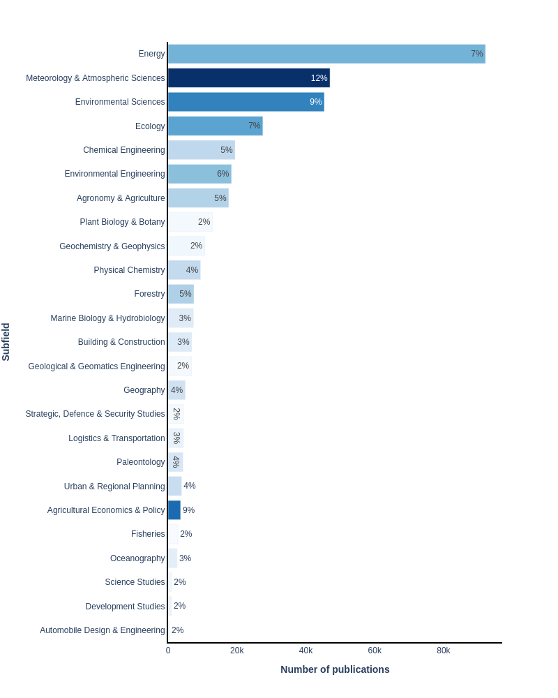

Figure 1. Top 25 subfields with the largest percentage of Scopus publication included in the publication set.

## Journals

In this section, we show how the publication set, captured by the query above, relates to scholarly journals. Journals are sorted in terms of their relevance using term frequency-inverse document frequency (TF-IDF). The horizontal bars are proportional to the number of publications contributed by the journal to the current publication set. The number alongside the horizontal bar is the proportion of the journal contributing to this publication set.

The articles on this topic are published most frequently in the following journals: *Journal of Cleaner Production* (6,893 publications), *Sustainability (Switzerland)* (5,608), and *Energy Procedia* (5,586).

Note, larger journals may not appear in the table below, as their SDG contribution may be relatively small compared to the size of the journal.

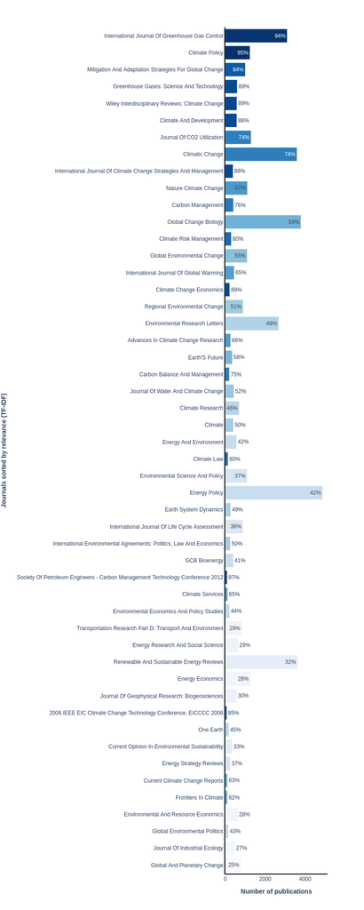

Figure 2. Top 50 journals, in terms of relevance (TF-IDF), for this publication set.

## Keywords

Elsevier’s [Scopus](https://www.scopus.com/search/form.uri?display=basic#basic) database of scientific literature, was used for the table below. The document types included in the data sets are journal articles, reviews, short surveys and conference papers, covering the period 1996–2022. We refer to these documents collectively as “publications” or “papers”.

In order to help better illustrate the content of this set of publications, indicators associated with the keywords most specific to this set (according to a TF-IDF score) are presented below.

|  | Term | # of papers with this term in the publication set | # of papers with this term in all of Scopus | Relevance (TF-IDF) | Percentage of Scopus |
| --- | --- | --- | --- | --- | --- |
| 1 | dry reforming of methane | 1701 | 1831 | 18.7646 | 93 |
| 2 | co2 reforming | 1492 | 1601 | 18.7554 | 93 |
| 3 | dry reforming | 3001 | 3230 | 18.7545 | 93 |
| 4 | co 2 capture | 1454 | 1595 | 18.7118 | 91 |
| 5 | redd+ | 1864 | 2085 | 18.6999 | 89 |
| 6 | post-combustion co2 capture | 1298 | 1442 | 18.6704 | 90 |
| 7 | co2 capture process | 1334 | 1489 | 18.6669 | 90 |
| 8 | carbon dioxide capture | 2973 | 3350 | 18.6666 | 89 |
| 9 | co2 hydrogenation | 2443 | 2786 | 18.662 | 88 |
| 10 | co2-eq | 2413 | 2754 | 18.6612 | 88 |

[output cut: 990 more lines]